# ANOVA test for tipologia_textual

Geiser C. Challco geiser@alumni.usp.br

- ANOVA: tipologia_textual ~ time
  - Data Preparation
  - Summary Statistics
  - ANOVA Computation
  - PairWise Computation
- ANOVA: tipologia_textual ~ time*gender + Error(id/time)
  - Data Preparation
    - Check assumptions: Identifying Outliers
    - Check assumptions: Normality Test
    - Summary Statistics
  - ANOVA Computation
  - ANOVA Computation after removing non.normal data
  - PairWise Computation
  - PairWise Computation after removing non.normal data
- ANOVA: tipologia_textual ~ time*localizacao + Error(id/time)
  - Data Preparation
    - Check assumptions: Identifying Outliers
    - Check assumptions: Normality Test
    - Summary Statistics
  - ANOVA Computation
  - ANOVA Computation after removing non.normal data
  - PairWise Computation
  - PairWise Computation after removing non.normal data
- ANOVA: tipologia_textual ~ time*regiao + Error(id/time)
  - Data Preparation
    - Check assumptions: Identifying Outliers
    - Check assumptions: Normality Test
    - Summary Statistics
  - ANOVA Computation
  - ANOVA Computation after removing non.normal data
  - PairWise Computation
  - PairWise Computation after removing non.normal data
- ANOVA: tipologia_textual ~ time*porte + Error(id/time)
  - Data Preparation
    - Check assumptions: Identifying Outliers
    - Check assumptions: Normality Test
    - Summary Statistics
  - ANOVA Computation
  - ANOVA Computation after removing non.normal data
  - PairWise Computation
  - PairWise Computation after removing non.normal data

```r
dat <- read_excel("../data/data.xlsx", sheet = "alunos_ef14")

escolas <- read_excel("../data/data.xlsx", sheet = "escolas")
edat <- merge(dat, escolas, by = "cod_escola", all.x = T)
```

# ANOVA: tipologia_textual ~ time

## Data Preparation

```r
data <- edat[,c("aluno_id","ciclo","tipologia_textual")]
data <- data[data$ciclo %in% c("Primeiro Ciclo","Segundo Ciclo","Terceiro Ciclo"),]
data$ciclo <- factor(data$ciclo, c("Primeiro Ciclo","Segundo Ciclo","Terceiro Ciclo"))
data <- unique(data)

wdat <- spread(data, ciclo, tipologia_textual)
wdat <- wdat[complete.cases(wdat),]
colnames(wdat) <- c("id","c1","c2","c3")

ldat <- gather(wdat, key = time, value = tipologia_textual, c1,c2,c3) %>%
  convert_as_factor(id, time)
ldat <- rshinystatistics::remove_group_data(ldat, "tipologia_textual", "time", n.limit = 30)
```

## Summary Statistics

```r
(sdat <- ldat %>% group_by(time) %>%
   get_summary_stats(tipologia_textual, type = "mean_sd"))
```

```
## # A tibble: 3 × 5
##   time  variable              n  mean    sd
##   <fct> <fct>             <dbl> <dbl> <dbl>
## 1 c1    tipologia_textual  2773  2.91 0.743
## 2 c2    tipologia_textual  2773  3.18 0.765
## 3 c3    tipologia_textual  2773  3.25 0.752
```

| time | variable | n | mean | sd |
| --- | --- | --- | --- | --- |
| c1 | tipologia_textual | 2773 | 2.914 | 0.743 |
| c2 | tipologia_textual | 2773 | 3.185 | 0.765 |
| c3 | tipologia_textual | 2773 | 3.246 | 0.752 |

## ANOVA Computation

```r
(res.aov <- anova_test(ldat, dv = tipologia_textual, wid = id, within = time))
```

```
## ANOVA Table (type III tests)
##
## $ANOVA
##   Effect DFn  DFd       F                                                                                   p p<.05   ges
## 1   time   2 5544 186.156 0.000000000000000000000000000000000000000000000000000000000000000000000000000000566     * 0.035
##
## $`Mauchly's Test for Sphericity`
##   Effect     W     p p<.05
## 1   time 0.999 0.125
##
## $`Sphericity Corrections`
##   Effect   GGe     DF[GG]                                                                               p[GG] p[GG]<.05   HFe
## 1   time 0.999 2, 5535.71 0.000000000000000000000000000000000000000000000000000000000000000000000000000000734         * 0.999
##      DF[HF]                                                                               p[HF] p[HF]<.05
## 1 2, 5539.7 0.000000000000000000000000000000000000000000000000000000000000000000000000000000647         *
```

| Effect | DFn | DFd | F | p | p<.05 | ges |
| --- | --- | --- | --- | --- | --- | --- |
| time | 2 | 5544 | 186.156 | 0 | * | 0.035 |

| Effect | W | p | p<.05 |
| --- | --- | --- | --- |
| time | 0.999 | 0.125 |  |

| Effect | GGe | DF[GG] | p[GG] | p[GG]<.05 | HFe | DF[HF] | p[HF] | p[HF]<.05 |
| --- | --- | --- | --- | --- | --- | --- | --- | --- |
| time | 0.999 | 2, 5535.71 | 0 | * | 0.999 | 2, 5539.7 | 0 | * |

## PairWise Computation

```r
(pwc <- ldat %>% emmeans_test(tipologia_textual ~ time, detailed = T, p.adjust.method = "bonferroni"))
```

```
## # A tibble: 3 × 14
##   term  .y.           group1 group2 null.value estimate     se    df conf.low conf.high statistic        p    p.adj p.adj.signif
## * <chr> <chr>         <chr>  <chr>       <dbl>    <dbl>  <dbl> <dbl>    <dbl>     <dbl>     <dbl>    <dbl>    <dbl> <chr>
## 1 time  tipologia_te… c1     c2              0  -0.271  0.0202  8316   -0.311   -0.231     -13.4  1.70e-40 5.09e-40 ****
## 2 time  tipologia_te… c1     c3              0  -0.332  0.0202  8316   -0.372   -0.292     -16.4  1.75e-59 5.26e-59 ****
## 3 time  tipologia_te… c2     c3              0  -0.0607 0.0202  8316   -0.100   -0.0211     -3.00 2.70e- 3 8.11e- 3 **
```

| term | .y. | group1 | group2 | null.value | estimate | se | df | conf.low | conf.high | statistic | p | p.adj | p.adj.signif |
| --- | --- | --- | --- | --- | --- | --- | --- | --- | --- | --- | --- | --- | --- |
| time | tipologia_textual | c1 | c2 | 0 | -0.271 | 0.02 | 8316 | -0.311 | -0.231 | -13.395 | 0.000 | 0.000 | **** |
| time | tipologia_textual | c1 | c3 | 0 | -0.332 | 0.02 | 8316 | -0.372 | -0.292 | -16.396 | 0.000 | 0.000 | **** |
| time | tipologia_textual | c2 | c3 | 0 | -0.061 | 0.02 | 8316 | -0.100 | -0.021 | -3.001 | 0.003 | 0.008 | ** |

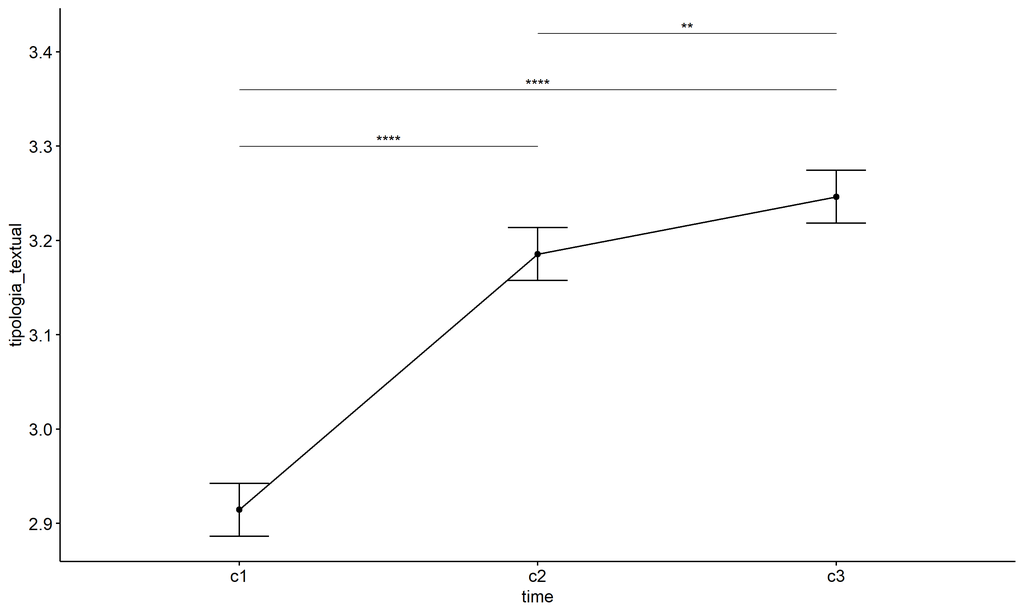

```r
pwc <- add_xy_position(pwc, x = "time", fun = "mean_se")
ggline(get_emmeans(pwc), x = "time", y = "emmean", ylab = "tipologia_textual") +
  geom_errorbar(aes(ymin = conf.low, ymax = conf.high), width = 0.2) +
  stat_pvalue_manual(pwc, hide.ns = T, tip.length = F)
```

# ANOVA: tipologia_textual ~ time*gender + Error(id/time)

## Data Preparation

```r
data <- edat[,c("aluno_id","gender","ciclo","tipologia_textual")]
data <- data[data$ciclo %in% c("Primeiro Ciclo","Segundo Ciclo","Terceiro Ciclo"),]
data$ciclo <- factor(data$ciclo, c("Primeiro Ciclo","Segundo Ciclo","Terceiro Ciclo"))
data <- unique(data)

wdat <- spread(data, ciclo, tipologia_textual)
wdat <- wdat[complete.cases(wdat),]
colnames(wdat) <- c("id","gender","c1","c2","c3")

ldat <- gather(wdat, key = time, value = tipologia_textual, c1,c2,c3) %>%
  convert_as_factor(id, time)
ldat <- remove_group_data(ldat, "tipologia_textual", c("time", "gender"), n.limit = 30)
ldat$gender <- factor(ldat$gender, sort(unique(ldat$gender)))
```

### Check assumptions: Identifying Outliers

```r
outliers <- identify_outliers(group_by(ldat, time, gender), tipologia_textual)
(outliers <- outliers[outliers$is.extreme == T,])
```

```
## [1] gender            time              id                tipologia_textual is.outlier        is.extreme
## <0 rows> (or 0-length row.names)
```

| gender | time | id | tipologia_textual | is.outlier | is.extreme |
| --- | --- | --- | --- | --- | --- |

### Check assumptions: Normality Test

```r
(normality.df <- normality.test.per.groups(ldat, "tipologia_textual", c("time", "gender")))
```

```
##                 var          variable time gender    n    skewness  kurtosis symmetry  statistic     method p p.signif
## 1 tipologia_textual tipologia_textual   c1 Female 1363  0.03722716 -1.294172      YES  2894.1266 D'Agostino 0     ****
## 2 tipologia_textual tipologia_textual   c1   Male 1240  0.18759017 -1.339654      YES  7370.2365 D'Agostino 0     ****
## 3 tipologia_textual tipologia_textual   c2 Female 1363 -0.38883577 -1.238402      YES  1482.5575 D'Agostino 0     ****
## 4 tipologia_textual tipologia_textual   c2   Male 1240 -0.27214861 -1.356037      YES 21523.6394 D'Agostino 0     ****
## 5 tipologia_textual tipologia_textual   c3 Female 1363 -0.49951855 -1.128049      YES   660.9117 D'Agostino 0     ****
## 6 tipologia_textual tipologia_textual   c3   Male 1240 -0.41347133 -1.198862      YES   944.5909 D'Agostino 0     ****
##   normality
## 1         -
## 2         -
## 3         -
## 4         -
## 5         -
## 6         -
```

| var | variable | time | gender | n | skewness | kurtosis | symmetry | statistic | method | p | p.signif | normality |
| --- | --- | --- | --- | --- | --- | --- | --- | --- | --- | --- | --- | --- |
| tipologia_textual | tipologia_textual | c1 | Female | 1363 | 0.037 | -1.294 | YES | 2894.127 | D’Agostino | 0 | **** | - |
| tipologia_textual | tipologia_textual | c1 | Male | 1240 | 0.188 | -1.340 | YES | 7370.236 | D’Agostino | 0 | **** | - |
| tipologia_textual | tipologia_textual | c2 | Female | 1363 | -0.389 | -1.238 | YES | 1482.558 | D’Agostino | 0 | **** | - |
| tipologia_textual | tipologia_textual | c2 | Male | 1240 | -0.272 | -1.356 | YES | 21523.639 | D’Agostino | 0 | **** | - |
| tipologia_textual | tipologia_textual | c3 | Female | 1363 | -0.500 | -1.128 | YES | 660.912 | D’Agostino | 0 | **** | - |
| tipologia_textual | tipologia_textual | c3 | Male | 1240 | -0.413 | -1.199 | YES | 944.591 | D’Agostino | 0 | **** | - |

```r
(non.ids <- unique(do.call(
  c, lapply(which(normality.df$normality == 'NO'), FUN = function(i) {
  idx = which(ldat$time == normality.df$time[i] &
                ldat$gender == normality.df$gender[i])
  getNonNormal(ldat$"tipologia_textual"[idx], ldat$id[idx])
}))))
```

```r
if (length(non.ids) > 0)
  ldat2 <- ldat[!ldat$id %in% non.ids,]
```

### Summary Statistics

```r
(sdat <- ldat %>% group_by(time, gender) %>%
   get_summary_stats(tipologia_textual, type = "mean_sd"))
```

```
## # A tibble: 6 × 6
##   gender time  variable              n  mean    sd
##   <fct>  <fct> <fct>             <dbl> <dbl> <dbl>
## 1 Female c1    tipologia_textual  1363  2.95 0.733
## 2 Male   c1    tipologia_textual  1240  2.88 0.753
## 3 Female c2    tipologia_textual  1363  3.21 0.757
## 4 Male   c2    tipologia_textual  1240  3.15 0.774
## 5 Female c3    tipologia_textual  1363  3.27 0.747
## 6 Male   c3    tipologia_textual  1240  3.22 0.751
```

| gender | time | variable | n | mean | sd |
| --- | --- | --- | --- | --- | --- |
| Female | c1 | tipologia_textual | 1363 | 2.949 | 0.733 |
| Male | c1 | tipologia_textual | 1240 | 2.880 | 0.753 |
| Female | c2 | tipologia_textual | 1363 | 3.212 | 0.757 |
| Male | c2 | tipologia_textual | 1240 | 3.146 | 0.774 |
| Female | c3 | tipologia_textual | 1363 | 3.268 | 0.747 |
| Male | c3 | tipologia_textual | 1240 | 3.218 | 0.751 |

```r
if (length(non.ids) > 0)
  (sdat <- ldat2 %>% group_by(time, gender) %>%
      get_summary_stats(tipologia_textual, type = "mean_sd"))
```

| gender | time | variable | n | mean | sd |
| --- | --- | --- | --- | --- | --- |
| Female | c1 | tipologia_textual | 1363 | 2.949 | 0.733 |
| Male | c1 | tipologia_textual | 1240 | 2.880 | 0.753 |
| Female | c2 | tipologia_textual | 1363 | 3.212 | 0.757 |
| Male | c2 | tipologia_textual | 1240 | 3.146 | 0.774 |
| Female | c3 | tipologia_textual | 1363 | 3.268 | 0.747 |
| Male | c3 | tipologia_textual | 1240 | 3.218 | 0.751 |

## ANOVA Computation

```r
(res.aov <- anova_test(ldat, dv = tipologia_textual, wid = id, between = gender, within = time))
```

```
## ANOVA Table (type III tests)
##
## $ANOVA
##        Effect DFn  DFd       F                                                                            p p<.05       ges
## 1      gender   1 2601   9.706 0.00200000000000000004163336342344337026588618755340576171875000000000000000     * 0.0020000
## 2        time   2 5202 169.300 0.00000000000000000000000000000000000000000000000000000000000000000000000586     * 0.0340000
## 3 gender:time   2 5202   0.139 0.86999999999999999555910790149937383830547332763671875000000000000000000000       0.0000293
##
## $`Mauchly's Test for Sphericity`
##        Effect     W     p p<.05
## 1        time 0.998 0.064
## 2 gender:time 0.998 0.064
##
## $`Sphericity Corrections`
##        Effect   GGe     DF[GG]                                                                        p[GG] p[GG]<.05   HFe
## 1        time 0.998 2, 5191.03 0.00000000000000000000000000000000000000000000000000000000000000000000000818         * 0.999
## 2 gender:time 0.998 2, 5191.03 0.86999999999999999555910790149937383830547332763671875000000000000000000000           0.999
##       DF[HF]                                                                        p[HF] p[HF]<.05
## 1 2, 5195.01 0.00000000000000000000000000000000000000000000000000000000000000000000000725         *
## 2 2, 5195.01 0.86999999999999999555910790149937383830547332763671875000000000000000000000
```

| Effect | DFn | DFd | F | p | p<.05 | ges |
| --- | --- | --- | --- | --- | --- | --- |
| gender | 1 | 2601 | 9.706 | 0.002 | * | 0.002 |
| time | 2 | 5202 | 169.300 | 0.000 | * | 0.034 |
| gender:time | 2 | 5202 | 0.139 | 0.870 |  | 0.000 |

| Effect | W | p | p<.05 |
| --- | --- | --- | --- |
| time | 0.998 | 0.064 |  |
| gender:time | 0.998 | 0.064 |  |

| Effect | GGe | DF[GG] | p[GG] | p[GG]<.05 | HFe | DF[HF] | p[HF] | p[HF]<.05 |
| --- | --- | --- | --- | --- | --- | --- | --- | --- |
| time | 0.998 | 2, 5191.03 | 0.00 | * | 0.999 | 2, 5195.01 | 0.00 | * |
| gender:time | 0.998 | 2, 5191.03 | 0.87 |  | 0.999 | 2, 5195.01 | 0.87 |  |

## ANOVA Computation after removing non.normal data

```r
if (length(non.ids) > 0)
  (res.aov2 <- anova_test(ldat2, dv = tipologia_textual, wid = id, between = gender , within = time))
```

## PairWise Computation

```r
(pwc <- ldat %>% group_by(time) %>%
   emmeans_test(tipologia_textual ~ gender, detailed = T, p.adjust.method = "bonferroni"))
```

```
## # A tibble: 3 × 15
##   time  term   .y.        group1 group2 null.value estimate     se    df conf.low conf.high statistic      p  p.adj p.adj.signif
## * <fct> <chr>  <chr>      <chr>  <chr>       <dbl>    <dbl>  <dbl> <dbl>    <dbl>     <dbl>     <dbl>  <dbl>  <dbl> <chr>
## 1 c1    gender tipologia… Female Male            0   0.0693 0.0295  7803  0.0115      0.127      2.35 0.0189 0.0189 *
## 2 c2    gender tipologia… Female Male            0   0.0658 0.0295  7803  0.00789     0.124      2.23 0.0260 0.0260 *
## 3 c3    gender tipologia… Female Male            0   0.0505 0.0295  7803 -0.00733     0.108      1.71 0.0869 0.0869 ns
```

| time | term | .y. | group1 | group2 | null.value | estimate | se | df | conf.low | conf.high | statistic | p | p.adj | p.adj.signif |
| --- | --- | --- | --- | --- | --- | --- | --- | --- | --- | --- | --- | --- | --- | --- |
| c1 | gender | tipologia_textual | Female | Male | 0 | 0.069 | 0.03 | 7803 | 0.011 | 0.127 | 2.349 | 0.019 | 0.019 | * |
| c2 | gender | tipologia_textual | Female | Male | 0 | 0.066 | 0.03 | 7803 | 0.008 | 0.124 | 2.227 | 0.026 | 0.026 | * |
| c3 | gender | tipologia_textual | Female | Male | 0 | 0.051 | 0.03 | 7803 | -0.007 | 0.108 | 1.712 | 0.087 | 0.087 | ns |

```r
(emms <- get_emmeans(pwc))
```

```
## # A tibble: 6 × 8
##   time  gender emmean     se    df conf.low conf.high method
##   <fct> <fct>   <dbl>  <dbl> <dbl>    <dbl>     <dbl> <chr>
## 1 c1    Female   2.95 0.0204  7803     2.91      2.99 Emmeans test
## 2 c1    Male     2.88 0.0214  7803     2.84      2.92 Emmeans test
## 3 c2    Female   3.21 0.0204  7803     3.17      3.25 Emmeans test
## 4 c2    Male     3.15 0.0214  7803     3.10      3.19 Emmeans test
## 5 c3    Female   3.27 0.0204  7803     3.23      3.31 Emmeans test
## 6 c3    Male     3.22 0.0214  7803     3.18      3.26 Emmeans test
```

| time | gender | emmean | se | df | conf.low | conf.high | method |
| --- | --- | --- | --- | --- | --- | --- | --- |
| c1 | Female | 2.949 | 0.020 | 7803 | 2.909 | 2.989 | Emmeans test |
| c1 | Male | 2.880 | 0.021 | 7803 | 2.838 | 2.922 | Emmeans test |
| c2 | Female | 3.212 | 0.020 | 7803 | 3.172 | 3.252 | Emmeans test |
| c2 | Male | 3.146 | 0.021 | 7803 | 3.104 | 3.188 | Emmeans test |
| c3 | Female | 3.268 | 0.020 | 7803 | 3.228 | 3.308 | Emmeans test |
| c3 | Male | 3.218 | 0.021 | 7803 | 3.176 | 3.260 | Emmeans test |

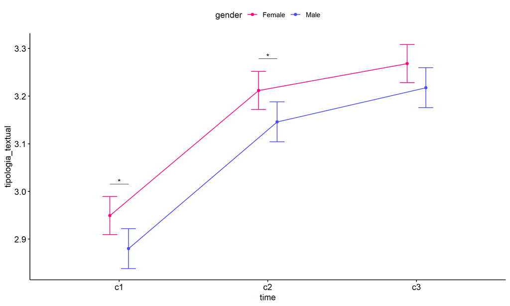

```r
pwc <- add_xy_position(pwc, x = "time", fun = "mean_se", dodge = 0.25)
pd <- position_dodge(width = 0.25)
ggline(emms, x = "time", y = "emmean", color = "gender",
       palette = c("#FF007F","#4D4DFF"),
       position = pd, ylab = "tipologia_textual") +
  geom_errorbar(aes(ymin = conf.low, ymax = conf.high, color = gender),
                position = pd, width = 0.2) +
  stat_pvalue_manual(pwc, hide.ns = T, tip.length = F, linetype = 1)
```

```r
(pwc <- ldat %>% group_by(gender) %>%
    emmeans_test(tipologia_textual ~ time, detailed = T, p.adjust.method = "bonferroni"))
```

```
## # A tibble: 6 × 15
##   gender term  .y.    group1 group2 null.value estimate     se    df conf.low conf.high statistic        p    p.adj p.adj.signif
## * <fct>  <chr> <chr>  <chr>  <chr>       <dbl>    <dbl>  <dbl> <dbl>    <dbl>     <dbl>     <dbl>    <dbl>    <dbl> <chr>
## 1 Female time  tipol… c1     c2              0  -0.262  0.0288  7803   -0.319  -2.06e-1     -9.11 1.06e-19 3.18e-19 ****
## 2 Female time  tipol… c1     c3              0  -0.319  0.0288  7803   -0.375  -2.62e-1    -11.1  2.92e-28 8.77e-28 ****
## 3 Female time  tipol… c2     c3              0  -0.0565 0.0288  7803   -0.113  -9.25e-6     -1.96 5.00e- 2 1.50e- 1 ns
## 4 Male   time  tipol… c1     c2              0  -0.266  0.0302  7803   -0.325  -2.07e-1     -8.80 1.59e-18 4.78e-18 ****
## 5 Male   time  tipol… c1     c3              0  -0.338  0.0302  7803   -0.397  -2.78e-1    -11.2  8.58e-29 2.57e-28 ****
## 6 Male   time  tipol… c2     c3              0  -0.0717 0.0302  7803   -0.131  -1.25e-2     -2.37 1.76e- 2 5.29e- 2 ns
```

| gender | term | .y. | group1 | group2 | null.value | estimate | se | df | conf.low | conf.high | statistic | p | p.adj | p.adj.signif |
| --- | --- | --- | --- | --- | --- | --- | --- | --- | --- | --- | --- | --- | --- | --- |
| Female | time | tipologia_textual | c1 | c2 | 0 | -0.262 | 0.029 | 7803 | -0.319 | -0.206 | -9.107 | 0.000 | 0.000 | **** |
| Female | time | tipologia_textual | c1 | c3 | 0 | -0.319 | 0.029 | 7803 | -0.375 | -0.262 | -11.068 | 0.000 | 0.000 | **** |
| Female | time | tipologia_textual | c2 | c3 | 0 | -0.056 | 0.029 | 7803 | -0.113 | 0.000 | -1.961 | 0.050 | 0.150 | ns |
| Male | time | tipologia_textual | c1 | c2 | 0 | -0.266 | 0.030 | 7803 | -0.325 | -0.207 | -8.805 | 0.000 | 0.000 | **** |
| Male | time | tipologia_textual | c1 | c3 | 0 | -0.338 | 0.030 | 7803 | -0.397 | -0.278 | -11.179 | 0.000 | 0.000 | **** |
| Male | time | tipologia_textual | c2 | c3 | 0 | -0.072 | 0.030 | 7803 | -0.131 | -0.012 | -2.374 | 0.018 | 0.053 | ns |

```r
(emms <- get_emmeans(pwc))
```

```
## # A tibble: 6 × 8
##   gender time  emmean     se    df conf.low conf.high method
##   <fct>  <fct>  <dbl>  <dbl> <dbl>    <dbl>     <dbl> <chr>
## 1 Female c1      2.95 0.0204  7803     2.91      2.99 Emmeans test
## 2 Female c2      3.21 0.0204  7803     3.17      3.25 Emmeans test
## 3 Female c3      3.27 0.0204  7803     3.23      3.31 Emmeans test
## 4 Male   c1      2.88 0.0214  7803     2.84      2.92 Emmeans test
## 5 Male   c2      3.15 0.0214  7803     3.10      3.19 Emmeans test
## 6 Male   c3      3.22 0.0214  7803     3.18      3.26 Emmeans test
```

| gender | time | emmean | se | df | conf.low | conf.high | method |
| --- | --- | --- | --- | --- | --- | --- | --- |
| Female | c1 | 2.949 | 0.020 | 7803 | 2.909 | 2.989 | Emmeans test |
| Female | c2 | 3.212 | 0.020 | 7803 | 3.172 | 3.252 | Emmeans test |
| Female | c3 | 3.268 | 0.020 | 7803 | 3.228 | 3.308 | Emmeans test |
| Male | c1 | 2.880 | 0.021 | 7803 | 2.838 | 2.922 | Emmeans test |
| Male | c2 | 3.146 | 0.021 | 7803 | 3.104 | 3.188 | Emmeans test |
| Male | c3 | 3.218 | 0.021 | 7803 | 3.176 | 3.260 | Emmeans test |

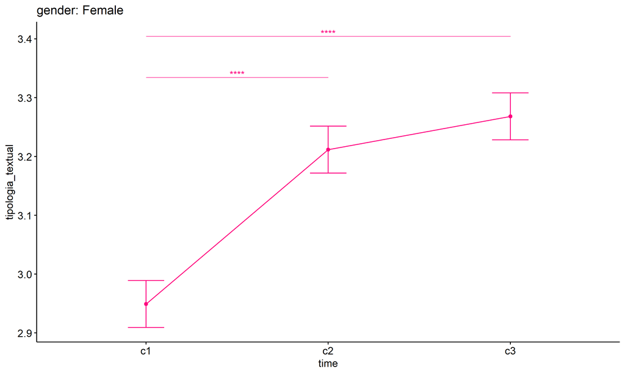

```r
emms.gg <- emms[which(emms$gender == "Female"),]
if (nrow(emms.gg) > 0)
  ggline(emms.gg, x = "time", y = "emmean", color = "#FF007F", ylab = "tipologia_textual") +
    geom_errorbar(aes(ymin = conf.low, ymax = conf.high),
                  width = 0.2, color = "#FF007F") +
    stat_pvalue_manual(
      add_xy_position(pwc[which(pwc$gender == "Female"),],
                      x = "time", fun = "mean_se"),
      hide.ns = T, color = "#FF007F", tip.length = F) +
    labs(title = "gender: Female")+
    theme(legend.text = element_blank())
```

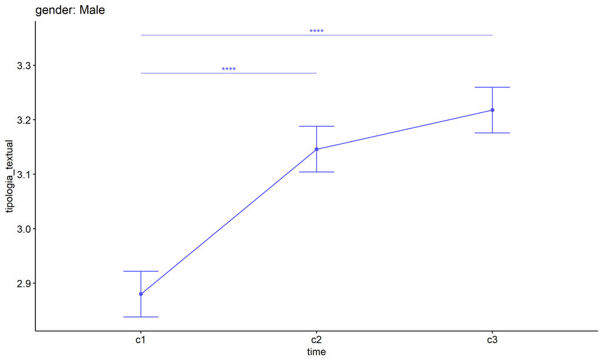

```r
emms.gg <- emms[which(emms$gender == "Male"),]
if (nrow(emms.gg) > 0)
  ggline(emms.gg, x = "time", y = "emmean", color = "#4D4DFF", ylab = "tipologia_textual") +
    geom_errorbar(aes(ymin = conf.low, ymax = conf.high),
                  width = 0.2, color = "#4D4DFF") +
    stat_pvalue_manual(
      add_xy_position(pwc[which(pwc$gender == "Male"),],
                      x = "time", fun = "mean_se"),
      hide.ns = T, color = "#4D4DFF", tip.length = F) +
    labs(title = "gender: Male")+
    theme(legend.text = element_blank())
```

## PairWise Computation after removing non.normal data

```r
if (length(non.ids) > 0)
  (pwc2 <- ldat2 %>% group_by(time) %>%
     emmeans_test(tipologia_textual ~ gender, detailed = T, p.adjust.method = "bonferroni"))
```

```r
if (length(non.ids) > 0)
  (emms2 <- get_emmeans(pwc2))
```

```r
if (length(non.ids) > 0) {
  pwc2 <- add_xy_position(pwc2, x = "time", fun = "mean_se", dodge = 0.25)
  pd2 <- position_dodge(width = 0.25)

  ggline(emms2, x = "time", y = "emmean", color = "gender",
         palette = c("#FF007F","#4D4DFF"),
         position = pd, ylab = "tipologia_textual") +
    geom_errorbar(aes(ymin = conf.low, ymax = conf.high, color = gender),
                position = pd, width = 0.2) +
    stat_pvalue_manual(pwc2, hide.ns = T, tip.length = F, linetype = 1)
}
```

```r
if (length(non.ids) > 0)
  (pwc2 <- ldat2 %>% group_by(gender) %>%
     emmeans_test(tipologia_textual ~ time, detailed = T, p.adjust.method = "bonferroni"))
```

```r
if (length(non.ids) > 0)
  (emms2 <- get_emmeans(pwc2))
```

```r
if (length(non.ids) > 0) {
  emms.gg <- emms2[which(emms2$gender == "Female"),]
  if (nrow(emms.gg) > 0)
    ggline(emms.gg, x = "time", y = "emmean", color = "#FF007F", ylab = "tipologia_textual") +
    geom_errorbar(aes(ymin = conf.low, ymax = conf.high),
                  width = 0.2, color = "#FF007F") +
    stat_pvalue_manual(
      add_xy_position(pwc[which(pwc$gender == "Female"),],
                      x = "time", fun = "mean_se"),
      hide.ns = T, color = "#FF007F", tip.length = F) +
    labs(title = "gender: Female") +
    theme(legend.text = element_blank())
}
```

```r
if (length(non.ids) > 0) {
  emms.gg <- emms2[which(emms2$gender == "Male"),]
  if (nrow(emms.gg) > 0)
    ggline(emms.gg, x = "time", y = "emmean", color = "#4D4DFF", ylab = "tipologia_textual") +
    geom_errorbar(aes(ymin = conf.low, ymax = conf.high),
                  width = 0.2, color = "#4D4DFF") +
    stat_pvalue_manual(
      add_xy_position(pwc[which(pwc$gender == "Male"),],
                      x = "time", fun = "mean_se"),
      hide.ns = T, color = "#4D4DFF", tip.length = F) +
    labs(title = "gender: Male") +
    theme(legend.text = element_blank())
}
```

# ANOVA: tipologia_textual ~ time*localizacao + Error(id/time)

## Data Preparation

```r
data <- edat[,c("aluno_id","localizacao","ciclo","tipologia_textual")]
data <- data[data$ciclo %in% c("Primeiro Ciclo","Segundo Ciclo","Terceiro Ciclo"),]
data$ciclo <- factor(data$ciclo, c("Primeiro Ciclo","Segundo Ciclo","Terceiro Ciclo"))
data <- unique(data)

wdat <- spread(data, ciclo, tipologia_textual)
wdat <- wdat[complete.cases(wdat),]
colnames(wdat) <- c("id","localizacao","c1","c2","c3")

ldat <- gather(wdat, key = time, value = tipologia_textual, c1,c2,c3) %>%
  convert_as_factor(id, time)
ldat <- remove_group_data(ldat, "tipologia_textual", c("time", "localizacao"), n.limit = 30)
ldat$localizacao <- factor(ldat$localizacao, sort(unique(ldat$localizacao)))
```

### Check assumptions: Identifying Outliers

```r
outliers <- identify_outliers(group_by(ldat, time, localizacao), tipologia_textual)
(outliers <- outliers[outliers$is.extreme == T,])
```

```
## [1] localizacao       time              id                tipologia_textual is.outlier        is.extreme
## <0 rows> (or 0-length row.names)
```

| localizacao | time | id | tipologia_textual | is.outlier | is.extreme |
| --- | --- | --- | --- | --- | --- |

### Check assumptions: Normality Test

```r
(normality.df <- normality.test.per.groups(ldat, "tipologia_textual", c("time", "localizacao")))
```

```
##                 var          variable time localizacao    n   skewness  kurtosis symmetry statistic     method p p.signif
## 1 tipologia_textual tipologia_textual   c1       Rural  656  0.1594127 -1.355597      YES 3029.9638 D'Agostino 0     ****
## 2 tipologia_textual tipologia_textual   c1      Urbana 2117  0.1002486 -1.309750      YES 7114.8748 D'Agostino 0     ****
## 3 tipologia_textual tipologia_textual   c2       Rural  656 -0.3351117 -1.311296      YES 1280.1661 D'Agostino 0     ****
## 4 tipologia_textual tipologia_textual   c2      Urbana 2117 -0.3466755 -1.285269      YES 4466.8174 D'Agostino 0     ****
## 5 tipologia_textual tipologia_textual   c3       Rural  656 -0.5301739 -1.114652       NO  271.8768 D'Agostino 0     ****
## 6 tipologia_textual tipologia_textual   c3      Urbana 2117 -0.4450274 -1.185923      YES 1562.9573 D'Agostino 0     ****
##   normality
## 1         -
## 2         -
## 3         -
## 4         -
## 5         -
## 6         -
```

| var | variable | time | localizacao | n | skewness | kurtosis | symmetry | statistic | method | p | p.signif | normality |
| --- | --- | --- | --- | --- | --- | --- | --- | --- | --- | --- | --- | --- |
| tipologia_textual | tipologia_textual | c1 | Rural | 656 | 0.159 | -1.356 | YES | 3029.964 | D’Agostino | 0 | **** | - |
| tipologia_textual | tipologia_textual | c1 | Urbana | 2117 | 0.100 | -1.310 | YES | 7114.875 | D’Agostino | 0 | **** | - |
| tipologia_textual | tipologia_textual | c2 | Rural | 656 | -0.335 | -1.311 | YES | 1280.166 | D’Agostino | 0 | **** | - |
| tipologia_textual | tipologia_textual | c2 | Urbana | 2117 | -0.347 | -1.285 | YES | 4466.817 | D’Agostino | 0 | **** | - |
| tipologia_textual | tipologia_textual | c3 | Rural | 656 | -0.530 | -1.115 | NO | 271.877 | D’Agostino | 0 | **** | - |
| tipologia_textual | tipologia_textual | c3 | Urbana | 2117 | -0.445 | -1.186 | YES | 1562.957 | D’Agostino | 0 | **** | - |

```r
(non.ids <- unique(do.call(
  c, lapply(which(normality.df$normality == 'NO'), FUN = function(i) {
  idx = which(ldat$time == normality.df$time[i] &
                ldat$localizacao == normality.df$localizacao[i])
  getNonNormal(ldat$"tipologia_textual"[idx], ldat$id[idx])
}))))
```

```r
if (length(non.ids) > 0)
  ldat2 <- ldat[!ldat$id %in% non.ids,]
```

### Summary Statistics

```r
(sdat <- ldat %>% group_by(time, localizacao) %>%
   get_summary_stats(tipologia_textual, type = "mean_sd"))
```

```
## # A tibble: 6 × 6
##   localizacao time  variable              n  mean    sd
##   <fct>       <fct> <fct>             <dbl> <dbl> <dbl>
## 1 Rural       c1    tipologia_textual   656  2.89 0.749
## 2 Urbana      c1    tipologia_textual  2117  2.92 0.742
## 3 Rural       c2    tipologia_textual   656  3.19 0.769
## 4 Urbana      c2    tipologia_textual  2117  3.18 0.764
## 5 Rural       c3    tipologia_textual   656  3.28 0.748
## 6 Urbana      c3    tipologia_textual  2117  3.24 0.753
```

| localizacao | time | variable | n | mean | sd |
| --- | --- | --- | --- | --- | --- |
| Rural | c1 | tipologia_textual | 656 | 2.893 | 0.749 |
| Urbana | c1 | tipologia_textual | 2117 | 2.921 | 0.742 |
| Rural | c2 | tipologia_textual | 656 | 3.188 | 0.769 |
| Urbana | c2 | tipologia_textual | 2117 | 3.185 | 0.764 |
| Rural | c3 | tipologia_textual | 656 | 3.279 | 0.748 |
| Urbana | c3 | tipologia_textual | 2117 | 3.236 | 0.753 |

```r
if (length(non.ids) > 0)
  (sdat <- ldat2 %>% group_by(time, localizacao) %>%
      get_summary_stats(tipologia_textual, type = "mean_sd"))
```

| localizacao | time | variable | n | mean | sd |
| --- | --- | --- | --- | --- | --- |
| Rural | c1 | tipologia_textual | 656 | 2.893 | 0.749 |
| Urbana | c1 | tipologia_textual | 2117 | 2.921 | 0.742 |
| Rural | c2 | tipologia_textual | 656 | 3.188 | 0.769 |
| Urbana | c2 | tipologia_textual | 2117 | 3.185 | 0.764 |
| Rural | c3 | tipologia_textual | 656 | 3.279 | 0.748 |
| Urbana | c3 | tipologia_textual | 2117 | 3.236 | 0.753 |

## ANOVA Computation

```r
(res.aov <- anova_test(ldat, dv = tipologia_textual, wid = id, between = localizacao, within = time))
```

```
## ANOVA Table (type III tests)
##
## $ANOVA
##             Effect DFn  DFd       F                                                                   p p<.05       ges
## 1      localizacao   1 2771   0.063 0.80200000000000004618527782440651208162307739257812500000000000000       0.0000103
## 2             time   2 5542 147.985 0.00000000000000000000000000000000000000000000000000000000000000244     * 0.0280000
## 3 localizacao:time   2 5542   1.383 0.25100000000000000088817841970012523233890533447265625000000000000       0.0002720
##
## $`Mauchly's Test for Sphericity`
##             Effect     W     p p<.05
## 1             time 0.999 0.129
## 2 localizacao:time 0.999 0.129
##
## $`Sphericity Corrections`
##             Effect   GGe     DF[GG]                                                             p[GG] p[GG]<.05   HFe
## 1             time 0.999 2, 5533.82 0.000000000000000000000000000000000000000000000000000000000000003         * 0.999
## 2 localizacao:time 0.999 2, 5533.82 0.251000000000000000888178419700125232338905334472656250000000000           0.999
##       DF[HF]                                                               p[HF] p[HF]<.05
## 1 2, 5537.81 0.00000000000000000000000000000000000000000000000000000000000000271         *
## 2 2, 5537.81 0.25100000000000000088817841970012523233890533447265625000000000000
```

| Effect | DFn | DFd | F | p | p<.05 | ges |
| --- | --- | --- | --- | --- | --- | --- |
| localizacao | 1 | 2771 | 0.063 | 0.802 |  | 0.000 |
| time | 2 | 5542 | 147.985 | 0.000 | * | 0.028 |
| localizacao:time | 2 | 5542 | 1.383 | 0.251 |  | 0.000 |

| Effect | W | p | p<.05 |
| --- | --- | --- | --- |
| time | 0.999 | 0.129 |  |
| localizacao:time | 0.999 | 0.129 |  |

| Effect | GGe | DF[GG] | p[GG] | p[GG]<.05 | HFe | DF[HF] | p[HF] | p[HF]<.05 |
| --- | --- | --- | --- | --- | --- | --- | --- | --- |
| time | 0.999 | 2, 5533.82 | 0.000 | * | 0.999 | 2, 5537.81 | 0.000 | * |
| localizacao:time | 0.999 | 2, 5533.82 | 0.251 |  | 0.999 | 2, 5537.81 | 0.251 |  |

## ANOVA Computation after removing non.normal data

```r
if (length(non.ids) > 0)
  (res.aov2 <- anova_test(ldat2, dv = tipologia_textual, wid = id, between = localizacao , within = time))
```

## PairWise Computation

```r
(pwc <- ldat %>% group_by(time) %>%
   emmeans_test(tipologia_textual ~ localizacao, detailed = T, p.adjust.method = "bonferroni"))
```

```
## # A tibble: 3 × 15
##   time  term        .y.     group1 group2 null.value estimate     se    df conf.low conf.high statistic     p p.adj p.adj.signif
## * <fct> <chr>       <chr>   <chr>  <chr>       <dbl>    <dbl>  <dbl> <dbl>    <dbl>     <dbl>     <dbl> <dbl> <dbl> <chr>
## 1 c1    localizacao tipolo… Rural  Urbana          0 -0.0285  0.0337  8313  -0.0946    0.0375   -0.848  0.397 0.397 ns
## 2 c2    localizacao tipolo… Rural  Urbana          0  0.00269 0.0337  8313  -0.0633    0.0687    0.0798 0.936 0.936 ns
## 3 c3    localizacao tipolo… Rural  Urbana          0  0.0429  0.0337  8313  -0.0231    0.109     1.27   0.202 0.202 ns
```

| time | term | .y. | group1 | group2 | null.value | estimate | se | df | conf.low | conf.high | statistic | p | p.adj | p.adj.signif |
| --- | --- | --- | --- | --- | --- | --- | --- | --- | --- | --- | --- | --- | --- | --- |
| c1 | localizacao | tipologia_textual | Rural | Urbana | 0 | -0.029 | 0.034 | 8313 | -0.095 | 0.037 | -0.848 | 0.397 | 0.397 | ns |
| c2 | localizacao | tipologia_textual | Rural | Urbana | 0 | 0.003 | 0.034 | 8313 | -0.063 | 0.069 | 0.080 | 0.936 | 0.936 | ns |
| c3 | localizacao | tipologia_textual | Rural | Urbana | 0 | 0.043 | 0.034 | 8313 | -0.023 | 0.109 | 1.275 | 0.202 | 0.202 | ns |

```r
(emms <- get_emmeans(pwc))
```

```
## # A tibble: 6 × 8
##   time  localizacao emmean     se    df conf.low conf.high method
##   <fct> <fct>        <dbl>  <dbl> <dbl>    <dbl>     <dbl> <chr>
## 1 c1    Rural         2.89 0.0294  8313     2.83      2.95 Emmeans test
## 2 c1    Urbana        2.92 0.0164  8313     2.89      2.95 Emmeans test
## 3 c2    Rural         3.19 0.0294  8313     3.13      3.25 Emmeans test
## 4 c2    Urbana        3.18 0.0164  8313     3.15      3.22 Emmeans test
## 5 c3    Rural         3.28 0.0294  8313     3.22      3.34 Emmeans test
## 6 c3    Urbana        3.24 0.0164  8313     3.20      3.27 Emmeans test
```

| time | localizacao | emmean | se | df | conf.low | conf.high | method |
| --- | --- | --- | --- | --- | --- | --- | --- |
| c1 | Rural | 2.893 | 0.029 | 8313 | 2.835 | 2.950 | Emmeans test |
| c1 | Urbana | 2.921 | 0.016 | 8313 | 2.889 | 2.953 | Emmeans test |
| c2 | Rural | 3.187 | 0.029 | 8313 | 3.130 | 3.245 | Emmeans test |
| c2 | Urbana | 3.185 | 0.016 | 8313 | 3.153 | 3.217 | Emmeans test |
| c3 | Rural | 3.279 | 0.029 | 8313 | 3.221 | 3.337 | Emmeans test |
| c3 | Urbana | 3.236 | 0.016 | 8313 | 3.204 | 3.268 | Emmeans test |

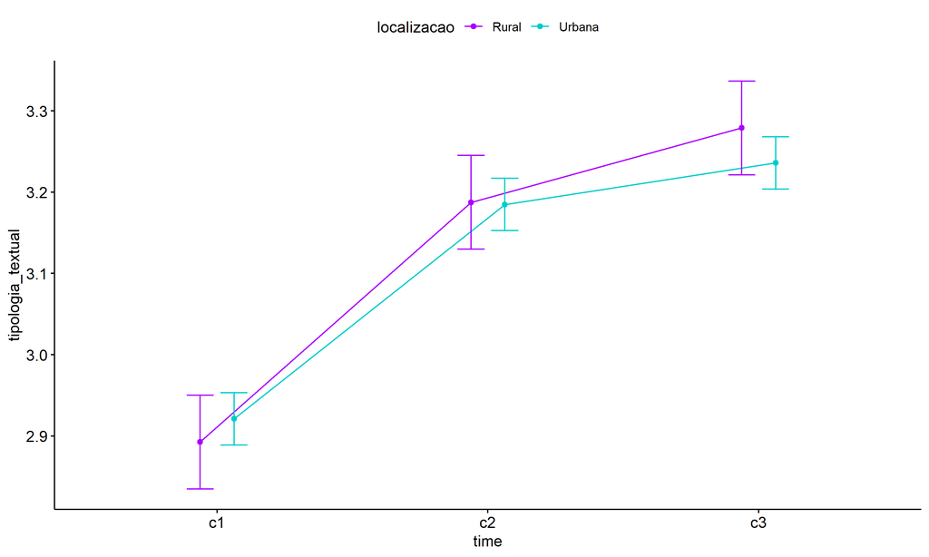

```r
pwc <- add_xy_position(pwc, x = "time", fun = "mean_se", dodge = 0.25)
pd <- position_dodge(width = 0.25)
ggline(emms, x = "time", y = "emmean", color = "localizacao",
       palette = c("#AA00FF","#00CCCC"),
       position = pd, ylab = "tipologia_textual") +
  geom_errorbar(aes(ymin = conf.low, ymax = conf.high, color = localizacao),
                position = pd, width = 0.2) +
  stat_pvalue_manual(pwc, hide.ns = T, tip.length = F, linetype = 1)
```

```r
(pwc <- ldat %>% group_by(localizacao) %>%
    emmeans_test(tipologia_textual ~ time, detailed = T, p.adjust.method = "bonferroni"))
```

```
## # A tibble: 6 × 15
##   localizacao term  .y.            group1 group2 null.value estimate     se    df conf.low conf.high statistic        p    p.adj
## * <fct>       <chr> <chr>          <chr>  <chr>       <dbl>    <dbl>  <dbl> <dbl>    <dbl>     <dbl>     <dbl>    <dbl>    <dbl>
## 1 Rural       time  tipologia_tex… c1     c2              0  -0.295  0.0416  8313  -0.377   -0.213       -7.09 1.47e-12 4.42e-12
## 2 Rural       time  tipologia_tex… c1     c3              0  -0.386  0.0416  8313  -0.468   -0.305       -9.29 2.02e-20 6.06e-20
## 3 Rural       time  tipologia_tex… c2     c3              0  -0.0915 0.0416  8313  -0.173   -0.00988     -2.20 2.80e- 2 8.40e- 2
## 4 Urbana      time  tipologia_tex… c1     c2              0  -0.264  0.0232  8313  -0.309   -0.218      -11.4  8.31e-30 2.49e-29
## 5 Urbana      time  tipologia_tex… c1     c3              0  -0.315  0.0232  8313  -0.360   -0.270      -13.6  1.19e-41 3.58e-41
## 6 Urbana      time  tipologia_tex… c2     c3              0  -0.0512 0.0232  8313  -0.0966  -0.00580     -2.21 2.71e- 2 8.13e- 2
## # ℹ 1 more variable: p.adj.signif <chr>
```

| localizacao | term | .y. | group1 | group2 | null.value | estimate | se | df | conf.low | conf.high | statistic | p | p.adj | p.adj.signif |
| --- | --- | --- | --- | --- | --- | --- | --- | --- | --- | --- | --- | --- | --- | --- |
| Rural | time | tipologia_textual | c1 | c2 | 0 | -0.295 | 0.042 | 8313 | -0.377 | -0.213 | -7.088 | 0.000 | 0.000 | **** |
| Rural | time | tipologia_textual | c1 | c3 | 0 | -0.386 | 0.042 | 8313 | -0.468 | -0.305 | -9.285 | 0.000 | 0.000 | **** |
| Rural | time | tipologia_textual | c2 | c3 | 0 | -0.091 | 0.042 | 8313 | -0.173 | -0.010 | -2.198 | 0.028 | 0.084 | ns |
| Urbana | time | tipologia_textual | c1 | c2 | 0 | -0.264 | 0.023 | 8313 | -0.309 | -0.218 | -11.384 | 0.000 | 0.000 | **** |
| Urbana | time | tipologia_textual | c1 | c3 | 0 | -0.315 | 0.023 | 8313 | -0.360 | -0.270 | -13.595 | 0.000 | 0.000 | **** |
| Urbana | time | tipologia_textual | c2 | c3 | 0 | -0.051 | 0.023 | 8313 | -0.097 | -0.006 | -2.211 | 0.027 | 0.081 | ns |

```r
(emms <- get_emmeans(pwc))
```

```
## # A tibble: 6 × 8
##   localizacao time  emmean     se    df conf.low conf.high method
##   <fct>       <fct>  <dbl>  <dbl> <dbl>    <dbl>     <dbl> <chr>
## 1 Rural       c1      2.89 0.0294  8313     2.83      2.95 Emmeans test
## 2 Rural       c2      3.19 0.0294  8313     3.13      3.25 Emmeans test
## 3 Rural       c3      3.28 0.0294  8313     3.22      3.34 Emmeans test
## 4 Urbana      c1      2.92 0.0164  8313     2.89      2.95 Emmeans test
## 5 Urbana      c2      3.18 0.0164  8313     3.15      3.22 Emmeans test
## 6 Urbana      c3      3.24 0.0164  8313     3.20      3.27 Emmeans test
```

| localizacao | time | emmean | se | df | conf.low | conf.high | method |
| --- | --- | --- | --- | --- | --- | --- | --- |
| Rural | c1 | 2.893 | 0.029 | 8313 | 2.835 | 2.950 | Emmeans test |
| Rural | c2 | 3.187 | 0.029 | 8313 | 3.130 | 3.245 | Emmeans test |
| Rural | c3 | 3.279 | 0.029 | 8313 | 3.221 | 3.337 | Emmeans test |
| Urbana | c1 | 2.921 | 0.016 | 8313 | 2.889 | 2.953 | Emmeans test |
| Urbana | c2 | 3.185 | 0.016 | 8313 | 3.153 | 3.217 | Emmeans test |
| Urbana | c3 | 3.236 | 0.016 | 8313 | 3.204 | 3.268 | Emmeans test |

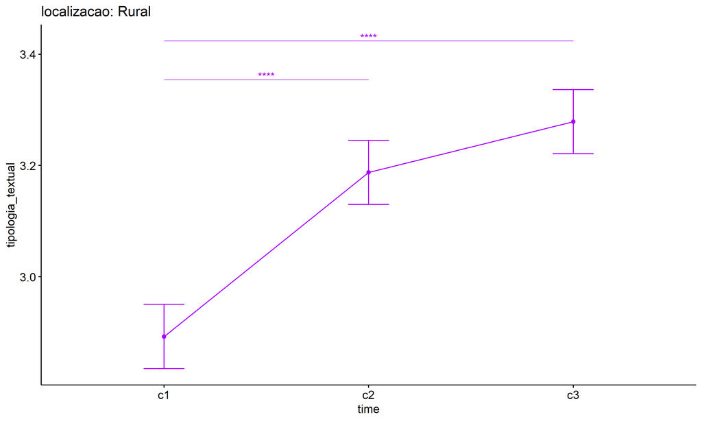

```r
emms.gg <- emms[which(emms$localizacao == "Rural"),]
if (nrow(emms.gg) > 0)
  ggline(emms.gg, x = "time", y = "emmean", color = "#AA00FF", ylab = "tipologia_textual") +
    geom_errorbar(aes(ymin = conf.low, ymax = conf.high),
                  width = 0.2, color = "#AA00FF") +
    stat_pvalue_manual(
      add_xy_position(pwc[which(pwc$localizacao == "Rural"),],
                      x = "time", fun = "mean_se"),
      hide.ns = T, color = "#AA00FF", tip.length = F) +
    labs(title = "localizacao: Rural")+
    theme(legend.text = element_blank())
```

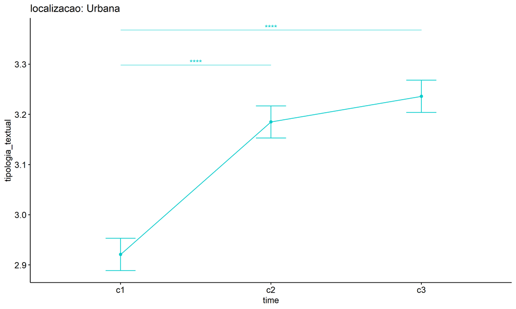

```r
emms.gg <- emms[which(emms$localizacao == "Urbana"),]
if (nrow(emms.gg) > 0)
  ggline(emms.gg, x = "time", y = "emmean", color = "#00CCCC", ylab = "tipologia_textual") +
    geom_errorbar(aes(ymin = conf.low, ymax = conf.high),
                  width = 0.2, color = "#00CCCC") +
    stat_pvalue_manual(
      add_xy_position(pwc[which(pwc$localizacao == "Urbana"),],
                      x = "time", fun = "mean_se"),
      hide.ns = T, color = "#00CCCC", tip.length = F) +
    labs(title = "localizacao: Urbana")+
    theme(legend.text = element_blank())
```

## PairWise Computation after removing non.normal data

```r
if (length(non.ids) > 0)
  (pwc2 <- ldat2 %>% group_by(time) %>%
     emmeans_test(tipologia_textual ~ localizacao, detailed = T, p.adjust.method = "bonferroni"))
```

```r
if (length(non.ids) > 0)
  (emms2 <- get_emmeans(pwc2))
```

```r
if (length(non.ids) > 0) {
  pwc2 <- add_xy_position(pwc2, x = "time", fun = "mean_se", dodge = 0.25)
  pd2 <- position_dodge(width = 0.25)

  ggline(emms2, x = "time", y = "emmean", color = "localizacao",
         palette = c("#AA00FF","#00CCCC"),
         position = pd, ylab = "tipologia_textual") +
    geom_errorbar(aes(ymin = conf.low, ymax = conf.high, color = localizacao),
                position = pd, width = 0.2) +
    stat_pvalue_manual(pwc2, hide.ns = T, tip.length = F, linetype = 1)
}
```

```r
if (length(non.ids) > 0)
  (pwc2 <- ldat2 %>% group_by(localizacao) %>%
     emmeans_test(tipologia_textual ~ time, detailed = T, p.adjust.method = "bonferroni"))
```

```r
if (length(non.ids) > 0)
  (emms2 <- get_emmeans(pwc2))
```

```r
if (length(non.ids) > 0) {
  emms.gg <- emms2[which(emms2$localizacao == "Rural"),]
  if (nrow(emms.gg) > 0)
    ggline(emms.gg, x = "time", y = "emmean", color = "#AA00FF", ylab = "tipologia_textual") +
    geom_errorbar(aes(ymin = conf.low, ymax = conf.high),
                  width = 0.2, color = "#AA00FF") +
    stat_pvalue_manual(
      add_xy_position(pwc[which(pwc$localizacao == "Rural"),],
                      x = "time", fun = "mean_se"),
      hide.ns = T, color = "#AA00FF", tip.length = F) +
    labs(title = "localizacao: Rural") +
    theme(legend.text = element_blank())
}
```

```r
if (length(non.ids) > 0) {
  emms.gg <- emms2[which(emms2$localizacao == "Urbana"),]
  if (nrow(emms.gg) > 0)
    ggline(emms.gg, x = "time", y = "emmean", color = "#00CCCC", ylab = "tipologia_textual") +
    geom_errorbar(aes(ymin = conf.low, ymax = conf.high),
                  width = 0.2, color = "#00CCCC") +
    stat_pvalue_manual(
      add_xy_position(pwc[which(pwc$localizacao == "Urbana"),],
                      x = "time", fun = "mean_se"),
      hide.ns = T, color = "#00CCCC", tip.length = F) +
    labs(title = "localizacao: Urbana") +
    theme(legend.text = element_blank())
}
```

# ANOVA: tipologia_textual ~ time*regiao + Error(id/time)

## Data Preparation

```r
data <- edat[,c("aluno_id","regiao","ciclo","tipologia_textual")]
data <- data[data$ciclo %in% c("Primeiro Ciclo","Segundo Ciclo","Terceiro Ciclo"),]
data$ciclo <- factor(data$ciclo, c("Primeiro Ciclo","Segundo Ciclo","Terceiro Ciclo"))
data <- unique(data)

wdat <- spread(data, ciclo, tipologia_textual)
wdat <- wdat[complete.cases(wdat),]
colnames(wdat) <- c("id","regiao","c1","c2","c3")

ldat <- gather(wdat, key = time, value = tipologia_textual, c1,c2,c3) %>%
  convert_as_factor(id, time)
ldat <- remove_group_data(ldat, "tipologia_textual", c("time", "regiao"), n.limit = 30)
ldat$regiao <- factor(ldat$regiao, sort(unique(ldat$regiao)))
```

### Check assumptions: Identifying Outliers

```r
outliers <- identify_outliers(group_by(ldat, time, regiao), tipologia_textual)
(outliers <- outliers[outliers$is.extreme == T,])
```

```
## [1] regiao            time              id                tipologia_textual is.outlier        is.extreme
## <0 rows> (or 0-length row.names)
```

| regiao | time | id | tipologia_textual | is.outlier | is.extreme |
| --- | --- | --- | --- | --- | --- |

### Check assumptions: Normality Test

```r
(normality.df <- normality.test.per.groups(ldat, "tipologia_textual", c("time", "regiao")))
```

```
##                  var          variable time       regiao    n    skewness  kurtosis symmetry   statistic     method
## 1  tipologia_textual tipologia_textual   c1 Centro-Oeste  216  0.05967408 -1.152513      YES    72.37042 D'Agostino
## 2  tipologia_textual tipologia_textual   c1     Nordeste 1499  0.11468775 -1.307345      YES  4177.92381 D'Agostino
## 3  tipologia_textual tipologia_textual   c1        Norte  202  0.52965971 -1.199695       NO    93.71590 D'Agostino
## 4  tipologia_textual tipologia_textual   c1      Sudeste  693  0.03351865 -1.385434      YES 97074.99970 D'Agostino
## 5  tipologia_textual tipologia_textual   c1          Sul  163  0.05532182 -1.211261      YES    65.13520 D'Agostino
## 6  tipologia_textual tipologia_textual   c2 Centro-Oeste  216 -0.39485274 -1.118657      YES    66.35619 D'Agostino
## 7  tipologia_textual tipologia_textual   c2     Nordeste 1499 -0.38171687 -1.281086      YES  2727.72201 D'Agostino
## 8  tipologia_textual tipologia_textual   c2        Norte  202  0.06641640 -1.480926      YES  1972.31047 D'Agostino
## 9  tipologia_textual tipologia_textual   c2      Sudeste  693 -0.35756308 -1.218514      YES   540.84790 D'Agostino
## 10 tipologia_textual tipologia_textual   c2          Sul  163 -0.36542129 -1.401230      YES   234.64079 D'Agostino
## 11 tipologia_textual tipologia_textual   c3 Centro-Oeste  216 -0.37292490 -1.166883      YES    83.05127 D'Agostino
## 12 tipologia_textual tipologia_textual   c3     Nordeste 1499 -0.46626000 -1.191051      YES  1113.60422 D'Agostino
## 13 tipologia_textual tipologia_textual   c3        Norte  202 -0.24163079 -1.312242      YES   173.52882 D'Agostino
## 14 tipologia_textual tipologia_textual   c3      Sudeste  693 -0.52518235 -1.072578       NO   233.50336 D'Agostino
```

[output cut: 17 more lines]

| var | variable | time | regiao | n | skewness | kurtosis | symmetry | statistic | method | p | p.signif | normality |
| --- | --- | --- | --- | --- | --- | --- | --- | --- | --- | --- | --- | --- |
| tipologia_textual | tipologia_textual | c1 | Centro-Oeste | 216 | 0.060 | -1.153 | YES | 72.370 | D’Agostino | 0 | **** | - |
| tipologia_textual | tipologia_textual | c1 | Nordeste | 1499 | 0.115 | -1.307 | YES | 4177.924 | D’Agostino | 0 | **** | - |
| tipologia_textual | tipologia_textual | c1 | Norte | 202 | 0.530 | -1.200 | NO | 93.716 | D’Agostino | 0 | **** | - |
| tipologia_textual | tipologia_textual | c1 | Sudeste | 693 | 0.034 | -1.385 | YES | 97075.000 | D’Agostino | 0 | **** | - |
| tipologia_textual | tipologia_textual | c1 | Sul | 163 | 0.055 | -1.211 | YES | 65.135 | D’Agostino | 0 | **** | QQ |
| tipologia_textual | tipologia_textual | c2 | Centro-Oeste | 216 | -0.395 | -1.119 | YES | 66.356 | D’Agostino | 0 | **** | - |
| tipologia_textual | tipologia_textual | c2 | Nordeste | 1499 | -0.382 | -1.281 | YES | 2727.722 | D’Agostino | 0 | **** | - |
| tipologia_textual | tipologia_textual | c2 | Norte | 202 | 0.066 | -1.481 | YES | 1972.310 | D’Agostino | 0 | **** | - |
| tipologia_textual | tipologia_textual | c2 | Sudeste | 693 | -0.358 | -1.219 | YES | 540.848 | D’Agostino | 0 | **** | - |
| tipologia_textual | tipologia_textual | c2 | Sul | 163 | -0.365 | -1.401 | YES | 234.641 | D’Agostino | 0 | **** | QQ |
| tipologia_textual | tipologia_textual | c3 | Centro-Oeste | 216 | -0.373 | -1.167 | YES | 83.051 | D’Agostino | 0 | **** | - |
| tipologia_textual | tipologia_textual | c3 | Nordeste | 1499 | -0.466 | -1.191 | YES | 1113.604 | D’Agostino | 0 | **** | - |
| tipologia_textual | tipologia_textual | c3 | Norte | 202 | -0.242 | -1.312 | YES | 173.529 | D’Agostino | 0 | **** | - |
| tipologia_textual | tipologia_textual | c3 | Sudeste | 693 | -0.525 | -1.073 | NO | 233.503 | D’Agostino | 0 | **** | - |
| tipologia_textual | tipologia_textual | c3 | Sul | 163 | -0.631 | -1.099 | NO | 47.452 | D’Agostino | 0 | **** | QQ |

```r
(non.ids <- unique(do.call(
  c, lapply(which(normality.df$normality == 'NO'), FUN = function(i) {
  idx = which(ldat$time == normality.df$time[i] &
                ldat$regiao == normality.df$regiao[i])
  getNonNormal(ldat$"tipologia_textual"[idx], ldat$id[idx])
}))))
```

```r
if (length(non.ids) > 0)
  ldat2 <- ldat[!ldat$id %in% non.ids,]
```

### Summary Statistics

```r
(sdat <- ldat %>% group_by(time, regiao) %>%
   get_summary_stats(tipologia_textual, type = "mean_sd"))
```

```
## # A tibble: 15 × 6
##    regiao       time  variable              n  mean    sd
##    <fct>        <fct> <fct>             <dbl> <dbl> <dbl>
##  1 Centro-Oeste c1    tipologia_textual   216  2.95 0.696
##  2 Nordeste     c1    tipologia_textual  1499  2.91 0.74
##  3 Norte        c1    tipologia_textual   202  2.71 0.753
##  4 Sudeste      c1    tipologia_textual   693  2.96 0.759
##  5 Sul          c1    tipologia_textual   163  2.94 0.721
##  6 Centro-Oeste c2    tipologia_textual   216  3.2  0.728
##  7 Nordeste     c2    tipologia_textual  1499  3.21 0.767
##  8 Norte        c2    tipologia_textual   202  2.96 0.798
##  9 Sudeste      c2    tipologia_textual   693  3.20 0.745
## 10 Sul          c2    tipologia_textual   163  3.19 0.805
## 11 Centro-Oeste c3    tipologia_textual   216  3.18 0.736
## 12 Nordeste     c3    tipologia_textual  1499  3.25 0.757
## 13 Norte        c3    tipologia_textual   202  3.09 0.759
## 14 Sudeste      c3    tipologia_textual   693  3.28 0.739
## 15 Sul          c3    tipologia_textual   163  3.34 0.755
```

| regiao | time | variable | n | mean | sd |
| --- | --- | --- | --- | --- | --- |
| Centro-Oeste | c1 | tipologia_textual | 216 | 2.951 | 0.696 |
| Nordeste | c1 | tipologia_textual | 1499 | 2.914 | 0.740 |
| Norte | c1 | tipologia_textual | 202 | 2.711 | 0.753 |
| Sudeste | c1 | tipologia_textual | 693 | 2.957 | 0.759 |
| Sul | c1 | tipologia_textual | 163 | 2.942 | 0.721 |
| Centro-Oeste | c2 | tipologia_textual | 216 | 3.200 | 0.728 |
| Nordeste | c2 | tipologia_textual | 1499 | 3.206 | 0.767 |
| Norte | c2 | tipologia_textual | 202 | 2.964 | 0.798 |
| Sudeste | c2 | tipologia_textual | 693 | 3.199 | 0.745 |
| Sul | c2 | tipologia_textual | 163 | 3.192 | 0.805 |
| Centro-Oeste | c3 | tipologia_textual | 216 | 3.178 | 0.736 |
| Nordeste | c3 | tipologia_textual | 1499 | 3.250 | 0.757 |
| Norte | c3 | tipologia_textual | 202 | 3.094 | 0.759 |
| Sudeste | c3 | tipologia_textual | 693 | 3.281 | 0.739 |
| Sul | c3 | tipologia_textual | 163 | 3.344 | 0.755 |

```r
if (length(non.ids) > 0)
  (sdat <- ldat2 %>% group_by(time, regiao) %>%
      get_summary_stats(tipologia_textual, type = "mean_sd"))
```

| regiao | time | variable | n | mean | sd |
| --- | --- | --- | --- | --- | --- |
| Centro-Oeste | c1 | tipologia_textual | 216 | 2.951 | 0.696 |
| Nordeste | c1 | tipologia_textual | 1499 | 2.914 | 0.740 |
| Norte | c1 | tipologia_textual | 202 | 2.711 | 0.753 |
| Sudeste | c1 | tipologia_textual | 693 | 2.957 | 0.759 |
| Sul | c1 | tipologia_textual | 163 | 2.942 | 0.721 |
| Centro-Oeste | c2 | tipologia_textual | 216 | 3.200 | 0.728 |
| Nordeste | c2 | tipologia_textual | 1499 | 3.206 | 0.767 |
| Norte | c2 | tipologia_textual | 202 | 2.964 | 0.798 |
| Sudeste | c2 | tipologia_textual | 693 | 3.199 | 0.745 |
| Sul | c2 | tipologia_textual | 163 | 3.192 | 0.805 |
| Centro-Oeste | c3 | tipologia_textual | 216 | 3.178 | 0.736 |
| Nordeste | c3 | tipologia_textual | 1499 | 3.250 | 0.757 |
| Norte | c3 | tipologia_textual | 202 | 3.094 | 0.759 |
| Sudeste | c3 | tipologia_textual | 693 | 3.281 | 0.739 |
| Sul | c3 | tipologia_textual | 163 | 3.344 | 0.755 |

## ANOVA Computation

```r
(res.aov <- anova_test(ldat, dv = tipologia_textual, wid = id, between = regiao, within = time))
```

```
## ANOVA Table (type III tests)
##
## $ANOVA
##        Effect DFn  DFd      F                                            p p<.05      ges
## 1      regiao   4 2768  8.339 0.000001100000000000000056074936360950289327     * 0.005000
## 2        time   2 5536 92.455 0.000000000000000000000000000000000000000319     * 0.018000
## 3 regiao:time   8 5536  0.875 0.537000000000000032862601528904633596539497       0.000693
##
## $`Mauchly's Test for Sphericity`
##        Effect     W    p p<.05
## 1        time 0.998 0.12
## 2 regiao:time 0.998 0.12
##
## $`Sphericity Corrections`
##        Effect   GGe        DF[GG]                                        p[GG] p[GG]<.05   HFe        DF[HF]
## 1        time 0.998    2, 5527.54 0.000000000000000000000000000000000000000363         * 0.999    2, 5531.53
## 2 regiao:time 0.998 7.99, 5527.54 0.537000000000000032862601528904633596539497           0.999 7.99, 5531.53
##                                          p[HF] p[HF]<.05
## 1 0.000000000000000000000000000000000000000342         *
## 2 0.537000000000000032862601528904633596539497
```

| Effect | DFn | DFd | F | p | p<.05 | ges |
| --- | --- | --- | --- | --- | --- | --- |
| regiao | 4 | 2768 | 8.339 | 0.000 | * | 0.005 |
| time | 2 | 5536 | 92.455 | 0.000 | * | 0.018 |
| regiao:time | 8 | 5536 | 0.875 | 0.537 |  | 0.001 |

| Effect | W | p | p<.05 |
| --- | --- | --- | --- |
| time | 0.998 | 0.12 |  |
| regiao:time | 0.998 | 0.12 |  |

| Effect | GGe | DF[GG] | p[GG] | p[GG]<.05 | HFe | DF[HF] | p[HF] | p[HF]<.05 |
| --- | --- | --- | --- | --- | --- | --- | --- | --- |
| time | 0.998 | 2, 5527.54 | 0.000 | * | 0.999 | 2, 5531.53 | 0.000 | * |
| regiao:time | 0.998 | 7.99, 5527.54 | 0.537 |  | 0.999 | 7.99, 5531.53 | 0.537 |  |

## ANOVA Computation after removing non.normal data

```r
if (length(non.ids) > 0)
  (res.aov2 <- anova_test(ldat2, dv = tipologia_textual, wid = id, between = regiao , within = time))
```

## PairWise Computation

```r
(pwc <- ldat %>% group_by(time) %>%
   emmeans_test(tipologia_textual ~ regiao, detailed = T, p.adjust.method = "bonferroni"))
```

| time | term | .y. | group1 | group2 | null.value | estimate | se | df | conf.low | conf.high | statistic | p | p.adj | p.adj.signif |
| --- | --- | --- | --- | --- | --- | --- | --- | --- | --- | --- | --- | --- | --- | --- |
| c1 | regiao | tipologia_textual | Centro | Oeste | 0 | 0.038 | 0.055 | 8304 | -0.070 | 0.145 | 0.686 | 0.493 | 1.000 | ns |
| c1 | regiao | tipologia_textual | Centro | Oeste | 0 | 0.240 | 0.074 | 8304 | 0.096 | 0.384 | 3.263 | 0.001 | 0.011 | * |
| c1 | regiao | tipologia_textual | Centro | Oeste | 0 | -0.005 | 0.059 | 8304 | -0.120 | 0.110 | -0.089 | 0.929 | 1.000 | ns |
| c1 | regiao | tipologia_textual | Centro | Oeste | 0 | 0.010 | 0.078 | 8304 | -0.143 | 0.163 | 0.124 | 0.901 | 1.000 | ns |
| c1 | regiao | tipologia_textual | Nordeste | Norte | 0 | 0.203 | 0.056 | 8304 | 0.092 | 0.313 | 3.595 | 0.000 | 0.003 | ** |
| c1 | regiao | tipologia_textual | Nordeste | Sudeste | 0 | -0.043 | 0.035 | 8304 | -0.110 | 0.025 | -1.238 | 0.216 | 1.000 | ns |
| c1 | regiao | tipologia_textual | Nordeste | Sul | 0 | -0.028 | 0.062 | 8304 | -0.149 | 0.094 | -0.450 | 0.653 | 1.000 | ns |
| c1 | regiao | tipologia_textual | Norte | Sudeste | 0 | -0.245 | 0.060 | 8304 | -0.363 | -0.128 | -4.081 | 0.000 | 0.000 | *** |
| c1 | regiao | tipologia_textual | Norte | Sul | 0 | -0.230 | 0.079 | 8304 | -0.386 | -0.075 | -2.911 | 0.004 | 0.036 | * |
| c1 | regiao | tipologia_textual | Sudeste | Sul | 0 | 0.015 | 0.065 | 8304 | -0.113 | 0.143 | 0.227 | 0.820 | 1.000 | ns |
| c2 | regiao | tipologia_textual | Centro | Oeste | 0 | -0.006 | 0.055 | 8304 | -0.113 | 0.101 | -0.113 | 0.910 | 1.000 | ns |
| c2 | regiao | tipologia_textual | Centro | Oeste | 0 | 0.236 | 0.074 | 8304 | 0.091 | 0.380 | 3.203 | 0.001 | 0.014 | * |
| c2 | regiao | tipologia_textual | Centro | Oeste | 0 | 0.000 | 0.059 | 8304 | -0.115 | 0.115 | 0.006 | 0.995 | 1.000 | ns |
| c2 | regiao | tipologia_textual | Centro | Oeste | 0 | 0.008 | 0.078 | 8304 | -0.145 | 0.161 | 0.104 | 0.917 | 1.000 | ns |
| c2 | regiao | tipologia_textual | Nordeste | Norte | 0 | 0.242 | 0.056 | 8304 | 0.131 | 0.352 | 4.293 | 0.000 | 0.000 | *** |
| c2 | regiao | tipologia_textual | Nordeste | Sudeste | 0 | 0.007 | 0.035 | 8304 | -0.061 | 0.074 | 0.189 | 0.850 | 1.000 | ns |
| c2 | regiao | tipologia_textual | Nordeste | Sul | 0 | 0.014 | 0.062 | 8304 | -0.107 | 0.136 | 0.231 | 0.818 | 1.000 | ns |
| c2 | regiao | tipologia_textual | Norte | Sudeste | 0 | -0.235 | 0.060 | 8304 | -0.353 | -0.118 | -3.915 | 0.000 | 0.001 | *** |
| c2 | regiao | tipologia_textual | Norte | Sul | 0 | -0.228 | 0.079 | 8304 | -0.383 | -0.072 | -2.875 | 0.004 | 0.041 | * |
| c2 | regiao | tipologia_textual | Sudeste | Sul | 0 | 0.008 | 0.065 | 8304 | -0.121 | 0.136 | 0.119 | 0.905 | 1.000 | ns |
| c3 | regiao | tipologia_textual | Centro | Oeste | 0 | -0.071 | 0.055 | 8304 | -0.179 | 0.036 | -1.304 | 0.192 | 1.000 | ns |
| c3 | regiao | tipologia_textual | Centro | Oeste | 0 | 0.084 | 0.074 | 8304 | -0.060 | 0.228 | 1.144 | 0.253 | 1.000 | ns |
| c3 | regiao | tipologia_textual | Centro | Oeste | 0 | -0.103 | 0.059 | 8304 | -0.218 | 0.012 | -1.760 | 0.078 | 0.784 | ns |
| c3 | regiao | tipologia_textual | Centro | Oeste | 0 | -0.165 | 0.078 | 8304 | -0.318 | -0.012 | -2.119 | 0.034 | 0.341 | ns |
| c3 | regiao | tipologia_textual | Nordeste | Norte | 0 | 0.156 | 0.056 | 8304 | 0.045 | 0.266 | 2.760 | 0.006 | 0.058 | ns |
| c3 | regiao | tipologia_textual | Nordeste | Sudeste | 0 | -0.032 | 0.035 | 8304 | -0.099 | 0.036 | -0.920 | 0.358 | 1.000 | ns |
| c3 | regiao | tipologia_textual | Nordeste | Sul | 0 | -0.094 | 0.062 | 8304 | -0.216 | 0.028 | -1.515 | 0.130 | 1.000 | ns |
| c3 | regiao | tipologia_textual | Norte | Sudeste | 0 | -0.187 | 0.060 | 8304 | -0.305 | -0.069 | -3.116 | 0.002 | 0.018 | * |
| c3 | regiao | tipologia_textual | Norte | Sul | 0 | -0.249 | 0.079 | 8304 | -0.405 | -0.094 | -3.151 | 0.002 | 0.016 | * |
| c3 | regiao | tipologia_textual | Sudeste | Sul | 0 | -0.062 | 0.065 | 8304 | -0.190 | 0.066 | -0.950 | 0.342 | 1.000 | ns |

```r
(emms <- get_emmeans(pwc))
```

```
## # A tibble: 15 × 8
##    time  regiao       emmean     se    df conf.low conf.high method
##    <fct> <fct>         <dbl>  <dbl> <dbl>    <dbl>     <dbl> <chr>
##  1 c1    Centro-Oeste   2.95 0.0512  8304     2.85      3.05 Emmeans test
##  2 c1    Nordeste       2.91 0.0194  8304     2.88      2.95 Emmeans test
##  3 c1    Norte          2.71 0.0529  8304     2.61      2.81 Emmeans test
##  4 c1    Sudeste        2.96 0.0286  8304     2.90      3.01 Emmeans test
##  5 c1    Sul            2.94 0.0589  8304     2.83      3.06 Emmeans test
##  6 c2    Centro-Oeste   3.20 0.0512  8304     3.10      3.30 Emmeans test
##  7 c2    Nordeste       3.21 0.0194  8304     3.17      3.24 Emmeans test
##  8 c2    Norte          2.96 0.0529  8304     2.86      3.07 Emmeans test
##  9 c2    Sudeste        3.20 0.0286  8304     3.14      3.26 Emmeans test
## 10 c2    Sul            3.19 0.0589  8304     3.08      3.31 Emmeans test
## 11 c3    Centro-Oeste   3.18 0.0512  8304     3.08      3.28 Emmeans test
## 12 c3    Nordeste       3.25 0.0194  8304     3.21      3.29 Emmeans test
## 13 c3    Norte          3.09 0.0529  8304     2.99      3.20 Emmeans test
## 14 c3    Sudeste        3.28 0.0286  8304     3.23      3.34 Emmeans test
## 15 c3    Sul            3.34 0.0589  8304     3.23      3.46 Emmeans test
```

| time | regiao | emmean | se | df | conf.low | conf.high | method |
| --- | --- | --- | --- | --- | --- | --- | --- |
| c1 | Centro-Oeste | 2.951 | 0.051 | 8304 | 2.851 | 3.052 | Emmeans test |
| c1 | Nordeste | 2.914 | 0.019 | 8304 | 2.876 | 2.952 | Emmeans test |
| c1 | Norte | 2.711 | 0.053 | 8304 | 2.608 | 2.815 | Emmeans test |
| c1 | Sudeste | 2.957 | 0.029 | 8304 | 2.901 | 3.013 | Emmeans test |
| c1 | Sul | 2.942 | 0.059 | 8304 | 2.826 | 3.057 | Emmeans test |
| c2 | Centro-Oeste | 3.200 | 0.051 | 8304 | 3.100 | 3.300 | Emmeans test |
| c2 | Nordeste | 3.206 | 0.019 | 8304 | 3.168 | 3.244 | Emmeans test |
| c2 | Norte | 2.964 | 0.053 | 8304 | 2.860 | 3.068 | Emmeans test |
| c2 | Sudeste | 3.199 | 0.029 | 8304 | 3.144 | 3.255 | Emmeans test |
| c2 | Sul | 3.192 | 0.059 | 8304 | 3.076 | 3.307 | Emmeans test |
| c3 | Centro-Oeste | 3.178 | 0.051 | 8304 | 3.078 | 3.279 | Emmeans test |
| c3 | Nordeste | 3.250 | 0.019 | 8304 | 3.212 | 3.288 | Emmeans test |
| c3 | Norte | 3.094 | 0.053 | 8304 | 2.990 | 3.198 | Emmeans test |
| c3 | Sudeste | 3.281 | 0.029 | 8304 | 3.225 | 3.337 | Emmeans test |
| c3 | Sul | 3.344 | 0.059 | 8304 | 3.228 | 3.459 | Emmeans test |

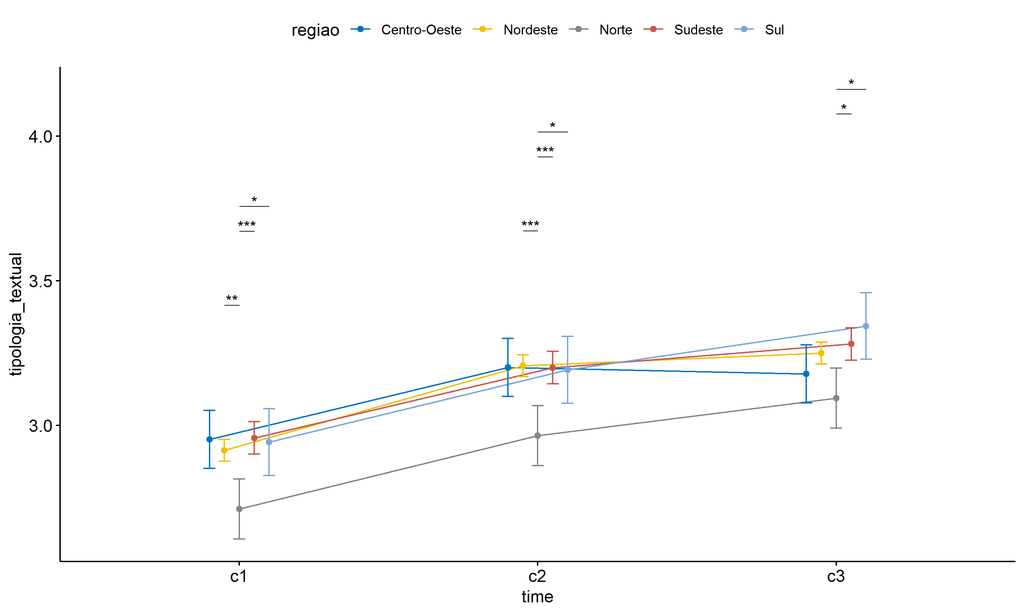

```r
pwc <- add_xy_position(pwc, x = "time", fun = "mean_se", dodge = 0.25)
pd <- position_dodge(width = 0.25)
ggline(emms, x = "time", y = "emmean", color = "regiao",
       palette = c("#0073C2FF","#EFC000FF","#868686FF","#CD534CFF","#7AA6DCFF"),
       position = pd, ylab = "tipologia_textual") +
  geom_errorbar(aes(ymin = conf.low, ymax = conf.high, color = regiao),
                position = pd, width = 0.2) +
  stat_pvalue_manual(pwc, hide.ns = T, tip.length = F, linetype = 1)
```

```r
(pwc <- ldat %>% group_by(regiao) %>%
    emmeans_test(tipologia_textual ~ time, detailed = T, p.adjust.method = "bonferroni"))
```

```
## # A tibble: 15 × 15
##    regiao term  .y.   group1 group2 null.value estimate     se    df conf.low conf.high statistic        p    p.adj p.adj.signif
##  * <fct>  <chr> <chr> <chr>  <chr>       <dbl>    <dbl>  <dbl> <dbl>    <dbl>     <dbl>     <dbl>    <dbl>    <dbl> <chr>
##  1 Centr… time  tipo… c1     c2              0  -0.248  0.0724  8304  -0.390   -0.107      -3.43  5.98e- 4 1.79e- 3 **
##  2 Centr… time  tipo… c1     c3              0  -0.227  0.0724  8304  -0.369   -0.0850     -3.14  1.72e- 3 5.17e- 3 **
##  3 Centr… time  tipo… c2     c3              0   0.0216 0.0724  8304  -0.120    0.163       0.299 7.65e- 1 1   e+ 0 ns
##  4 Norde… time  tipo… c1     c2              0  -0.292  0.0275  8304  -0.346   -0.238     -10.6   2.91e-26 8.73e-26 ****
##  5 Norde… time  tipo… c1     c3              0  -0.336  0.0275  8304  -0.390   -0.282     -12.2   4.46e-34 1.34e-33 ****
##  6 Norde… time  tipo… c2     c3              0  -0.0436 0.0275  8304  -0.0974   0.0103     -1.59  1.13e- 1 3.38e- 1 ns
##  7 Norte  time  tipo… c1     c2              0  -0.253  0.0748  8304  -0.400   -0.106      -3.38  7.28e- 4 2.18e- 3 **
##  8 Norte  time  tipo… c1     c3              0  -0.383  0.0748  8304  -0.530   -0.236      -5.12  3.18e- 7 9.53e- 7 ****
##  9 Norte  time  tipo… c2     c3              0  -0.130  0.0748  8304  -0.277    0.0167     -1.74  8.24e- 2 2.47e- 1 ns
## 10 Sudes… time  tipo… c1     c2              0  -0.243  0.0404  8304  -0.322   -0.164      -6.01  1.89e- 9 5.68e- 9 ****
## 11 Sudes… time  tipo… c1     c3              0  -0.325  0.0404  8304  -0.404   -0.246      -8.04  1.02e-15 3.05e-15 ****
## 12 Sudes… time  tipo… c2     c3              0  -0.0819 0.0404  8304  -0.161   -0.00271    -2.03  4.27e- 2 1.28e- 1 ns
## 13 Sul    time  tipo… c1     c2              0  -0.250  0.0833  8304  -0.413   -0.0867     -3.00  2.69e- 3 8.08e- 3 **
## 14 Sul    time  tipo… c1     c3              0  -0.402  0.0833  8304  -0.565   -0.239      -4.82  1.43e- 6 4.28e- 6 ****
## 15 Sul    time  tipo… c2     c3              0  -0.152  0.0833  8304  -0.315    0.0114     -1.82  6.83e- 2 2.05e- 1 ns
```

| regiao | term | .y. | group1 | group2 | null.value | estimate | se | df | conf.low | conf.high | statistic | p | p.adj | p.adj.signif |
| --- | --- | --- | --- | --- | --- | --- | --- | --- | --- | --- | --- | --- | --- | --- |
| Centro-Oeste | time | tipologia_textual | c1 | c2 | 0 | -0.248 | 0.072 | 8304 | -0.390 | -0.107 | -3.434 | 0.001 | 0.002 | ** |
| Centro-Oeste | time | tipologia_textual | c1 | c3 | 0 | -0.227 | 0.072 | 8304 | -0.369 | -0.085 | -3.135 | 0.002 | 0.005 | ** |
| Centro-Oeste | time | tipologia_textual | c2 | c3 | 0 | 0.022 | 0.072 | 8304 | -0.120 | 0.163 | 0.299 | 0.765 | 1.000 | ns |
| Nordeste | time | tipologia_textual | c1 | c2 | 0 | -0.292 | 0.027 | 8304 | -0.346 | -0.238 | -10.639 | 0.000 | 0.000 | **** |
| Nordeste | time | tipologia_textual | c1 | c3 | 0 | -0.336 | 0.027 | 8304 | -0.390 | -0.282 | -12.225 | 0.000 | 0.000 | **** |
| Nordeste | time | tipologia_textual | c2 | c3 | 0 | -0.044 | 0.027 | 8304 | -0.097 | 0.010 | -1.587 | 0.113 | 0.338 | ns |
| Norte | time | tipologia_textual | c1 | c2 | 0 | -0.253 | 0.075 | 8304 | -0.400 | -0.106 | -3.380 | 0.001 | 0.002 | ** |
| Norte | time | tipologia_textual | c1 | c3 | 0 | -0.383 | 0.075 | 8304 | -0.530 | -0.236 | -5.117 | 0.000 | 0.000 | **** |
| Norte | time | tipologia_textual | c2 | c3 | 0 | -0.130 | 0.075 | 8304 | -0.277 | 0.017 | -1.737 | 0.082 | 0.247 | ns |
| Sudeste | time | tipologia_textual | c1 | c2 | 0 | -0.243 | 0.040 | 8304 | -0.322 | -0.164 | -6.013 | 0.000 | 0.000 | **** |
| Sudeste | time | tipologia_textual | c1 | c3 | 0 | -0.325 | 0.040 | 8304 | -0.404 | -0.246 | -8.041 | 0.000 | 0.000 | **** |
| Sudeste | time | tipologia_textual | c2 | c3 | 0 | -0.082 | 0.040 | 8304 | -0.161 | -0.003 | -2.027 | 0.043 | 0.128 | ns |
| Sul | time | tipologia_textual | c1 | c2 | 0 | -0.250 | 0.083 | 8304 | -0.413 | -0.087 | -3.002 | 0.003 | 0.008 | ** |
| Sul | time | tipologia_textual | c1 | c3 | 0 | -0.402 | 0.083 | 8304 | -0.565 | -0.239 | -4.825 | 0.000 | 0.000 | **** |
| Sul | time | tipologia_textual | c2 | c3 | 0 | -0.152 | 0.083 | 8304 | -0.315 | 0.011 | -1.823 | 0.068 | 0.205 | ns |

```r
(emms <- get_emmeans(pwc))
```

```
## # A tibble: 15 × 8
##    regiao       time  emmean     se    df conf.low conf.high method
##    <fct>        <fct>  <dbl>  <dbl> <dbl>    <dbl>     <dbl> <chr>
##  1 Centro-Oeste c1      2.95 0.0512  8304     2.85      3.05 Emmeans test
##  2 Centro-Oeste c2      3.20 0.0512  8304     3.10      3.30 Emmeans test
##  3 Centro-Oeste c3      3.18 0.0512  8304     3.08      3.28 Emmeans test
##  4 Nordeste     c1      2.91 0.0194  8304     2.88      2.95 Emmeans test
##  5 Nordeste     c2      3.21 0.0194  8304     3.17      3.24 Emmeans test
##  6 Nordeste     c3      3.25 0.0194  8304     3.21      3.29 Emmeans test
##  7 Norte        c1      2.71 0.0529  8304     2.61      2.81 Emmeans test
##  8 Norte        c2      2.96 0.0529  8304     2.86      3.07 Emmeans test
##  9 Norte        c3      3.09 0.0529  8304     2.99      3.20 Emmeans test
## 10 Sudeste      c1      2.96 0.0286  8304     2.90      3.01 Emmeans test
## 11 Sudeste      c2      3.20 0.0286  8304     3.14      3.26 Emmeans test
## 12 Sudeste      c3      3.28 0.0286  8304     3.23      3.34 Emmeans test
## 13 Sul          c1      2.94 0.0589  8304     2.83      3.06 Emmeans test
## 14 Sul          c2      3.19 0.0589  8304     3.08      3.31 Emmeans test
## 15 Sul          c3      3.34 0.0589  8304     3.23      3.46 Emmeans test
```

| regiao | time | emmean | se | df | conf.low | conf.high | method |
| --- | --- | --- | --- | --- | --- | --- | --- |
| Centro-Oeste | c1 | 2.951 | 0.051 | 8304 | 2.851 | 3.052 | Emmeans test |
| Centro-Oeste | c2 | 3.200 | 0.051 | 8304 | 3.100 | 3.300 | Emmeans test |
| Centro-Oeste | c3 | 3.178 | 0.051 | 8304 | 3.078 | 3.279 | Emmeans test |
| Nordeste | c1 | 2.914 | 0.019 | 8304 | 2.876 | 2.952 | Emmeans test |
| Nordeste | c2 | 3.206 | 0.019 | 8304 | 3.168 | 3.244 | Emmeans test |
| Nordeste | c3 | 3.250 | 0.019 | 8304 | 3.212 | 3.288 | Emmeans test |
| Norte | c1 | 2.711 | 0.053 | 8304 | 2.608 | 2.815 | Emmeans test |
| Norte | c2 | 2.964 | 0.053 | 8304 | 2.860 | 3.068 | Emmeans test |
| Norte | c3 | 3.094 | 0.053 | 8304 | 2.990 | 3.198 | Emmeans test |
| Sudeste | c1 | 2.957 | 0.029 | 8304 | 2.901 | 3.013 | Emmeans test |
| Sudeste | c2 | 3.199 | 0.029 | 8304 | 3.144 | 3.255 | Emmeans test |
| Sudeste | c3 | 3.281 | 0.029 | 8304 | 3.225 | 3.337 | Emmeans test |
| Sul | c1 | 2.942 | 0.059 | 8304 | 2.826 | 3.057 | Emmeans test |
| Sul | c2 | 3.192 | 0.059 | 8304 | 3.076 | 3.307 | Emmeans test |
| Sul | c3 | 3.344 | 0.059 | 8304 | 3.228 | 3.459 | Emmeans test |

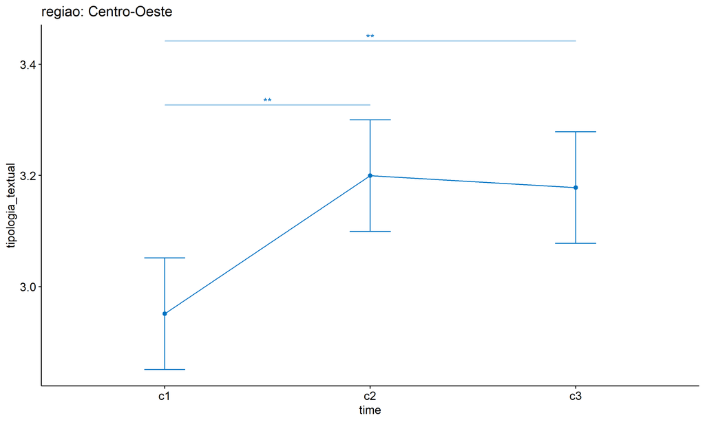

```r
emms.gg <- emms[which(emms$regiao == "Centro-Oeste"),]
if (nrow(emms.gg) > 0)
  ggline(emms.gg, x = "time", y = "emmean", color = "#0073C2FF", ylab = "tipologia_textual") +
    geom_errorbar(aes(ymin = conf.low, ymax = conf.high),
                  width = 0.2, color = "#0073C2FF") +
    stat_pvalue_manual(
      add_xy_position(pwc[which(pwc$regiao == "Centro-Oeste"),],
                      x = "time", fun = "mean_se"),
      hide.ns = T, color = "#0073C2FF", tip.length = F) +
    labs(title = "regiao: Centro-Oeste")+
    theme(legend.text = element_blank())
```

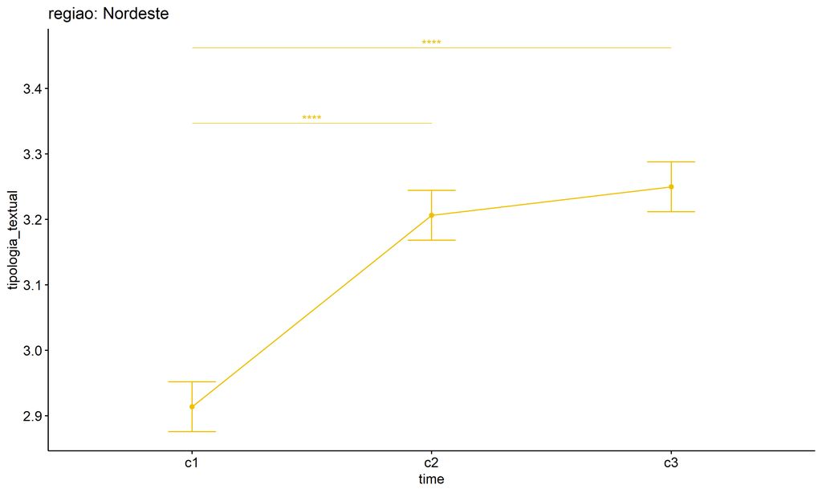

```r
emms.gg <- emms[which(emms$regiao == "Nordeste"),]
if (nrow(emms.gg) > 0)
  ggline(emms.gg, x = "time", y = "emmean", color = "#EFC000FF", ylab = "tipologia_textual") +
    geom_errorbar(aes(ymin = conf.low, ymax = conf.high),
                  width = 0.2, color = "#EFC000FF") +
    stat_pvalue_manual(
      add_xy_position(pwc[which(pwc$regiao == "Nordeste"),],
                      x = "time", fun = "mean_se"),
      hide.ns = T, color = "#EFC000FF", tip.length = F) +
    labs(title = "regiao: Nordeste")+
    theme(legend.text = element_blank())
```

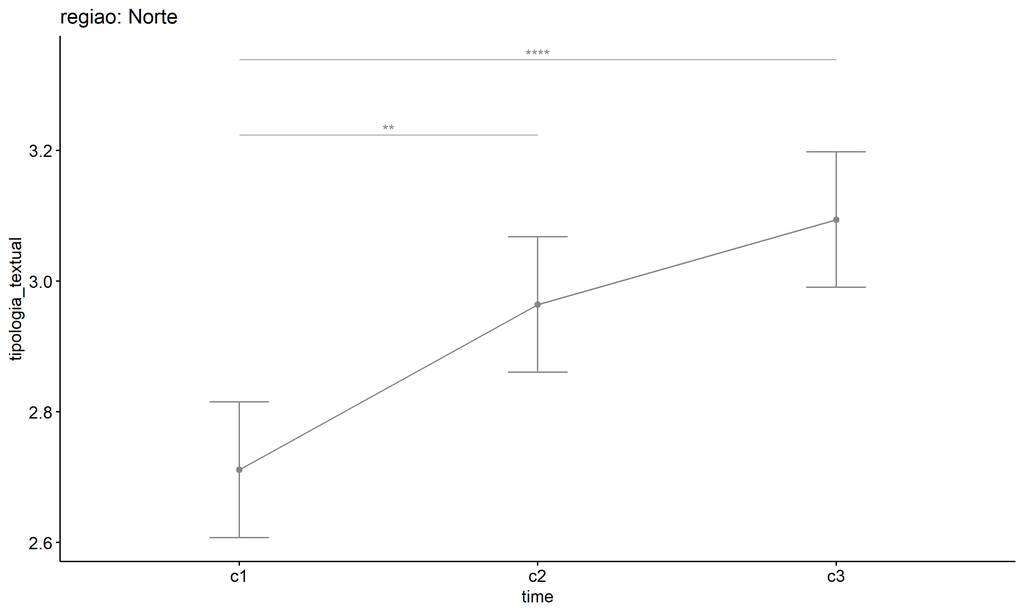

```r
emms.gg <- emms[which(emms$regiao == "Norte"),]
if (nrow(emms.gg) > 0)
  ggline(emms.gg, x = "time", y = "emmean", color = "#868686FF", ylab = "tipologia_textual") +
    geom_errorbar(aes(ymin = conf.low, ymax = conf.high),
                  width = 0.2, color = "#868686FF") +
    stat_pvalue_manual(
      add_xy_position(pwc[which(pwc$regiao == "Norte"),],
                      x = "time", fun = "mean_se"),
      hide.ns = T, color = "#868686FF", tip.length = F) +
    labs(title = "regiao: Norte")+
    theme(legend.text = element_blank())
```

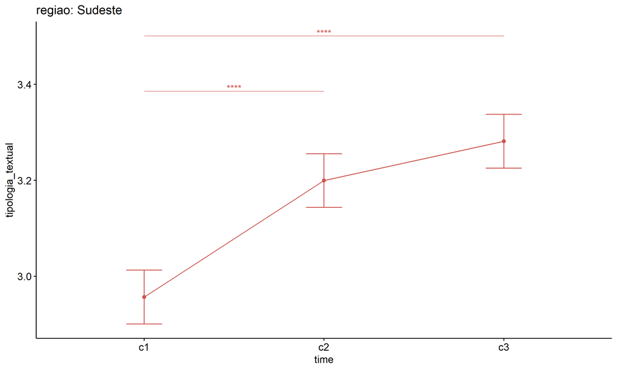

```r
emms.gg <- emms[which(emms$regiao == "Sudeste"),]
if (nrow(emms.gg) > 0)
  ggline(emms.gg, x = "time", y = "emmean", color = "#CD534CFF", ylab = "tipologia_textual") +
    geom_errorbar(aes(ymin = conf.low, ymax = conf.high),
                  width = 0.2, color = "#CD534CFF") +
    stat_pvalue_manual(
      add_xy_position(pwc[which(pwc$regiao == "Sudeste"),],
                      x = "time", fun = "mean_se"),
      hide.ns = T, color = "#CD534CFF", tip.length = F) +
    labs(title = "regiao: Sudeste")+
    theme(legend.text = element_blank())
```

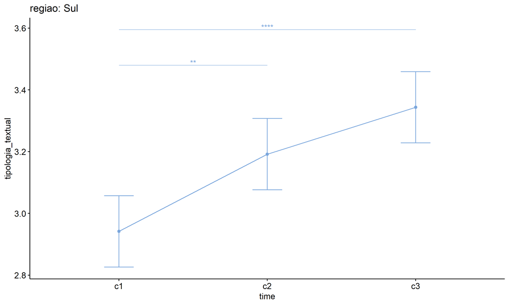

```r
emms.gg <- emms[which(emms$regiao == "Sul"),]
if (nrow(emms.gg) > 0)
  ggline(emms.gg, x = "time", y = "emmean", color = "#7AA6DCFF", ylab = "tipologia_textual") +
    geom_errorbar(aes(ymin = conf.low, ymax = conf.high),
                  width = 0.2, color = "#7AA6DCFF") +
    stat_pvalue_manual(
      add_xy_position(pwc[which(pwc$regiao == "Sul"),],
                      x = "time", fun = "mean_se"),
      hide.ns = T, color = "#7AA6DCFF", tip.length = F) +
    labs(title = "regiao: Sul")+
    theme(legend.text = element_blank())
```

## PairWise Computation after removing non.normal data

```r
if (length(non.ids) > 0)
  (pwc2 <- ldat2 %>% group_by(time) %>%
     emmeans_test(tipologia_textual ~ regiao, detailed = T, p.adjust.method = "bonferroni"))
```

```r
if (length(non.ids) > 0)
  (emms2 <- get_emmeans(pwc2))
```

```r
if (length(non.ids) > 0) {
  pwc2 <- add_xy_position(pwc2, x = "time", fun = "mean_se", dodge = 0.25)
  pd2 <- position_dodge(width = 0.25)

  ggline(emms2, x = "time", y = "emmean", color = "regiao",
         palette = c("#0073C2FF","#EFC000FF","#868686FF","#CD534CFF","#7AA6DCFF"),
         position = pd, ylab = "tipologia_textual") +
    geom_errorbar(aes(ymin = conf.low, ymax = conf.high, color = regiao),
                position = pd, width = 0.2) +
    stat_pvalue_manual(pwc2, hide.ns = T, tip.length = F, linetype = 1)
}
```

```r
if (length(non.ids) > 0)
  (pwc2 <- ldat2 %>% group_by(regiao) %>%
     emmeans_test(tipologia_textual ~ time, detailed = T, p.adjust.method = "bonferroni"))
```

```r
if (length(non.ids) > 0)
  (emms2 <- get_emmeans(pwc2))
```

```r
if (length(non.ids) > 0) {
  emms.gg <- emms2[which(emms2$regiao == "Centro-Oeste"),]
  if (nrow(emms.gg) > 0)
    ggline(emms.gg, x = "time", y = "emmean", color = "#0073C2FF", ylab = "tipologia_textual") +
    geom_errorbar(aes(ymin = conf.low, ymax = conf.high),
                  width = 0.2, color = "#0073C2FF") +
    stat_pvalue_manual(
      add_xy_position(pwc[which(pwc$regiao == "Centro-Oeste"),],
                      x = "time", fun = "mean_se"),
      hide.ns = T, color = "#0073C2FF", tip.length = F) +
    labs(title = "regiao: Centro-Oeste") +
    theme(legend.text = element_blank())
}
```

```r
if (length(non.ids) > 0) {
  emms.gg <- emms2[which(emms2$regiao == "Nordeste"),]
  if (nrow(emms.gg) > 0)
    ggline(emms.gg, x = "time", y = "emmean", color = "#EFC000FF", ylab = "tipologia_textual") +
    geom_errorbar(aes(ymin = conf.low, ymax = conf.high),
                  width = 0.2, color = "#EFC000FF") +
    stat_pvalue_manual(
      add_xy_position(pwc[which(pwc$regiao == "Nordeste"),],
                      x = "time", fun = "mean_se"),
      hide.ns = T, color = "#EFC000FF", tip.length = F) +
    labs(title = "regiao: Nordeste") +
    theme(legend.text = element_blank())
}
```

```r
if (length(non.ids) > 0) {
  emms.gg <- emms2[which(emms2$regiao == "Norte"),]
  if (nrow(emms.gg) > 0)
    ggline(emms.gg, x = "time", y = "emmean", color = "#868686FF", ylab = "tipologia_textual") +
    geom_errorbar(aes(ymin = conf.low, ymax = conf.high),
                  width = 0.2, color = "#868686FF") +
    stat_pvalue_manual(
      add_xy_position(pwc[which(pwc$regiao == "Norte"),],
                      x = "time", fun = "mean_se"),
      hide.ns = T, color = "#868686FF", tip.length = F) +
    labs(title = "regiao: Norte") +
    theme(legend.text = element_blank())
}
```

```r
if (length(non.ids) > 0) {
  emms.gg <- emms2[which(emms2$regiao == "Sudeste"),]
  if (nrow(emms.gg) > 0)
    ggline(emms.gg, x = "time", y = "emmean", color = "#CD534CFF", ylab = "tipologia_textual") +
    geom_errorbar(aes(ymin = conf.low, ymax = conf.high),
                  width = 0.2, color = "#CD534CFF") +
    stat_pvalue_manual(
      add_xy_position(pwc[which(pwc$regiao == "Sudeste"),],
                      x = "time", fun = "mean_se"),
      hide.ns = T, color = "#CD534CFF", tip.length = F) +
    labs(title = "regiao: Sudeste") +
    theme(legend.text = element_blank())
}
```

```r
if (length(non.ids) > 0) {
  emms.gg <- emms2[which(emms2$regiao == "Sul"),]
  if (nrow(emms.gg) > 0)
    ggline(emms.gg, x = "time", y = "emmean", color = "#7AA6DCFF", ylab = "tipologia_textual") +
    geom_errorbar(aes(ymin = conf.low, ymax = conf.high),
                  width = 0.2, color = "#7AA6DCFF") +
    stat_pvalue_manual(
      add_xy_position(pwc[which(pwc$regiao == "Sul"),],
                      x = "time", fun = "mean_se"),
      hide.ns = T, color = "#7AA6DCFF", tip.length = F) +
    labs(title = "regiao: Sul") +
    theme(legend.text = element_blank())
}
```

# ANOVA: tipologia_textual ~ time*porte + Error(id/time)

## Data Preparation

```r
data <- edat[,c("aluno_id","porte","ciclo","tipologia_textual")]
data <- data[data$ciclo %in% c("Primeiro Ciclo","Segundo Ciclo","Terceiro Ciclo"),]
data$ciclo <- factor(data$ciclo, c("Primeiro Ciclo","Segundo Ciclo","Terceiro Ciclo"))
data <- unique(data)

wdat <- spread(data, ciclo, tipologia_textual)
wdat <- wdat[complete.cases(wdat),]
colnames(wdat) <- c("id","porte","c1","c2","c3")

ldat <- gather(wdat, key = time, value = tipologia_textual, c1,c2,c3) %>%
  convert_as_factor(id, time)
ldat <- remove_group_data(ldat, "tipologia_textual", c("time", "porte"), n.limit = 30)
ldat$porte <- factor(ldat$porte, sort(unique(ldat$porte)))
```

### Check assumptions: Identifying Outliers

```r
outliers <- identify_outliers(group_by(ldat, time, porte), tipologia_textual)
(outliers <- outliers[outliers$is.extreme == T,])
```

```
## [1] porte             time              id                tipologia_textual is.outlier        is.extreme
## <0 rows> (or 0-length row.names)
```

| porte | time | id | tipologia_textual | is.outlier | is.extreme |
| --- | --- | --- | --- | --- | --- |

### Check assumptions: Normality Test

```r
(normality.df <- normality.test.per.groups(ldat, "tipologia_textual", c("time", "porte")))
```

```
##                  var          variable time                                        porte    n    skewness   kurtosis symmetry
## 1  tipologia_textual tipologia_textual   c1           Até 50 matrículas de escolarização   83 -0.24067226 -1.2139545      YES
## 2  tipologia_textual tipologia_textual   c1  Entre 201 e 500 matrículas de escolarização 1529  0.12438470 -1.3025678      YES
## 3  tipologia_textual tipologia_textual   c1 Entre 501 e 1000 matrículas de escolarização  618  0.05833388 -1.3212758      YES
## 4  tipologia_textual tipologia_textual   c1   Entre 51 e 200 matrículas de escolarização  473  0.23979331 -1.3263416      YES
## 5  tipologia_textual tipologia_textual   c1     Mais de 1000 matrículas de escolarização   70 -0.01882965 -1.5224739      YES
## 6  tipologia_textual tipologia_textual   c2           Até 50 matrículas de escolarização   83 -0.46737656 -1.2070847      YES
## 7  tipologia_textual tipologia_textual   c2  Entre 201 e 500 matrículas de escolarização 1529 -0.31164810 -1.2680548      YES
## 8  tipologia_textual tipologia_textual   c2 Entre 501 e 1000 matrículas de escolarização  618 -0.36404368 -1.2873685      YES
## 9  tipologia_textual tipologia_textual   c2   Entre 51 e 200 matrículas de escolarização  473 -0.36502895 -1.3693146      YES
## 10 tipologia_textual tipologia_textual   c2     Mais de 1000 matrículas de escolarização   70 -0.51864570 -1.4141512       NO
## 11 tipologia_textual tipologia_textual   c3           Até 50 matrículas de escolarização   83 -0.62643742 -0.9939617       NO
## 12 tipologia_textual tipologia_textual   c3  Entre 201 e 500 matrículas de escolarização 1529 -0.41580852 -1.1305859      YES
## 13 tipologia_textual tipologia_textual   c3 Entre 501 e 1000 matrículas de escolarização  618 -0.61207912 -1.0432664       NO
## 14 tipologia_textual tipologia_textual   c3   Entre 51 e 200 matrículas de escolarização  473 -0.46268719 -1.2978199      YES
```

[output cut: 17 more lines]

| var | variable | time | porte | n | skewness | kurtosis | symmetry | statistic | method | p | p.signif | normality |
| --- | --- | --- | --- | --- | --- | --- | --- | --- | --- | --- | --- | --- |
| tipologia_textual | tipologia_textual | c1 | Até 50 matrículas de escolarização | 83 | -0.241 | -1.214 | YES | 23.225 | D’Agostino | 0.000 | **** | NO |
| tipologia_textual | tipologia_textual | c1 | Entre 201 e 500 matrículas de escolarização | 1529 | 0.124 | -1.303 | YES | 3917.846 | D’Agostino | 0.000 | **** | - |
| tipologia_textual | tipologia_textual | c1 | Entre 501 e 1000 matrículas de escolarização | 618 | 0.058 | -1.321 | YES | 1329.700 | D’Agostino | 0.000 | **** | - |
| tipologia_textual | tipologia_textual | c1 | Entre 51 e 200 matrículas de escolarização | 473 | 0.240 | -1.326 | YES | 897.820 | D’Agostino | 0.000 | **** | - |
| tipologia_textual | tipologia_textual | c1 | Mais de 1000 matrículas de escolarização | 70 | -0.019 | -1.522 | YES | 76.479 | D’Agostino | 0.000 | **** | NO |
| tipologia_textual | tipologia_textual | c2 | Até 50 matrículas de escolarização | 83 | -0.467 | -1.207 | YES | 24.959 | D’Agostino | 0.000 | **** | NO |
| tipologia_textual | tipologia_textual | c2 | Entre 201 e 500 matrículas de escolarização | 1529 | -0.312 | -1.268 | YES | 2344.307 | D’Agostino | 0.000 | **** | - |
| tipologia_textual | tipologia_textual | c2 | Entre 501 e 1000 matrículas de escolarização | 618 | -0.364 | -1.287 | YES | 869.669 | D’Agostino | 0.000 | **** | - |
| tipologia_textual | tipologia_textual | c2 | Entre 51 e 200 matrículas de escolarização | 473 | -0.365 | -1.369 | YES | 1931.765 | D’Agostino | 0.000 | **** | - |
| tipologia_textual | tipologia_textual | c2 | Mais de 1000 matrículas de escolarização | 70 | -0.519 | -1.414 | NO | 45.378 | D’Agostino | 0.000 | **** | NO |
| tipologia_textual | tipologia_textual | c3 | Até 50 matrículas de escolarização | 83 | -0.626 | -0.994 | NO | 14.267 | D’Agostino | 0.001 | *** | NO |
| tipologia_textual | tipologia_textual | c3 | Entre 201 e 500 matrículas de escolarização | 1529 | -0.416 | -1.131 | YES | 744.258 | D’Agostino | 0.000 | **** | - |
| tipologia_textual | tipologia_textual | c3 | Entre 501 e 1000 matrículas de escolarização | 618 | -0.612 | -1.043 | NO | 187.090 | D’Agostino | 0.000 | **** | - |
| tipologia_textual | tipologia_textual | c3 | Entre 51 e 200 matrículas de escolarização | 473 | -0.463 | -1.298 | YES | 651.546 | D’Agostino | 0.000 | **** | - |
| tipologia_textual | tipologia_textual | c3 | Mais de 1000 matrículas de escolarização | 70 | -0.052 | -1.795 | YES | 1870.512 | D’Agostino | 0.000 | **** | NO |

```r
(non.ids <- unique(do.call(
  c, lapply(which(normality.df$normality == 'NO'), FUN = function(i) {
  idx = which(ldat$time == normality.df$time[i] &
                ldat$porte == normality.df$porte[i])
  getNonNormal(ldat$"tipologia_textual"[idx], ldat$id[idx])
}))))
```

```
##   [1] "ZG9XMMLDSBGcLPgDh0pb" "0bDRQAUpq62jJm9vcptp" "ADdqL4oAf1WRDDiOJwkj" "vgyELVyPKZx09yEhXnEW" "aONYcyIz9jdWo9UGBKG0"
##   [6] "UgYoK4SY4Mtbi2xic7Rv" "tgU0kaZP9pRnxah0S6uy" "T2uwQcqrdXIilUfr6OCA" "Bf6X3bHfDcJsJ9YdyqJH" "d7fkDImOtMuiednMD3E1"
##  [11] "i84ihNmDZFogrHoxo3Im" "ygCWEOBsngyfEt5hGLmw" "YYk7kVbKPFXpi3VNYSOH" "1DlydHhFt2IkhBETPR4s" "YUmfeTL6DDynUZSxTKc3"
##  [16] "2eTy4XnB3HL1Lip3fbQn" "8J6zVzXwczhDoIz6ZH9H" "y744fkAaj9kAhrO7WEmG" "C1zjWQ3pmwKkP6zRXwwe" "X8sa3nNhiwDUJH6wF7Ha"
##  [21] "fbG1AkJFlVZGXT8Fznxj" "UkMXrk8JLJryPIlwTUa2" "FPMFe1s9iSBxoJXvsTAR" "HSX3YOtyIg0ZOh76zqlN" "uB4uyNIZ6LxFYhb9JhLg"
##  [26] "nZWlEakTBujRX1QWHj37" "twslhfIr8UZf4GsZbRoY" "OULhcpjSyljgpMZP22Ar" "OyqOutO5F9qOBjOC8hjG" "sm3UUkWTyL97enxw2JbY"
##  [31] "nKMTyMsfm4eOVhncYSKR" "kZlm8iMhlqv4fNmAx0fG" "pJbc9u9ZPKVj4ttAwF9y" "pqXkPZEqOMf2xM8dbV6d" "kFTP8a3fnEqe2CzUIbPt"
##  [36] "Kb2dP0jiNWmYejxfbhLa" "RVaGBDw53Pq5sv8Rv3f1" "iyJp1j8H7ijZjVKqhnpU" "I519hq7xEO1Hoh2ibKjC" "SC3MjpxyURHXOGZUgVSZ"
##  [41] "hzUS30DyaGMI0MoQIp0n" "sPlCk5k5bGSTg4uIsOGE" "Zd0PsCueY8uUv5kZj7tr" "Y3XBjvabRWZddSn1PBSa" "xq4dYP59DlllbZEPXy4Y"
##  [46] "wzpfVmENuwkQHmrYv7Vs" "wmMgYtTDXMi7lGWVukYs" "V98ktNWyqK4ADAVVpxer" "TLeQnhQ2DIQj5KoUID1J" "z0H60Zv5mbFaxB0nRZS9"
##  [51] "YFJYxK0iPG5KhhI763RV" "w1UKSuycUulqH56YxN5l" "2rhshpLTwB8n26xWIGLY" "ucifu1IbqUXkNcZenoiF" "sTippTVv5SmFwvxR2sfF"
##  [56] "SoGp0lIq4pc911ctmbB1" "6uO7HtHYJP6LkaXhdG2j" "ScTMK6tLs91Uic7qY4rP" "NuWkLkYYRuA125qcnk4r" "NGCQanKdT1it8UlBNgmW"
##  [61] "Nd63Mjq1veJlg4HVTjuL" "i3TcORTWUFCvTPk4psJY" "Aar1QFPu6EAVyD9BDnA3" "kxDlIW2yUzDrEogK8TaZ" "ijRxNrSrW0oX4pjrOD7X"
##  [66] "HM6lELrDJUQlU8CLhlxB" "zpmhcXzEeOxKL6kXYe02" "z2bvFgOm1tRPAL3buvNQ" "yersdkzgN1t3oO7zNNNA" "xPKsXOtiZGS6KJVc4KT3"
##  [71] "xK8qTeI9z4KzyJVqLhM8" "xAo0TzCEx1bIrmjqKgbj" "wqLc84Q7Y7B988JtGyXd" "tlnYYlL4uNGaw9gq7z02" "8QJX5P6FygYXzjqA5njF"
##  [76] "sNrMxxYCTthTxBfrZZuD" "PdGP3GVwxljvKeW07xkS" "nFCWCX4KlAfWmHKc43rd" "MvrXfUanbVWpI0EsMTR6" "MdfO8FPiIZis82vN8Qvn"
##  [81] "ltYX0dLBB2brT2djXB5i" "BFW9EcP6GxS4r3JYDkkn" "LQwlHt8gNJ5CtCYBWgCr" "kxdgoHtp7sPis1wwXN9e" "hv8yuaYbgJIx5H3apsBZ"
##  [86] "hPDFOwmBzlak2RcrNhzR" "hhm3dmBw9wzrZNM837xU" "9k9BI8mCq3fddmKjDwxN" "Cpw7toBsqavz223WZOD6" "NYutDluJkRSft54Q6Dsk"
##  [91] "i0dLtUz8nm5JgjV0jkAL" "M7T19VXht72RWQicQ4oB" "M2Ym0tMeXAO21tD9is8t" "gdYDn3FmbtplSEE6Ttms" "EoSBVqfBw7krU0Sy514T"
##  [96] "doi9DyLKXwHMkMGgBLyY" "anmGFIGq40zqZcqOEcal" "AANHvkEfT5JbfSUOPRXs" "8SQzDjxkh749gTXUJN73" "w7548cNc0knlzDezHzBq"
## [101] "QlXsQ3d9CVjdZHyW2pLC" "xLpKyTYqyZhy4OOTSCAv" "QEFho4YwQCAlMwhIddNB" "mbcncvg5dOFa9ZRsRhZf" "L0gX2yfP95da5eDy6w4E"
## [106] "krjfBBPR9DydnBgQSQ1n" "iutpBZMAtM92qcbyCDHB" "ZHNhk1zpmerLG8ISdloo" "VNQYsv3kH0OTOqJH3yYT" "CiV1upa4BM58OvTZsu01"
## [111] "nrctDKnNeBPAy3FWmN34" "bnhrGtK2gNr4ms56nqKJ"
```

```r
if (length(non.ids) > 0)
  ldat2 <- ldat[!ldat$id %in% non.ids,]
```

### Summary Statistics

```r
(sdat <- ldat %>% group_by(time, porte) %>%
   get_summary_stats(tipologia_textual, type = "mean_sd"))
```

```
## # A tibble: 15 × 6
##    porte                                        time  variable              n  mean    sd
##    <fct>                                        <fct> <fct>             <dbl> <dbl> <dbl>
##  1 Até 50 matrículas de escolarização           c1    tipologia_textual    83  3.09 0.716
##  2 Entre 201 e 500 matrículas de escolarização  c1    tipologia_textual  1529  2.92 0.741
##  3 Entre 501 e 1000 matrículas de escolarização c1    tipologia_textual   618  2.93 0.737
##  4 Entre 51 e 200 matrículas de escolarização   c1    tipologia_textual   473  2.84 0.749
##  5 Mais de 1000 matrículas de escolarização     c1    tipologia_textual    70  2.99 0.801
##  6 Até 50 matrículas de escolarização           c2    tipologia_textual    83  3.26 0.754
##  7 Entre 201 e 500 matrículas de escolarização  c2    tipologia_textual  1529  3.18 0.753
##  8 Entre 501 e 1000 matrículas de escolarização c2    tipologia_textual   618  3.19 0.767
##  9 Entre 51 e 200 matrículas de escolarização   c2    tipologia_textual   473  3.18 0.793
## 10 Mais de 1000 matrículas de escolarização     c2    tipologia_textual    70  3.26 0.842
## 11 Até 50 matrículas de escolarização           c3    tipologia_textual    83  3.35 0.727
## 12 Entre 201 e 500 matrículas de escolarização  c3    tipologia_textual  1529  3.22 0.733
## 13 Entre 501 e 1000 matrículas de escolarização c3    tipologia_textual   618  3.32 0.753
## 14 Entre 51 e 200 matrículas de escolarização   c3    tipologia_textual   473  3.24 0.785
## 15 Mais de 1000 matrículas de escolarização     c3    tipologia_textual    70  3.04 0.892
```

| porte | time | variable | n | mean | sd |
| --- | --- | --- | --- | --- | --- |
| Até 50 matrículas de escolarização | c1 | tipologia_textual | 83 | 3.090 | 0.716 |
| Entre 201 e 500 matrículas de escolarização | c1 | tipologia_textual | 1529 | 2.918 | 0.741 |
| Entre 501 e 1000 matrículas de escolarização | c1 | tipologia_textual | 618 | 2.929 | 0.737 |
| Entre 51 e 200 matrículas de escolarização | c1 | tipologia_textual | 473 | 2.841 | 0.749 |
| Mais de 1000 matrículas de escolarização | c1 | tipologia_textual | 70 | 2.993 | 0.801 |
| Até 50 matrículas de escolarização | c2 | tipologia_textual | 83 | 3.265 | 0.754 |
| Entre 201 e 500 matrículas de escolarização | c2 | tipologia_textual | 1529 | 3.177 | 0.753 |
| Entre 501 e 1000 matrículas de escolarização | c2 | tipologia_textual | 618 | 3.189 | 0.767 |
| Entre 51 e 200 matrículas de escolarização | c2 | tipologia_textual | 473 | 3.184 | 0.793 |
| Mais de 1000 matrículas de escolarização | c2 | tipologia_textual | 70 | 3.257 | 0.842 |
| Até 50 matrículas de escolarização | c3 | tipologia_textual | 83 | 3.349 | 0.727 |
| Entre 201 e 500 matrículas de escolarização | c3 | tipologia_textual | 1529 | 3.224 | 0.733 |
| Entre 501 e 1000 matrículas de escolarização | c3 | tipologia_textual | 618 | 3.315 | 0.753 |
| Entre 51 e 200 matrículas de escolarização | c3 | tipologia_textual | 473 | 3.241 | 0.785 |
| Mais de 1000 matrículas de escolarização | c3 | tipologia_textual | 70 | 3.043 | 0.892 |

```r
if (length(non.ids) > 0)
  (sdat <- ldat2 %>% group_by(time, porte) %>%
      get_summary_stats(tipologia_textual, type = "mean_sd"))
```

```
## # A tibble: 15 × 6
##    porte                                        time  variable              n  mean     sd
##    <fct>                                        <fct> <fct>             <dbl> <dbl>  <dbl>
##  1 Até 50 matrículas de escolarização           c1    tipologia_textual    40  3.09  0.678
##  2 Entre 201 e 500 matrículas de escolarização  c1    tipologia_textual  1529  2.92  0.741
##  3 Entre 501 e 1000 matrículas de escolarização c1    tipologia_textual   618  2.93  0.737
##  4 Entre 51 e 200 matrículas de escolarização   c1    tipologia_textual   473  2.84  0.749
##  5 Mais de 1000 matrículas de escolarização     c1    tipologia_textual     1  3    NA
##  6 Até 50 matrículas de escolarização           c2    tipologia_textual    40  3.15  0.7
##  7 Entre 201 e 500 matrículas de escolarização  c2    tipologia_textual  1529  3.18  0.753
##  8 Entre 501 e 1000 matrículas de escolarização c2    tipologia_textual   618  3.19  0.767
##  9 Entre 51 e 200 matrículas de escolarização   c2    tipologia_textual   473  3.18  0.793
## 10 Mais de 1000 matrículas de escolarização     c2    tipologia_textual     1  4    NA
## 11 Até 50 matrículas de escolarização           c3    tipologia_textual    40  3.16  0.644
## 12 Entre 201 e 500 matrículas de escolarização  c3    tipologia_textual  1529  3.22  0.733
## 13 Entre 501 e 1000 matrículas de escolarização c3    tipologia_textual   618  3.32  0.753
## 14 Entre 51 e 200 matrículas de escolarização   c3    tipologia_textual   473  3.24  0.785
## 15 Mais de 1000 matrículas de escolarização     c3    tipologia_textual     1  4    NA
```

| porte | time | variable | n | mean | sd |
| --- | --- | --- | --- | --- | --- |
| Até 50 matrículas de escolarização | c1 | tipologia_textual | 40 | 3.087 | 0.678 |
| Entre 201 e 500 matrículas de escolarização | c1 | tipologia_textual | 1529 | 2.918 | 0.741 |
| Entre 501 e 1000 matrículas de escolarização | c1 | tipologia_textual | 618 | 2.929 | 0.737 |
| Entre 51 e 200 matrículas de escolarização | c1 | tipologia_textual | 473 | 2.841 | 0.749 |
| Mais de 1000 matrículas de escolarização | c1 | tipologia_textual | 1 | 3.000 | NA |
| Até 50 matrículas de escolarização | c2 | tipologia_textual | 40 | 3.150 | 0.700 |
| Entre 201 e 500 matrículas de escolarização | c2 | tipologia_textual | 1529 | 3.177 | 0.753 |
| Entre 501 e 1000 matrículas de escolarização | c2 | tipologia_textual | 618 | 3.189 | 0.767 |
| Entre 51 e 200 matrículas de escolarização | c2 | tipologia_textual | 473 | 3.184 | 0.793 |
| Mais de 1000 matrículas de escolarização | c2 | tipologia_textual | 1 | 4.000 | NA |
| Até 50 matrículas de escolarização | c3 | tipologia_textual | 40 | 3.163 | 0.644 |
| Entre 201 e 500 matrículas de escolarização | c3 | tipologia_textual | 1529 | 3.224 | 0.733 |
| Entre 501 e 1000 matrículas de escolarização | c3 | tipologia_textual | 618 | 3.315 | 0.753 |
| Entre 51 e 200 matrículas de escolarização | c3 | tipologia_textual | 473 | 3.241 | 0.785 |
| Mais de 1000 matrículas de escolarização | c3 | tipologia_textual | 1 | 4.000 | NA |

## ANOVA Computation

```r
(res.aov <- anova_test(ldat, dv = tipologia_textual, wid = id, between = porte, within = time))
```

```
## ANOVA Table (type III tests)
##
## $ANOVA
##       Effect DFn  DFd      F                       p p<.05   ges
## 1      porte   4 2768  2.114 0.075999999999999998113       0.001
## 2       time   2 5536 42.801 0.000000000000000000358     * 0.008
## 3 porte:time   8 5536  2.045 0.037999999999999999056     * 0.002
##
## $`Mauchly's Test for Sphericity`
##       Effect     W     p p<.05
## 1       time 0.998 0.125
## 2 porte:time 0.998 0.125
##
## $`Sphericity Corrections`
##       Effect   GGe       DF[GG]                   p[GG] p[GG]<.05   HFe        DF[HF]                   p[HF] p[HF]<.05
## 1       time 0.999    2, 5527.7 0.000000000000000000379         * 0.999    2, 5531.69 0.000000000000000000369         *
## 2 porte:time 0.999 7.99, 5527.7 0.037999999999999999056         * 0.999 7.99, 5531.69 0.037999999999999999056         *
```

| Effect | DFn | DFd | F | p | p<.05 | ges |
| --- | --- | --- | --- | --- | --- | --- |
| porte | 4 | 2768 | 2.114 | 0.076 |  | 0.001 |
| time | 2 | 5536 | 42.801 | 0.000 | * | 0.008 |
| porte:time | 8 | 5536 | 2.045 | 0.038 | * | 0.002 |

| Effect | W | p | p<.05 |
| --- | --- | --- | --- |
| time | 0.998 | 0.125 |  |
| porte:time | 0.998 | 0.125 |  |

| Effect | GGe | DF[GG] | p[GG] | p[GG]<.05 | HFe | DF[HF] | p[HF] | p[HF]<.05 |
| --- | --- | --- | --- | --- | --- | --- | --- | --- |
| time | 0.999 | 2, 5527.7 | 0.000 | * | 0.999 | 2, 5531.69 | 0.000 | * |
| porte:time | 0.999 | 7.99, 5527.7 | 0.038 | * | 0.999 | 7.99, 5531.69 | 0.038 | * |

## ANOVA Computation after removing non.normal data

```r
if (length(non.ids) > 0)
  (res.aov2 <- anova_test(ldat2, dv = tipologia_textual, wid = id, between = porte , within = time))
```

```
## ANOVA Table (type III tests)
##
## $ANOVA
##       Effect DFn  DFd     F     p p<.05      ges
## 1      porte   4 2656 1.239 0.292       0.000846
## 2       time   2 5312 2.969 0.051       0.000610
## 3 porte:time   8 5312 1.441 0.174       0.001000
##
## $`Mauchly's Test for Sphericity`
##       Effect     W     p p<.05
## 1       time 0.998 0.097
## 2 porte:time 0.998 0.097
##
## $`Sphericity Corrections`
##       Effect   GGe        DF[GG] p[GG] p[GG]<.05   HFe        DF[HF] p[HF] p[HF]<.05
## 1       time 0.998    2, 5302.71 0.052           0.999    2, 5306.69 0.052
## 2 porte:time 0.998 7.99, 5302.71 0.174           0.999 7.99, 5306.69 0.174
```

| Effect | DFn | DFd | F | p | p<.05 | ges |
| --- | --- | --- | --- | --- | --- | --- |
| porte | 4 | 2656 | 1.239 | 0.292 |  | 0.001 |
| time | 2 | 5312 | 2.969 | 0.051 |  | 0.001 |
| porte:time | 8 | 5312 | 1.441 | 0.174 |  | 0.001 |

| Effect | W | p | p<.05 |
| --- | --- | --- | --- |
| time | 0.998 | 0.097 |  |
| porte:time | 0.998 | 0.097 |  |

| Effect | GGe | DF[GG] | p[GG] | p[GG]<.05 | HFe | DF[HF] | p[HF] | p[HF]<.05 |
| --- | --- | --- | --- | --- | --- | --- | --- | --- |
| time | 0.998 | 2, 5302.71 | 0.052 |  | 0.999 | 2, 5306.69 | 0.052 |  |
| porte:time | 0.998 | 7.99, 5302.71 | 0.174 |  | 0.999 | 7.99, 5306.69 | 0.174 |  |

## PairWise Computation

```r
(pwc <- ldat %>% group_by(time) %>%
   emmeans_test(tipologia_textual ~ porte, detailed = T, p.adjust.method = "bonferroni"))
```

```
## # A tibble: 30 × 15
##    time  term  .y.       group1 group2 null.value estimate     se    df conf.low conf.high statistic       p  p.adj p.adj.signif
##  * <fct> <chr> <chr>     <chr>  <chr>       <dbl>    <dbl>  <dbl> <dbl>    <dbl>     <dbl>     <dbl>   <dbl>  <dbl> <chr>
##  1 c1    porte tipologi… Até 5… Entre…          0   0.172  0.0849  8304  0.00611    0.339      2.03  0.0422  0.422  ns
##  2 c1    porte tipologi… Até 5… Entre…          0   0.162  0.0880  8304 -0.0110     0.334      1.84  0.0665  0.665  ns
##  3 c1    porte tipologi… Até 5… Entre…          0   0.249  0.0896  8304  0.0732     0.425      2.78  0.00549 0.0549 ns
##  4 c1    porte tipologi… Até 5… Mais …          0   0.0975 0.122   8304 -0.142      0.337      0.798 0.425   1      ns
##  5 c1    porte tipologi… Entre… Entre…          0  -0.0109 0.0359  8304 -0.0813     0.0594    -0.305 0.761   1      ns
##  6 c1    porte tipologi… Entre… Entre…          0   0.0764 0.0396  8304 -0.00124    0.154      1.93  0.0538  0.538  ns
##  7 c1    porte tipologi… Entre… Mais …          0  -0.0750 0.0921  8304 -0.255      0.105     -0.815 0.415   1      ns
##  8 c1    porte tipologi… Entre… Entre…          0   0.0874 0.0460  8304 -0.00282    0.178      1.90  0.0576  0.576  ns
##  9 c1    porte tipologi… Entre… Mais …          0  -0.0641 0.0950  8304 -0.250      0.122     -0.674 0.500   1      ns
## 10 c1    porte tipologi… Entre… Mais …          0  -0.151  0.0964  8304 -0.340      0.0376    -1.57  0.116   1      ns
## # ℹ 20 more rows
```

| time | term | .y. | group1 | group2 | null.value | estimate | se | df | conf.low | conf.high | statistic | p | p.adj | p.adj.signif |
| --- | --- | --- | --- | --- | --- | --- | --- | --- | --- | --- | --- | --- | --- | --- |
| c1 | porte | tipologia_textual | Até 50 matrículas de escolarização | Entre 201 e 500 matrículas de escolarização | 0 | 0.172 | 0.085 | 8304 | 0.006 | 0.339 | 2.032 | 0.042 | 0.422 | ns |
| c1 | porte | tipologia_textual | Até 50 matrículas de escolarização | Entre 501 e 1000 matrículas de escolarização | 0 | 0.162 | 0.088 | 8304 | -0.011 | 0.334 | 1.835 | 0.067 | 0.665 | ns |
| c1 | porte | tipologia_textual | Até 50 matrículas de escolarização | Entre 51 e 200 matrículas de escolarização | 0 | 0.249 | 0.090 | 8304 | 0.073 | 0.425 | 2.777 | 0.005 | 0.055 | ns |
| c1 | porte | tipologia_textual | Até 50 matrículas de escolarização | Mais de 1000 matrículas de escolarização | 0 | 0.098 | 0.122 | 8304 | -0.142 | 0.337 | 0.798 | 0.425 | 1.000 | ns |
| c1 | porte | tipologia_textual | Entre 201 e 500 matrículas de escolarização | Entre 501 e 1000 matrículas de escolarização | 0 | -0.011 | 0.036 | 8304 | -0.081 | 0.059 | -0.305 | 0.761 | 1.000 | ns |
| c1 | porte | tipologia_textual | Entre 201 e 500 matrículas de escolarização | Entre 51 e 200 matrículas de escolarização | 0 | 0.076 | 0.040 | 8304 | -0.001 | 0.154 | 1.929 | 0.054 | 0.538 | ns |
| c1 | porte | tipologia_textual | Entre 201 e 500 matrículas de escolarização | Mais de 1000 matrículas de escolarização | 0 | -0.075 | 0.092 | 8304 | -0.255 | 0.105 | -0.815 | 0.415 | 1.000 | ns |
| c1 | porte | tipologia_textual | Entre 501 e 1000 matrículas de escolarização | Entre 51 e 200 matrículas de escolarização | 0 | 0.087 | 0.046 | 8304 | -0.003 | 0.178 | 1.899 | 0.058 | 0.576 | ns |
| c1 | porte | tipologia_textual | Entre 501 e 1000 matrículas de escolarização | Mais de 1000 matrículas de escolarização | 0 | -0.064 | 0.095 | 8304 | -0.250 | 0.122 | -0.674 | 0.500 | 1.000 | ns |
| c1 | porte | tipologia_textual | Entre 51 e 200 matrículas de escolarização | Mais de 1000 matrículas de escolarização | 0 | -0.151 | 0.096 | 8304 | -0.340 | 0.038 | -1.570 | 0.116 | 1.000 | ns |
| c2 | porte | tipologia_textual | Até 50 matrículas de escolarização | Entre 201 e 500 matrículas de escolarização | 0 | 0.088 | 0.085 | 8304 | -0.078 | 0.255 | 1.040 | 0.298 | 1.000 | ns |
| c2 | porte | tipologia_textual | Até 50 matrículas de escolarização | Entre 501 e 1000 matrículas de escolarização | 0 | 0.076 | 0.088 | 8304 | -0.096 | 0.249 | 0.866 | 0.386 | 1.000 | ns |
| c2 | porte | tipologia_textual | Até 50 matrículas de escolarização | Entre 51 e 200 matrículas de escolarização | 0 | 0.081 | 0.090 | 8304 | -0.095 | 0.256 | 0.899 | 0.369 | 1.000 | ns |
| c2 | porte | tipologia_textual | Até 50 matrículas de escolarização | Mais de 1000 matrículas de escolarização | 0 | 0.008 | 0.122 | 8304 | -0.232 | 0.247 | 0.065 | 0.948 | 1.000 | ns |
| c2 | porte | tipologia_textual | Entre 201 e 500 matrículas de escolarização | Entre 501 e 1000 matrículas de escolarização | 0 | -0.012 | 0.036 | 8304 | -0.082 | 0.058 | -0.334 | 0.739 | 1.000 | ns |
| c2 | porte | tipologia_textual | Entre 201 e 500 matrículas de escolarização | Entre 51 e 200 matrículas de escolarização | 0 | -0.008 | 0.040 | 8304 | -0.085 | 0.070 | -0.193 | 0.847 | 1.000 | ns |
| c2 | porte | tipologia_textual | Entre 201 e 500 matrículas de escolarização | Mais de 1000 matrículas de escolarização | 0 | -0.080 | 0.092 | 8304 | -0.261 | 0.100 | -0.873 | 0.383 | 1.000 | ns |
| c2 | porte | tipologia_textual | Entre 501 e 1000 matrículas de escolarização | Entre 51 e 200 matrículas de escolarização | 0 | 0.004 | 0.046 | 8304 | -0.086 | 0.095 | 0.094 | 0.925 | 1.000 | ns |
| c2 | porte | tipologia_textual | Entre 501 e 1000 matrículas de escolarização | Mais de 1000 matrículas de escolarização | 0 | -0.068 | 0.095 | 8304 | -0.255 | 0.118 | -0.720 | 0.472 | 1.000 | ns |
| c2 | porte | tipologia_textual | Entre 51 e 200 matrículas de escolarização | Mais de 1000 matrículas de escolarização | 0 | -0.073 | 0.096 | 8304 | -0.262 | 0.116 | -0.754 | 0.451 | 1.000 | ns |
| c3 | porte | tipologia_textual | Até 50 matrículas de escolarização | Entre 201 e 500 matrículas de escolarização | 0 | 0.126 | 0.085 | 8304 | -0.041 | 0.292 | 1.480 | 0.139 | 1.000 | ns |
| c3 | porte | tipologia_textual | Até 50 matrículas de escolarização | Entre 501 e 1000 matrículas de escolarização | 0 | 0.035 | 0.088 | 8304 | -0.138 | 0.207 | 0.394 | 0.694 | 1.000 | ns |
| c3 | porte | tipologia_textual | Até 50 matrículas de escolarização | Entre 51 e 200 matrículas de escolarização | 0 | 0.108 | 0.090 | 8304 | -0.067 | 0.284 | 1.209 | 0.227 | 1.000 | ns |
| c3 | porte | tipologia_textual | Até 50 matrículas de escolarização | Mais de 1000 matrículas de escolarização | 0 | 0.307 | 0.122 | 8304 | 0.067 | 0.546 | 2.508 | 0.012 | 0.122 | ns |
| c3 | porte | tipologia_textual | Entre 201 e 500 matrículas de escolarização | Entre 501 e 1000 matrículas de escolarização | 0 | -0.091 | 0.036 | 8304 | -0.161 | -0.021 | -2.533 | 0.011 | 0.113 | ns |
| c3 | porte | tipologia_textual | Entre 201 e 500 matrículas de escolarização | Entre 51 e 200 matrículas de escolarização | 0 | -0.017 | 0.040 | 8304 | -0.095 | 0.060 | -0.435 | 0.664 | 1.000 | ns |
| c3 | porte | tipologia_textual | Entre 201 e 500 matrículas de escolarização | Mais de 1000 matrículas de escolarização | 0 | 0.181 | 0.092 | 8304 | 0.000 | 0.361 | 1.966 | 0.049 | 0.494 | ns |
| c3 | porte | tipologia_textual | Entre 501 e 1000 matrículas de escolarização | Entre 51 e 200 matrículas de escolarização | 0 | 0.074 | 0.046 | 8304 | -0.016 | 0.164 | 1.602 | 0.109 | 1.000 | ns |
| c3 | porte | tipologia_textual | Entre 501 e 1000 matrículas de escolarização | Mais de 1000 matrículas de escolarização | 0 | 0.272 | 0.095 | 8304 | 0.086 | 0.458 | 2.863 | 0.004 | 0.042 | * |
| c3 | porte | tipologia_textual | Entre 51 e 200 matrículas de escolarização | Mais de 1000 matrículas de escolarização | 0 | 0.198 | 0.096 | 8304 | 0.009 | 0.387 | 2.055 | 0.040 | 0.399 | ns |

```r
(emms <- get_emmeans(pwc))
```

```
## # A tibble: 15 × 8
##    time  porte                                        emmean     se    df conf.low conf.high method
##    <fct> <fct>                                         <dbl>  <dbl> <dbl>    <dbl>     <dbl> <chr>
##  1 c1    Até 50 matrículas de escolarização             3.09 0.0827  8304     2.93      3.25 Emmeans test
##  2 c1    Entre 201 e 500 matrículas de escolarização    2.92 0.0193  8304     2.88      2.96 Emmeans test
##  3 c1    Entre 501 e 1000 matrículas de escolarização   2.93 0.0303  8304     2.87      2.99 Emmeans test
##  4 c1    Entre 51 e 200 matrículas de escolarização     2.84 0.0346  8304     2.77      2.91 Emmeans test
##  5 c1    Mais de 1000 matrículas de escolarização       2.99 0.0900  8304     2.82      3.17 Emmeans test
##  6 c2    Até 50 matrículas de escolarização             3.27 0.0827  8304     3.10      3.43 Emmeans test
##  7 c2    Entre 201 e 500 matrículas de escolarização    3.18 0.0193  8304     3.14      3.21 Emmeans test
##  8 c2    Entre 501 e 1000 matrículas de escolarização   3.19 0.0303  8304     3.13      3.25 Emmeans test
##  9 c2    Entre 51 e 200 matrículas de escolarização     3.18 0.0346  8304     3.12      3.25 Emmeans test
## 10 c2    Mais de 1000 matrículas de escolarização       3.26 0.0900  8304     3.08      3.43 Emmeans test
## 11 c3    Até 50 matrículas de escolarização             3.35 0.0827  8304     3.19      3.51 Emmeans test
## 12 c3    Entre 201 e 500 matrículas de escolarização    3.22 0.0193  8304     3.19      3.26 Emmeans test
## 13 c3    Entre 501 e 1000 matrículas de escolarização   3.31 0.0303  8304     3.26      3.37 Emmeans test
## 14 c3    Entre 51 e 200 matrículas de escolarização     3.24 0.0346  8304     3.17      3.31 Emmeans test
## 15 c3    Mais de 1000 matrículas de escolarização       3.04 0.0900  8304     2.87      3.22 Emmeans test
```

| time | porte | emmean | se | df | conf.low | conf.high | method |
| --- | --- | --- | --- | --- | --- | --- | --- |
| c1 | Até 50 matrículas de escolarização | 3.090 | 0.083 | 8304 | 2.928 | 3.252 | Emmeans test |
| c1 | Entre 201 e 500 matrículas de escolarização | 2.918 | 0.019 | 8304 | 2.880 | 2.956 | Emmeans test |
| c1 | Entre 501 e 1000 matrículas de escolarização | 2.929 | 0.030 | 8304 | 2.869 | 2.988 | Emmeans test |
| c1 | Entre 51 e 200 matrículas de escolarização | 2.841 | 0.035 | 8304 | 2.774 | 2.909 | Emmeans test |
| c1 | Mais de 1000 matrículas de escolarização | 2.993 | 0.090 | 8304 | 2.816 | 3.169 | Emmeans test |
| c2 | Até 50 matrículas de escolarização | 3.265 | 0.083 | 8304 | 3.103 | 3.427 | Emmeans test |
| c2 | Entre 201 e 500 matrículas de escolarização | 3.177 | 0.019 | 8304 | 3.139 | 3.215 | Emmeans test |
| c2 | Entre 501 e 1000 matrículas de escolarização | 3.189 | 0.030 | 8304 | 3.129 | 3.248 | Emmeans test |
| c2 | Entre 51 e 200 matrículas de escolarização | 3.184 | 0.035 | 8304 | 3.117 | 3.252 | Emmeans test |
| c2 | Mais de 1000 matrículas de escolarização | 3.257 | 0.090 | 8304 | 3.081 | 3.434 | Emmeans test |
| c3 | Até 50 matrículas de escolarização | 3.349 | 0.083 | 8304 | 3.187 | 3.511 | Emmeans test |
| c3 | Entre 201 e 500 matrículas de escolarização | 3.224 | 0.019 | 8304 | 3.186 | 3.262 | Emmeans test |
| c3 | Entre 501 e 1000 matrículas de escolarização | 3.315 | 0.030 | 8304 | 3.255 | 3.374 | Emmeans test |
| c3 | Entre 51 e 200 matrículas de escolarização | 3.241 | 0.035 | 8304 | 3.173 | 3.309 | Emmeans test |
| c3 | Mais de 1000 matrículas de escolarização | 3.043 | 0.090 | 8304 | 2.866 | 3.219 | Emmeans test |

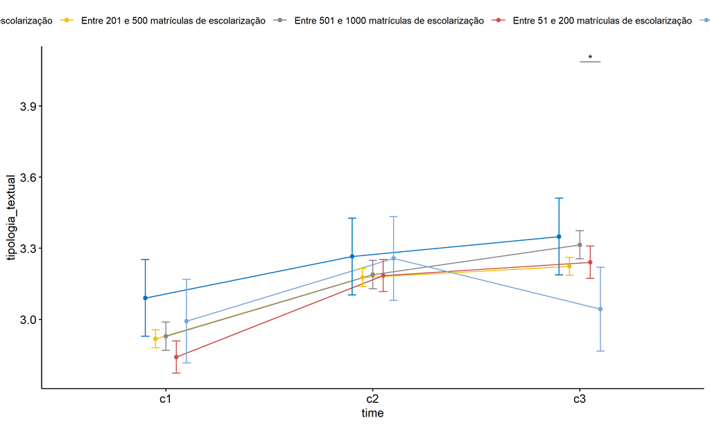

```r
pwc <- add_xy_position(pwc, x = "time", fun = "mean_se", dodge = 0.25)
pd <- position_dodge(width = 0.25)
ggline(emms, x = "time", y = "emmean", color = "porte",
       palette = c("#0073C2FF","#EFC000FF","#868686FF","#CD534CFF","#7AA6DCFF"),
       position = pd, ylab = "tipologia_textual") +
  geom_errorbar(aes(ymin = conf.low, ymax = conf.high, color = porte),
                position = pd, width = 0.2) +
  stat_pvalue_manual(pwc, hide.ns = T, tip.length = F, linetype = 1)
```

```r
(pwc <- ldat %>% group_by(porte) %>%
    emmeans_test(tipologia_textual ~ time, detailed = T, p.adjust.method = "bonferroni"))
```

```
## # A tibble: 15 × 15
##    porte  term  .y.   group1 group2 null.value estimate     se    df conf.low conf.high statistic        p    p.adj p.adj.signif
##  * <fct>  <chr> <chr> <chr>  <chr>       <dbl>    <dbl>  <dbl> <dbl>    <dbl>     <dbl>     <dbl>    <dbl>    <dbl> <chr>
##  1 Até 5… time  tipo… c1     c2              0  -0.175  0.117   8304  -0.404    0.0545     -1.49  1.35e- 1 4.05e- 1 ns
##  2 Até 5… time  tipo… c1     c3              0  -0.259  0.117   8304  -0.488   -0.0299     -2.22  2.67e- 2 8.02e- 2 ns
##  3 Até 5… time  tipo… c2     c3              0  -0.0843 0.117   8304  -0.313    0.145      -0.721 4.71e- 1 1   e+ 0 ns
##  4 Entre… time  tipo… c1     c2              0  -0.259  0.0272  8304  -0.312   -0.206      -9.51  2.52e-21 7.57e-21 ****
##  5 Entre… time  tipo… c1     c3              0  -0.306  0.0272  8304  -0.359   -0.253     -11.2   4.62e-29 1.39e-28 ****
##  6 Entre… time  tipo… c2     c3              0  -0.0470 0.0272  8304  -0.100    0.00641    -1.72  8.46e- 2 2.54e- 1 ns
##  7 Entre… time  tipo… c1     c2              0  -0.260  0.0428  8304  -0.344   -0.176      -6.07  1.35e- 9 4.05e- 9 ****
##  8 Entre… time  tipo… c1     c3              0  -0.386  0.0428  8304  -0.470   -0.302      -9.01  2.57e-19 7.71e-19 ****
##  9 Entre… time  tipo… c2     c3              0  -0.126  0.0428  8304  -0.210   -0.0420     -2.94  3.29e- 3 9.88e- 3 **
## 10 Entre… time  tipo… c1     c2              0  -0.343  0.0490  8304  -0.439   -0.247      -7.00  2.67e-12 8.01e-12 ****
## 11 Entre… time  tipo… c1     c3              0  -0.400  0.0490  8304  -0.496   -0.304      -8.16  3.86e-16 1.16e-15 ****
## 12 Entre… time  tipo… c2     c3              0  -0.0566 0.0490  8304  -0.153    0.0394     -1.15  2.48e- 1 7.45e- 1 ns
## 13 Mais … time  tipo… c1     c2              0  -0.264  0.127   8304  -0.514   -0.0148     -2.08  3.79e- 2 1.14e- 1 ns
## 14 Mais … time  tipo… c1     c3              0  -0.0500 0.127   8304  -0.300    0.200      -0.393 6.94e- 1 1   e+ 0 ns
## 15 Mais … time  tipo… c2     c3              0   0.214  0.127   8304  -0.0352   0.464       1.68  9.23e- 2 2.77e- 1 ns
```

| porte | term | .y. | group1 | group2 | null.value | estimate | se | df | conf.low | conf.high | statistic | p | p.adj | p.adj.signif |
| --- | --- | --- | --- | --- | --- | --- | --- | --- | --- | --- | --- | --- | --- | --- |
| Até 50 matrículas de escolarização | time | tipologia_textual | c1 | c2 | 0 | -0.175 | 0.117 | 8304 | -0.404 | 0.054 | -1.494 | 0.135 | 0.405 | ns |
| Até 50 matrículas de escolarização | time | tipologia_textual | c1 | c3 | 0 | -0.259 | 0.117 | 8304 | -0.488 | -0.030 | -2.216 | 0.027 | 0.080 | ns |
| Até 50 matrículas de escolarização | time | tipologia_textual | c2 | c3 | 0 | -0.084 | 0.117 | 8304 | -0.313 | 0.145 | -0.721 | 0.471 | 1.000 | ns |
| Entre 201 e 500 matrículas de escolarização | time | tipologia_textual | c1 | c2 | 0 | -0.259 | 0.027 | 8304 | -0.312 | -0.206 | -9.507 | 0.000 | 0.000 | **** |
| Entre 201 e 500 matrículas de escolarização | time | tipologia_textual | c1 | c3 | 0 | -0.306 | 0.027 | 8304 | -0.359 | -0.253 | -11.232 | 0.000 | 0.000 | **** |
| Entre 201 e 500 matrículas de escolarização | time | tipologia_textual | c2 | c3 | 0 | -0.047 | 0.027 | 8304 | -0.100 | 0.006 | -1.725 | 0.085 | 0.254 | ns |
| Entre 501 e 1000 matrículas de escolarização | time | tipologia_textual | c1 | c2 | 0 | -0.260 | 0.043 | 8304 | -0.344 | -0.176 | -6.068 | 0.000 | 0.000 | **** |
| Entre 501 e 1000 matrículas de escolarização | time | tipologia_textual | c1 | c3 | 0 | -0.386 | 0.043 | 8304 | -0.470 | -0.302 | -9.008 | 0.000 | 0.000 | **** |
| Entre 501 e 1000 matrículas de escolarização | time | tipologia_textual | c2 | c3 | 0 | -0.126 | 0.043 | 8304 | -0.210 | -0.042 | -2.940 | 0.003 | 0.010 | ** |
| Entre 51 e 200 matrículas de escolarização | time | tipologia_textual | c1 | c2 | 0 | -0.343 | 0.049 | 8304 | -0.439 | -0.247 | -7.005 | 0.000 | 0.000 | **** |
| Entre 51 e 200 matrículas de escolarização | time | tipologia_textual | c1 | c3 | 0 | -0.400 | 0.049 | 8304 | -0.496 | -0.304 | -8.160 | 0.000 | 0.000 | **** |
| Entre 51 e 200 matrículas de escolarização | time | tipologia_textual | c2 | c3 | 0 | -0.057 | 0.049 | 8304 | -0.153 | 0.039 | -1.155 | 0.248 | 0.745 | ns |
| Mais de 1000 matrículas de escolarização | time | tipologia_textual | c1 | c2 | 0 | -0.264 | 0.127 | 8304 | -0.514 | -0.015 | -2.076 | 0.038 | 0.114 | ns |
| Mais de 1000 matrículas de escolarização | time | tipologia_textual | c1 | c3 | 0 | -0.050 | 0.127 | 8304 | -0.300 | 0.200 | -0.393 | 0.694 | 1.000 | ns |
| Mais de 1000 matrículas de escolarização | time | tipologia_textual | c2 | c3 | 0 | 0.214 | 0.127 | 8304 | -0.035 | 0.464 | 1.683 | 0.092 | 0.277 | ns |

```r
(emms <- get_emmeans(pwc))
```

```
## # A tibble: 15 × 8
##    porte                                        time  emmean     se    df conf.low conf.high method
##    <fct>                                        <fct>  <dbl>  <dbl> <dbl>    <dbl>     <dbl> <chr>
##  1 Até 50 matrículas de escolarização           c1      3.09 0.0827  8304     2.93      3.25 Emmeans test
##  2 Até 50 matrículas de escolarização           c2      3.27 0.0827  8304     3.10      3.43 Emmeans test
##  3 Até 50 matrículas de escolarização           c3      3.35 0.0827  8304     3.19      3.51 Emmeans test
##  4 Entre 201 e 500 matrículas de escolarização  c1      2.92 0.0193  8304     2.88      2.96 Emmeans test
##  5 Entre 201 e 500 matrículas de escolarização  c2      3.18 0.0193  8304     3.14      3.21 Emmeans test
##  6 Entre 201 e 500 matrículas de escolarização  c3      3.22 0.0193  8304     3.19      3.26 Emmeans test
##  7 Entre 501 e 1000 matrículas de escolarização c1      2.93 0.0303  8304     2.87      2.99 Emmeans test
##  8 Entre 501 e 1000 matrículas de escolarização c2      3.19 0.0303  8304     3.13      3.25 Emmeans test
##  9 Entre 501 e 1000 matrículas de escolarização c3      3.31 0.0303  8304     3.26      3.37 Emmeans test
## 10 Entre 51 e 200 matrículas de escolarização   c1      2.84 0.0346  8304     2.77      2.91 Emmeans test
## 11 Entre 51 e 200 matrículas de escolarização   c2      3.18 0.0346  8304     3.12      3.25 Emmeans test
## 12 Entre 51 e 200 matrículas de escolarização   c3      3.24 0.0346  8304     3.17      3.31 Emmeans test
## 13 Mais de 1000 matrículas de escolarização     c1      2.99 0.0900  8304     2.82      3.17 Emmeans test
## 14 Mais de 1000 matrículas de escolarização     c2      3.26 0.0900  8304     3.08      3.43 Emmeans test
## 15 Mais de 1000 matrículas de escolarização     c3      3.04 0.0900  8304     2.87      3.22 Emmeans test
```

| porte | time | emmean | se | df | conf.low | conf.high | method |
| --- | --- | --- | --- | --- | --- | --- | --- |
| Até 50 matrículas de escolarização | c1 | 3.090 | 0.083 | 8304 | 2.928 | 3.252 | Emmeans test |
| Até 50 matrículas de escolarização | c2 | 3.265 | 0.083 | 8304 | 3.103 | 3.427 | Emmeans test |
| Até 50 matrículas de escolarização | c3 | 3.349 | 0.083 | 8304 | 3.187 | 3.511 | Emmeans test |
| Entre 201 e 500 matrículas de escolarização | c1 | 2.918 | 0.019 | 8304 | 2.880 | 2.956 | Emmeans test |
| Entre 201 e 500 matrículas de escolarização | c2 | 3.177 | 0.019 | 8304 | 3.139 | 3.215 | Emmeans test |
| Entre 201 e 500 matrículas de escolarização | c3 | 3.224 | 0.019 | 8304 | 3.186 | 3.262 | Emmeans test |
| Entre 501 e 1000 matrículas de escolarização | c1 | 2.929 | 0.030 | 8304 | 2.869 | 2.988 | Emmeans test |
| Entre 501 e 1000 matrículas de escolarização | c2 | 3.189 | 0.030 | 8304 | 3.129 | 3.248 | Emmeans test |
| Entre 501 e 1000 matrículas de escolarização | c3 | 3.315 | 0.030 | 8304 | 3.255 | 3.374 | Emmeans test |
| Entre 51 e 200 matrículas de escolarização | c1 | 2.841 | 0.035 | 8304 | 2.774 | 2.909 | Emmeans test |
| Entre 51 e 200 matrículas de escolarização | c2 | 3.184 | 0.035 | 8304 | 3.117 | 3.252 | Emmeans test |
| Entre 51 e 200 matrículas de escolarização | c3 | 3.241 | 0.035 | 8304 | 3.173 | 3.309 | Emmeans test |
| Mais de 1000 matrículas de escolarização | c1 | 2.993 | 0.090 | 8304 | 2.816 | 3.169 | Emmeans test |
| Mais de 1000 matrículas de escolarização | c2 | 3.257 | 0.090 | 8304 | 3.081 | 3.434 | Emmeans test |
| Mais de 1000 matrículas de escolarização | c3 | 3.043 | 0.090 | 8304 | 2.866 | 3.219 | Emmeans test |

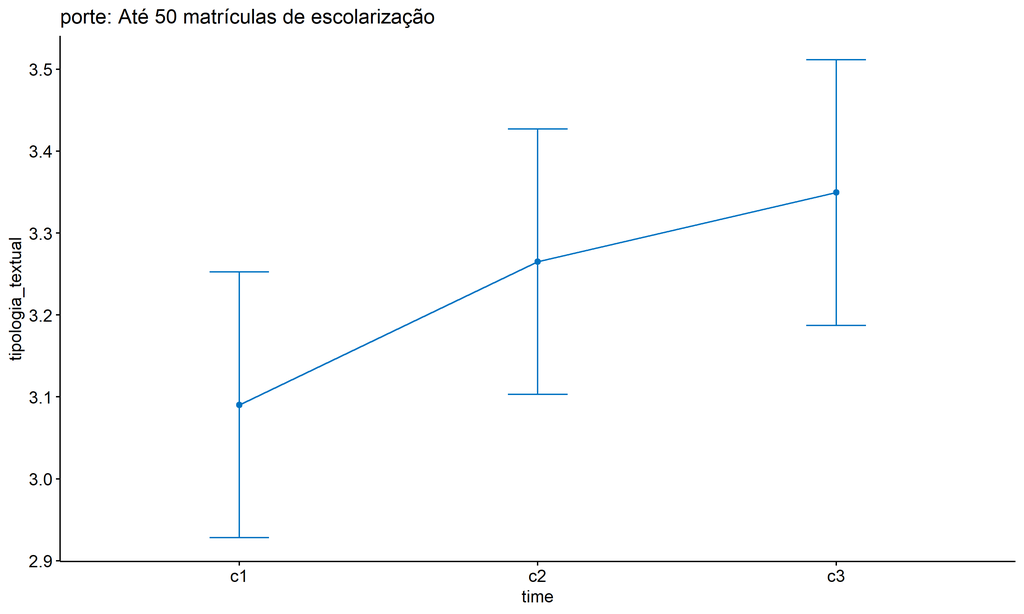

```r
emms.gg <- emms[which(emms$porte == "Até 50 matrículas de escolarização"),]
if (nrow(emms.gg) > 0)
  ggline(emms.gg, x = "time", y = "emmean", color = "#0073C2FF", ylab = "tipologia_textual") +
    geom_errorbar(aes(ymin = conf.low, ymax = conf.high),
                  width = 0.2, color = "#0073C2FF") +
    stat_pvalue_manual(
      add_xy_position(pwc[which(pwc$porte == "Até 50 matrículas de escolarização"),],
                      x = "time", fun = "mean_se"),
      hide.ns = T, color = "#0073C2FF", tip.length = F) +
    labs(title = "porte: Até 50 matrículas de escolarização")+
    theme(legend.text = element_blank())
```

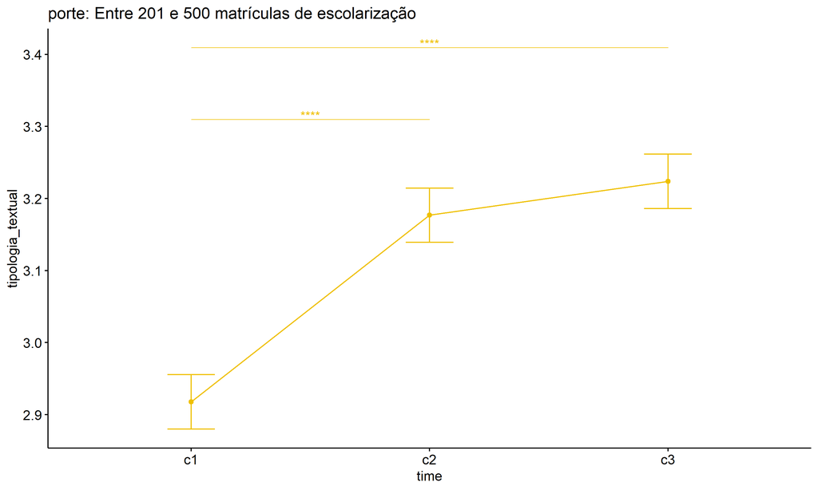

```r
emms.gg <- emms[which(emms$porte == "Entre 201 e 500 matrículas de escolarização"),]
if (nrow(emms.gg) > 0)
  ggline(emms.gg, x = "time", y = "emmean", color = "#EFC000FF", ylab = "tipologia_textual") +
    geom_errorbar(aes(ymin = conf.low, ymax = conf.high),
                  width = 0.2, color = "#EFC000FF") +
    stat_pvalue_manual(
      add_xy_position(pwc[which(pwc$porte == "Entre 201 e 500 matrículas de escolarização"),],
                      x = "time", fun = "mean_se"),
      hide.ns = T, color = "#EFC000FF", tip.length = F) +
    labs(title = "porte: Entre 201 e 500 matrículas de escolarização")+
    theme(legend.text = element_blank())
```

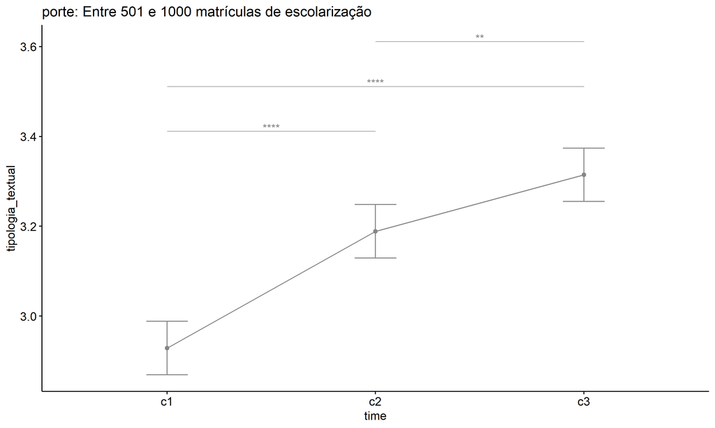

```r
emms.gg <- emms[which(emms$porte == "Entre 501 e 1000 matrículas de escolarização"),]
if (nrow(emms.gg) > 0)
  ggline(emms.gg, x = "time", y = "emmean", color = "#868686FF", ylab = "tipologia_textual") +
    geom_errorbar(aes(ymin = conf.low, ymax = conf.high),
                  width = 0.2, color = "#868686FF") +
    stat_pvalue_manual(
      add_xy_position(pwc[which(pwc$porte == "Entre 501 e 1000 matrículas de escolarização"),],
                      x = "time", fun = "mean_se"),
      hide.ns = T, color = "#868686FF", tip.length = F) +
    labs(title = "porte: Entre 501 e 1000 matrículas de escolarização")+
    theme(legend.text = element_blank())
```

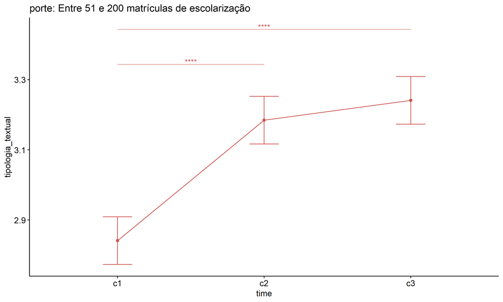

```r
emms.gg <- emms[which(emms$porte == "Entre 51 e 200 matrículas de escolarização"),]
if (nrow(emms.gg) > 0)
  ggline(emms.gg, x = "time", y = "emmean", color = "#CD534CFF", ylab = "tipologia_textual") +
    geom_errorbar(aes(ymin = conf.low, ymax = conf.high),
                  width = 0.2, color = "#CD534CFF") +
    stat_pvalue_manual(
      add_xy_position(pwc[which(pwc$porte == "Entre 51 e 200 matrículas de escolarização"),],
                      x = "time", fun = "mean_se"),
      hide.ns = T, color = "#CD534CFF", tip.length = F) +
    labs(title = "porte: Entre 51 e 200 matrículas de escolarização")+
    theme(legend.text = element_blank())
```

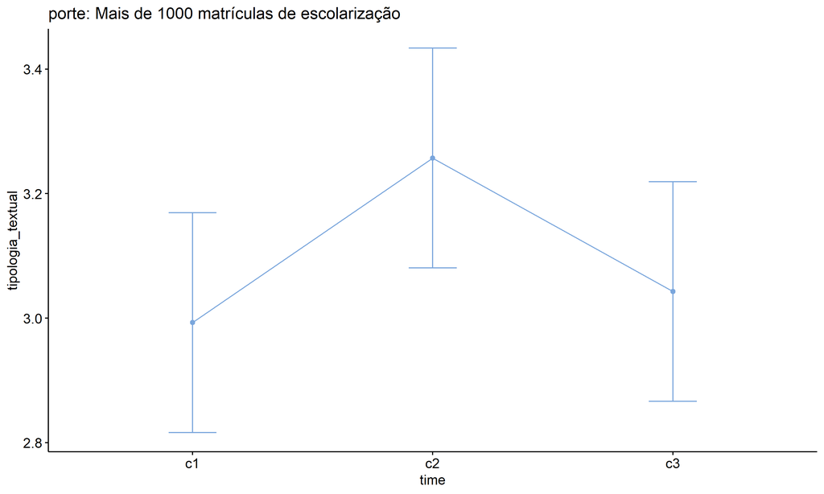

```r
emms.gg <- emms[which(emms$porte == "Mais de 1000 matrículas de escolarização"),]
if (nrow(emms.gg) > 0)
  ggline(emms.gg, x = "time", y = "emmean", color = "#7AA6DCFF", ylab = "tipologia_textual") +
    geom_errorbar(aes(ymin = conf.low, ymax = conf.high),
                  width = 0.2, color = "#7AA6DCFF") +
    stat_pvalue_manual(
      add_xy_position(pwc[which(pwc$porte == "Mais de 1000 matrículas de escolarização"),],
                      x = "time", fun = "mean_se"),
      hide.ns = T, color = "#7AA6DCFF", tip.length = F) +
    labs(title = "porte: Mais de 1000 matrículas de escolarização")+
    theme(legend.text = element_blank())
```

## PairWise Computation after removing non.normal data

```r
if (length(non.ids) > 0)
  (pwc2 <- ldat2 %>% group_by(time) %>%
     emmeans_test(tipologia_textual ~ porte, detailed = T, p.adjust.method = "bonferroni"))
```

```
## # A tibble: 30 × 15
##    time  term  .y.         group1 group2 null.value estimate     se    df conf.low conf.high statistic      p p.adj p.adj.signif
##  * <fct> <chr> <chr>       <chr>  <chr>       <dbl>    <dbl>  <dbl> <dbl>    <dbl>     <dbl>     <dbl>  <dbl> <dbl> <chr>
##  1 c1    porte tipologia_… Até 5… Entre…          0   0.170  0.120   7968 -6.59e-2    0.405     1.41   0.158  1     ns
##  2 c1    porte tipologia_… Até 5… Entre…          0   0.159  0.122   7968 -8.12e-2    0.399     1.30   0.195  1     ns
##  3 c1    porte tipologia_… Até 5… Entre…          0   0.246  0.124   7968  3.95e-3    0.488     1.99   0.0464 0.464 ns
##  4 c1    porte tipologia_… Até 5… Mais …          0   0.0875 0.759   7968 -1.40e+0    1.58      0.115  0.908  1     ns
##  5 c1    porte tipologia_… Entre… Entre…          0  -0.0109 0.0358  7968 -8.10e-2    0.0591   -0.306  0.760  1     ns
##  6 c1    porte tipologia_… Entre… Entre…          0   0.0764 0.0395  7968 -9.31e-4    0.154     1.94   0.0528 0.528 ns
##  7 c1    porte tipologia_… Entre… Mais …          0  -0.0821 0.750   7968 -1.55e+0    1.39     -0.109  0.913  1     ns
##  8 c1    porte tipologia_… Entre… Entre…          0   0.0874 0.0458  7968 -2.46e-3    0.177     1.91   0.0566 0.566 ns
##  9 c1    porte tipologia_… Entre… Mais …          0  -0.0712 0.751   7968 -1.54e+0    1.40     -0.0948 0.924  1     ns
## 10 c1    porte tipologia_… Entre… Mais …          0  -0.159  0.751   7968 -1.63e+0    1.31     -0.211  0.833  1     ns
## # ℹ 20 more rows
```

| time | term | .y. | group1 | group2 | null.value | estimate | se | df | conf.low | conf.high | statistic | p | p.adj | p.adj.signif |
| --- | --- | --- | --- | --- | --- | --- | --- | --- | --- | --- | --- | --- | --- | --- |
| c1 | porte | tipologia_textual | Até 50 matrículas de escolarização | Entre 201 e 500 matrículas de escolarização | 0 | 0.170 | 0.120 | 7968 | -0.066 | 0.405 | 1.412 | 0.158 | 1.000 | ns |
| c1 | porte | tipologia_textual | Até 50 matrículas de escolarização | Entre 501 e 1000 matrículas de escolarização | 0 | 0.159 | 0.122 | 7968 | -0.081 | 0.399 | 1.297 | 0.195 | 1.000 | ns |
| c1 | porte | tipologia_textual | Até 50 matrículas de escolarização | Entre 51 e 200 matrículas de escolarização | 0 | 0.246 | 0.124 | 7968 | 0.004 | 0.488 | 1.992 | 0.046 | 0.464 | ns |
| c1 | porte | tipologia_textual | Até 50 matrículas de escolarização | Mais de 1000 matrículas de escolarização | 0 | 0.088 | 0.759 | 7968 | -1.401 | 1.576 | 0.115 | 0.908 | 1.000 | ns |
| c1 | porte | tipologia_textual | Entre 201 e 500 matrículas de escolarização | Entre 501 e 1000 matrículas de escolarização | 0 | -0.011 | 0.036 | 7968 | -0.081 | 0.059 | -0.306 | 0.760 | 1.000 | ns |
| c1 | porte | tipologia_textual | Entre 201 e 500 matrículas de escolarização | Entre 51 e 200 matrículas de escolarização | 0 | 0.076 | 0.039 | 7968 | -0.001 | 0.154 | 1.937 | 0.053 | 0.528 | ns |
| c1 | porte | tipologia_textual | Entre 201 e 500 matrículas de escolarização | Mais de 1000 matrículas de escolarização | 0 | -0.082 | 0.750 | 7968 | -1.553 | 1.389 | -0.109 | 0.913 | 1.000 | ns |
| c1 | porte | tipologia_textual | Entre 501 e 1000 matrículas de escolarização | Entre 51 e 200 matrículas de escolarização | 0 | 0.087 | 0.046 | 7968 | -0.002 | 0.177 | 1.907 | 0.057 | 0.566 | ns |
| c1 | porte | tipologia_textual | Entre 501 e 1000 matrículas de escolarização | Mais de 1000 matrículas de escolarização | 0 | -0.071 | 0.751 | 7968 | -1.543 | 1.400 | -0.095 | 0.924 | 1.000 | ns |
| c1 | porte | tipologia_textual | Entre 51 e 200 matrículas de escolarização | Mais de 1000 matrículas de escolarização | 0 | -0.159 | 0.751 | 7968 | -1.630 | 1.313 | -0.211 | 0.833 | 1.000 | ns |
| c2 | porte | tipologia_textual | Até 50 matrículas de escolarização | Entre 201 e 500 matrículas de escolarização | 0 | -0.027 | 0.120 | 7968 | -0.262 | 0.209 | -0.223 | 0.823 | 1.000 | ns |
| c2 | porte | tipologia_textual | Até 50 matrículas de escolarização | Entre 501 e 1000 matrículas de escolarização | 0 | -0.039 | 0.122 | 7968 | -0.279 | 0.201 | -0.317 | 0.751 | 1.000 | ns |
| c2 | porte | tipologia_textual | Até 50 matrículas de escolarização | Entre 51 e 200 matrículas de escolarização | 0 | -0.034 | 0.124 | 7968 | -0.277 | 0.208 | -0.279 | 0.780 | 1.000 | ns |
| c2 | porte | tipologia_textual | Até 50 matrículas de escolarização | Mais de 1000 matrículas de escolarização | 0 | -0.850 | 0.759 | 7968 | -2.339 | 0.639 | -1.119 | 0.263 | 1.000 | ns |
| c2 | porte | tipologia_textual | Entre 201 e 500 matrículas de escolarização | Entre 501 e 1000 matrículas de escolarização | 0 | -0.012 | 0.036 | 7968 | -0.082 | 0.058 | -0.335 | 0.738 | 1.000 | ns |
| c2 | porte | tipologia_textual | Entre 201 e 500 matrículas de escolarização | Entre 51 e 200 matrículas de escolarização | 0 | -0.008 | 0.039 | 7968 | -0.085 | 0.070 | -0.194 | 0.846 | 1.000 | ns |
| c2 | porte | tipologia_textual | Entre 201 e 500 matrículas de escolarização | Mais de 1000 matrículas de escolarização | 0 | -0.823 | 0.750 | 7968 | -2.294 | 0.648 | -1.097 | 0.273 | 1.000 | ns |
| c2 | porte | tipologia_textual | Entre 501 e 1000 matrículas de escolarização | Entre 51 e 200 matrículas de escolarização | 0 | 0.004 | 0.046 | 7968 | -0.086 | 0.094 | 0.094 | 0.925 | 1.000 | ns |
| c2 | porte | tipologia_textual | Entre 501 e 1000 matrículas de escolarização | Mais de 1000 matrículas de escolarização | 0 | -0.811 | 0.751 | 7968 | -2.283 | 0.660 | -1.081 | 0.280 | 1.000 | ns |
| c2 | porte | tipologia_textual | Entre 51 e 200 matrículas de escolarização | Mais de 1000 matrículas de escolarização | 0 | -0.816 | 0.751 | 7968 | -2.287 | 0.656 | -1.086 | 0.277 | 1.000 | ns |
| c3 | porte | tipologia_textual | Até 50 matrículas de escolarização | Entre 201 e 500 matrículas de escolarização | 0 | -0.061 | 0.120 | 7968 | -0.297 | 0.174 | -0.510 | 0.610 | 1.000 | ns |
| c3 | porte | tipologia_textual | Até 50 matrículas de escolarização | Entre 501 e 1000 matrículas de escolarização | 0 | -0.152 | 0.122 | 7968 | -0.392 | 0.088 | -1.244 | 0.214 | 1.000 | ns |
| c3 | porte | tipologia_textual | Até 50 matrículas de escolarização | Entre 51 e 200 matrículas de escolarização | 0 | -0.079 | 0.124 | 7968 | -0.321 | 0.164 | -0.636 | 0.525 | 1.000 | ns |
| c3 | porte | tipologia_textual | Até 50 matrículas de escolarização | Mais de 1000 matrículas de escolarização | 0 | -0.838 | 0.759 | 7968 | -2.326 | 0.651 | -1.103 | 0.270 | 1.000 | ns |
| c3 | porte | tipologia_textual | Entre 201 e 500 matrículas de escolarização | Entre 501 e 1000 matrículas de escolarização | 0 | -0.091 | 0.036 | 7968 | -0.161 | -0.021 | -2.544 | 0.011 | 0.110 | ns |
| c3 | porte | tipologia_textual | Entre 201 e 500 matrículas de escolarização | Entre 51 e 200 matrículas de escolarização | 0 | -0.017 | 0.039 | 7968 | -0.095 | 0.060 | -0.437 | 0.662 | 1.000 | ns |
| c3 | porte | tipologia_textual | Entre 201 e 500 matrículas de escolarização | Mais de 1000 matrículas de escolarização | 0 | -0.776 | 0.750 | 7968 | -2.247 | 0.695 | -1.035 | 0.301 | 1.000 | ns |
| c3 | porte | tipologia_textual | Entre 501 e 1000 matrículas de escolarização | Entre 51 e 200 matrículas de escolarização | 0 | 0.074 | 0.046 | 7968 | -0.016 | 0.164 | 1.609 | 0.108 | 1.000 | ns |
| c3 | porte | tipologia_textual | Entre 501 e 1000 matrículas de escolarização | Mais de 1000 matrículas de escolarização | 0 | -0.685 | 0.751 | 7968 | -2.157 | 0.786 | -0.913 | 0.361 | 1.000 | ns |
| c3 | porte | tipologia_textual | Entre 51 e 200 matrículas de escolarização | Mais de 1000 matrículas de escolarização | 0 | -0.759 | 0.751 | 7968 | -2.231 | 0.713 | -1.011 | 0.312 | 1.000 | ns |

```r
if (length(non.ids) > 0)
  (emms2 <- get_emmeans(pwc2))
```

```
## # A tibble: 15 × 8
##    time  porte                                        emmean     se    df conf.low conf.high method
##    <fct> <fct>                                         <dbl>  <dbl> <dbl>    <dbl>     <dbl> <chr>
##  1 c1    Até 50 matrículas de escolarização             3.09 0.119   7968     2.86      3.32 Emmeans test
##  2 c1    Entre 201 e 500 matrículas de escolarização    2.92 0.0192  7968     2.88      2.96 Emmeans test
##  3 c1    Entre 501 e 1000 matrículas de escolarização   2.93 0.0302  7968     2.87      2.99 Emmeans test
##  4 c1    Entre 51 e 200 matrículas de escolarização     2.84 0.0345  7968     2.77      2.91 Emmeans test
##  5 c1    Mais de 1000 matrículas de escolarização       3.00 0.750   7968     1.53      4.47 Emmeans test
##  6 c2    Até 50 matrículas de escolarização             3.15 0.119   7968     2.92      3.38 Emmeans test
##  7 c2    Entre 201 e 500 matrículas de escolarização    3.18 0.0192  7968     3.14      3.21 Emmeans test
##  8 c2    Entre 501 e 1000 matrículas de escolarização   3.19 0.0302  7968     3.13      3.25 Emmeans test
##  9 c2    Entre 51 e 200 matrículas de escolarização     3.18 0.0345  7968     3.12      3.25 Emmeans test
## 10 c2    Mais de 1000 matrículas de escolarização       4.00 0.750   7968     2.53      5.47 Emmeans test
## 11 c3    Até 50 matrículas de escolarização             3.16 0.119   7968     2.93      3.39 Emmeans test
## 12 c3    Entre 201 e 500 matrículas de escolarização    3.22 0.0192  7968     3.19      3.26 Emmeans test
## 13 c3    Entre 501 e 1000 matrículas de escolarização   3.31 0.0302  7968     3.26      3.37 Emmeans test
## 14 c3    Entre 51 e 200 matrículas de escolarização     3.24 0.0345  7968     3.17      3.31 Emmeans test
## 15 c3    Mais de 1000 matrículas de escolarização       4.00 0.750   7968     2.53      5.47 Emmeans test
```

| time | porte | emmean | se | df | conf.low | conf.high | method |
| --- | --- | --- | --- | --- | --- | --- | --- |
| c1 | Até 50 matrículas de escolarização | 3.088 | 0.119 | 7968 | 2.855 | 3.320 | Emmeans test |
| c1 | Entre 201 e 500 matrículas de escolarização | 2.918 | 0.019 | 7968 | 2.880 | 2.955 | Emmeans test |
| c1 | Entre 501 e 1000 matrículas de escolarização | 2.929 | 0.030 | 7968 | 2.870 | 2.988 | Emmeans test |
| c1 | Entre 51 e 200 matrículas de escolarização | 2.841 | 0.034 | 7968 | 2.774 | 2.909 | Emmeans test |
| c1 | Mais de 1000 matrículas de escolarização | 3.000 | 0.750 | 7968 | 1.530 | 4.470 | Emmeans test |
| c2 | Até 50 matrículas de escolarização | 3.150 | 0.119 | 7968 | 2.918 | 3.382 | Emmeans test |
| c2 | Entre 201 e 500 matrículas de escolarização | 3.177 | 0.019 | 7968 | 3.139 | 3.214 | Emmeans test |
| c2 | Entre 501 e 1000 matrículas de escolarização | 3.189 | 0.030 | 7968 | 3.130 | 3.248 | Emmeans test |
| c2 | Entre 51 e 200 matrículas de escolarização | 3.184 | 0.034 | 7968 | 3.117 | 3.252 | Emmeans test |
| c2 | Mais de 1000 matrículas de escolarização | 4.000 | 0.750 | 7968 | 2.530 | 5.470 | Emmeans test |
| c3 | Até 50 matrículas de escolarização | 3.163 | 0.119 | 7968 | 2.930 | 3.395 | Emmeans test |
| c3 | Entre 201 e 500 matrículas de escolarização | 3.224 | 0.019 | 7968 | 3.186 | 3.261 | Emmeans test |
| c3 | Entre 501 e 1000 matrículas de escolarização | 3.315 | 0.030 | 7968 | 3.256 | 3.374 | Emmeans test |
| c3 | Entre 51 e 200 matrículas de escolarização | 3.241 | 0.034 | 7968 | 3.173 | 3.309 | Emmeans test |
| c3 | Mais de 1000 matrículas de escolarização | 4.000 | 0.750 | 7968 | 2.530 | 5.470 | Emmeans test |

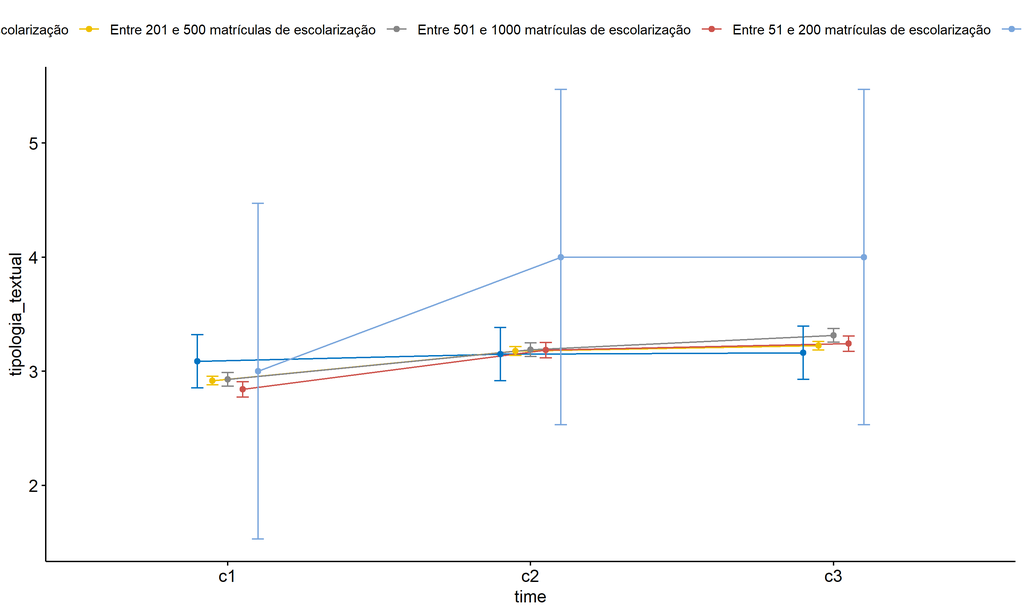

```r
if (length(non.ids) > 0) {
  pwc2 <- add_xy_position(pwc2, x = "time", fun = "mean_se", dodge = 0.25)
  pd2 <- position_dodge(width = 0.25)

  ggline(emms2, x = "time", y = "emmean", color = "porte",
         palette = c("#0073C2FF","#EFC000FF","#868686FF","#CD534CFF","#7AA6DCFF"),
         position = pd, ylab = "tipologia_textual") +
    geom_errorbar(aes(ymin = conf.low, ymax = conf.high, color = porte),
                position = pd, width = 0.2) +
    stat_pvalue_manual(pwc2, hide.ns = T, tip.length = F, linetype = 1)
}
```

```r
if (length(non.ids) > 0)
  (pwc2 <- ldat2 %>% group_by(porte) %>%
     emmeans_test(tipologia_textual ~ time, detailed = T, p.adjust.method = "bonferroni"))
```

```
## # A tibble: 15 × 15
##    porte term  .y.   group1 group2 null.value  estimate     se    df conf.low conf.high statistic        p    p.adj p.adj.signif
##  * <fct> <chr> <chr> <chr>  <chr>       <dbl>     <dbl>  <dbl> <dbl>    <dbl>     <dbl>     <dbl>    <dbl>    <dbl> <chr>
##  1 Até … time  tipo… c1     c2              0 -6.25e- 2 0.168   7968   -0.391   0.266   -3.73e- 1 7.09e- 1 1   e+ 0 ns
##  2 Até … time  tipo… c1     c3              0 -7.50e- 2 0.168   7968   -0.404   0.254   -4.47e- 1 6.55e- 1 1   e+ 0 ns
##  3 Até … time  tipo… c2     c3              0 -1.25e- 2 0.168   7968   -0.341   0.316   -7.45e- 2 9.41e- 1 1   e+ 0 ns
##  4 Entr… time  tipo… c1     c2              0 -2.59e- 1 0.0271  7968   -0.312  -0.206   -9.55e+ 0 1.77e-21 5.31e-21 ****
##  5 Entr… time  tipo… c1     c3              0 -3.06e- 1 0.0271  7968   -0.359  -0.253   -1.13e+ 1 2.84e-29 8.52e-29 ****
##  6 Entr… time  tipo… c2     c3              0 -4.70e- 2 0.0271  7968   -0.100   0.00620 -1.73e+ 0 8.33e- 2 2.50e- 1 ns
##  7 Entr… time  tipo… c1     c2              0 -2.60e- 1 0.0427  7968   -0.344  -0.176   -6.09e+ 0 1.16e- 9 3.48e- 9 ****
##  8 Entr… time  tipo… c1     c3              0 -3.86e- 1 0.0427  7968   -0.470  -0.302   -9.04e+ 0 1.86e-19 5.59e-19 ****
##  9 Entr… time  tipo… c2     c3              0 -1.26e- 1 0.0427  7968   -0.210  -0.0423  -2.95e+ 0 3.17e- 3 9.51e- 3 **
## 10 Entr… time  tipo… c1     c2              0 -3.43e- 1 0.0488  7968   -0.439  -0.247   -7.03e+ 0 2.19e-12 6.57e-12 ****
## 11 Entr… time  tipo… c1     c3              0 -4.00e- 1 0.0488  7968   -0.495  -0.304   -8.19e+ 0 2.96e-16 8.87e-16 ****
## 12 Entr… time  tipo… c2     c3              0 -5.66e- 2 0.0488  7968   -0.152   0.0391  -1.16e+ 0 2.46e- 1 7.39e- 1 ns
## 13 Mais… time  tipo… c1     c2              0 -1.00e+ 0 1.06    7968   -3.08    1.08    -9.43e- 1 3.46e- 1 1   e+ 0 ns
## 14 Mais… time  tipo… c1     c3              0 -1.00e+ 0 1.06    7968   -3.08    1.08    -9.43e- 1 3.46e- 1 1   e+ 0 ns
## 15 Mais… time  tipo… c2     c3              0  1.43e-13 1.06    7968   -2.08    2.08     1.35e-13 1.00e+ 0 1   e+ 0 ns
```

| porte | term | .y. | group1 | group2 | null.value | estimate | se | df | conf.low | conf.high | statistic | p | p.adj | p.adj.signif |
| --- | --- | --- | --- | --- | --- | --- | --- | --- | --- | --- | --- | --- | --- | --- |
| Até 50 matrículas de escolarização | time | tipologia_textual | c1 | c2 | 0 | -0.063 | 0.168 | 7968 | -0.391 | 0.266 | -0.373 | 0.709 | 1.000 | ns |
| Até 50 matrículas de escolarização | time | tipologia_textual | c1 | c3 | 0 | -0.075 | 0.168 | 7968 | -0.404 | 0.254 | -0.447 | 0.655 | 1.000 | ns |
| Até 50 matrículas de escolarização | time | tipologia_textual | c2 | c3 | 0 | -0.013 | 0.168 | 7968 | -0.341 | 0.316 | -0.075 | 0.941 | 1.000 | ns |
| Entre 201 e 500 matrículas de escolarização | time | tipologia_textual | c1 | c2 | 0 | -0.259 | 0.027 | 7968 | -0.312 | -0.206 | -9.545 | 0.000 | 0.000 | **** |
| Entre 201 e 500 matrículas de escolarização | time | tipologia_textual | c1 | c3 | 0 | -0.306 | 0.027 | 7968 | -0.359 | -0.253 | -11.277 | 0.000 | 0.000 | **** |
| Entre 201 e 500 matrículas de escolarização | time | tipologia_textual | c2 | c3 | 0 | -0.047 | 0.027 | 7968 | -0.100 | 0.006 | -1.732 | 0.083 | 0.250 | ns |
| Entre 501 e 1000 matrículas de escolarização | time | tipologia_textual | c1 | c2 | 0 | -0.260 | 0.043 | 7968 | -0.344 | -0.176 | -6.093 | 0.000 | 0.000 | **** |
| Entre 501 e 1000 matrículas de escolarização | time | tipologia_textual | c1 | c3 | 0 | -0.386 | 0.043 | 7968 | -0.470 | -0.302 | -9.044 | 0.000 | 0.000 | **** |
| Entre 501 e 1000 matrículas de escolarização | time | tipologia_textual | c2 | c3 | 0 | -0.126 | 0.043 | 7968 | -0.210 | -0.042 | -2.952 | 0.003 | 0.010 | ** |
| Entre 51 e 200 matrículas de escolarização | time | tipologia_textual | c1 | c2 | 0 | -0.343 | 0.049 | 7968 | -0.439 | -0.247 | -7.033 | 0.000 | 0.000 | **** |
| Entre 51 e 200 matrículas de escolarização | time | tipologia_textual | c1 | c3 | 0 | -0.400 | 0.049 | 7968 | -0.495 | -0.304 | -8.192 | 0.000 | 0.000 | **** |
| Entre 51 e 200 matrículas de escolarização | time | tipologia_textual | c2 | c3 | 0 | -0.057 | 0.049 | 7968 | -0.152 | 0.039 | -1.160 | 0.246 | 0.739 | ns |
| Mais de 1000 matrículas de escolarização | time | tipologia_textual | c1 | c2 | 0 | -1.000 | 1.061 | 7968 | -3.079 | 1.079 | -0.943 | 0.346 | 1.000 | ns |
| Mais de 1000 matrículas de escolarização | time | tipologia_textual | c1 | c3 | 0 | -1.000 | 1.061 | 7968 | -3.079 | 1.079 | -0.943 | 0.346 | 1.000 | ns |
| Mais de 1000 matrículas de escolarização | time | tipologia_textual | c2 | c3 | 0 | 0.000 | 1.061 | 7968 | -2.079 | 2.079 | 0.000 | 1.000 | 1.000 | ns |

```r
if (length(non.ids) > 0)
  (emms2 <- get_emmeans(pwc2))
```

```
## # A tibble: 15 × 8
##    porte                                        time  emmean     se    df conf.low conf.high method
##    <fct>                                        <fct>  <dbl>  <dbl> <dbl>    <dbl>     <dbl> <chr>
##  1 Até 50 matrículas de escolarização           c1      3.09 0.119   7968     2.86      3.32 Emmeans test
##  2 Até 50 matrículas de escolarização           c2      3.15 0.119   7968     2.92      3.38 Emmeans test
##  3 Até 50 matrículas de escolarização           c3      3.16 0.119   7968     2.93      3.39 Emmeans test
##  4 Entre 201 e 500 matrículas de escolarização  c1      2.92 0.0192  7968     2.88      2.96 Emmeans test
##  5 Entre 201 e 500 matrículas de escolarização  c2      3.18 0.0192  7968     3.14      3.21 Emmeans test
##  6 Entre 201 e 500 matrículas de escolarização  c3      3.22 0.0192  7968     3.19      3.26 Emmeans test
##  7 Entre 501 e 1000 matrículas de escolarização c1      2.93 0.0302  7968     2.87      2.99 Emmeans test
##  8 Entre 501 e 1000 matrículas de escolarização c2      3.19 0.0302  7968     3.13      3.25 Emmeans test
##  9 Entre 501 e 1000 matrículas de escolarização c3      3.31 0.0302  7968     3.26      3.37 Emmeans test
## 10 Entre 51 e 200 matrículas de escolarização   c1      2.84 0.0345  7968     2.77      2.91 Emmeans test
## 11 Entre 51 e 200 matrículas de escolarização   c2      3.18 0.0345  7968     3.12      3.25 Emmeans test
## 12 Entre 51 e 200 matrículas de escolarização   c3      3.24 0.0345  7968     3.17      3.31 Emmeans test
## 13 Mais de 1000 matrículas de escolarização     c1      3.00 0.750   7968     1.53      4.47 Emmeans test
## 14 Mais de 1000 matrículas de escolarização     c2      4.00 0.750   7968     2.53      5.47 Emmeans test
## 15 Mais de 1000 matrículas de escolarização     c3      4.00 0.750   7968     2.53      5.47 Emmeans test
```

| porte | time | emmean | se | df | conf.low | conf.high | method |
| --- | --- | --- | --- | --- | --- | --- | --- |
| Até 50 matrículas de escolarização | c1 | 3.087 | 0.119 | 7968 | 2.855 | 3.320 | Emmeans test |
| Até 50 matrículas de escolarização | c2 | 3.150 | 0.119 | 7968 | 2.918 | 3.382 | Emmeans test |
| Até 50 matrículas de escolarização | c3 | 3.163 | 0.119 | 7968 | 2.930 | 3.395 | Emmeans test |
| Entre 201 e 500 matrículas de escolarização | c1 | 2.918 | 0.019 | 7968 | 2.880 | 2.955 | Emmeans test |
| Entre 201 e 500 matrículas de escolarização | c2 | 3.177 | 0.019 | 7968 | 3.139 | 3.214 | Emmeans test |
| Entre 201 e 500 matrículas de escolarização | c3 | 3.224 | 0.019 | 7968 | 3.186 | 3.261 | Emmeans test |
| Entre 501 e 1000 matrículas de escolarização | c1 | 2.929 | 0.030 | 7968 | 2.870 | 2.988 | Emmeans test |
| Entre 501 e 1000 matrículas de escolarização | c2 | 3.189 | 0.030 | 7968 | 3.130 | 3.248 | Emmeans test |
| Entre 501 e 1000 matrículas de escolarização | c3 | 3.315 | 0.030 | 7968 | 3.256 | 3.374 | Emmeans test |
| Entre 51 e 200 matrículas de escolarização | c1 | 2.841 | 0.034 | 7968 | 2.774 | 2.909 | Emmeans test |
| Entre 51 e 200 matrículas de escolarização | c2 | 3.184 | 0.034 | 7968 | 3.117 | 3.252 | Emmeans test |
| Entre 51 e 200 matrículas de escolarização | c3 | 3.241 | 0.034 | 7968 | 3.173 | 3.309 | Emmeans test |
| Mais de 1000 matrículas de escolarização | c1 | 3.000 | 0.750 | 7968 | 1.530 | 4.470 | Emmeans test |
| Mais de 1000 matrículas de escolarização | c2 | 4.000 | 0.750 | 7968 | 2.530 | 5.470 | Emmeans test |
| Mais de 1000 matrículas de escolarização | c3 | 4.000 | 0.750 | 7968 | 2.530 | 5.470 | Emmeans test |

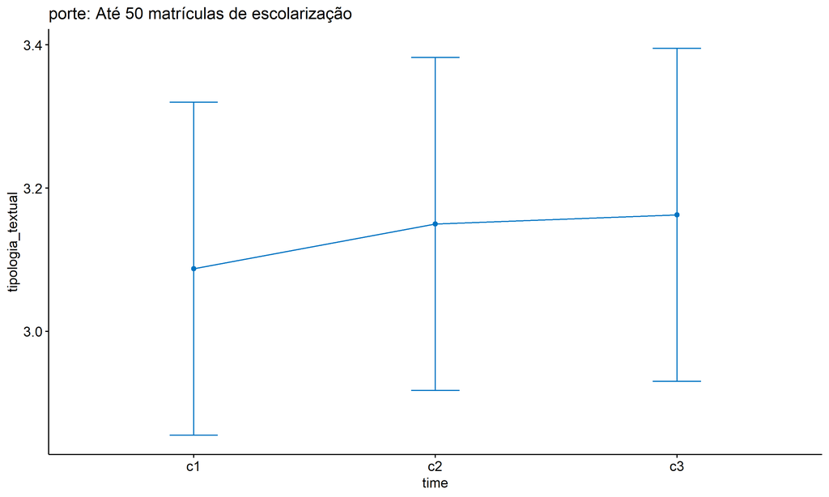

```r
if (length(non.ids) > 0) {
  emms.gg <- emms2[which(emms2$porte == "Até 50 matrículas de escolarização"),]
  if (nrow(emms.gg) > 0)
    ggline(emms.gg, x = "time", y = "emmean", color = "#0073C2FF", ylab = "tipologia_textual") +
    geom_errorbar(aes(ymin = conf.low, ymax = conf.high),
                  width = 0.2, color = "#0073C2FF") +
    stat_pvalue_manual(
      add_xy_position(pwc[which(pwc$porte == "Até 50 matrículas de escolarização"),],
                      x = "time", fun = "mean_se"),
      hide.ns = T, color = "#0073C2FF", tip.length = F) +
    labs(title = "porte: Até 50 matrículas de escolarização") +
    theme(legend.text = element_blank())
}
```

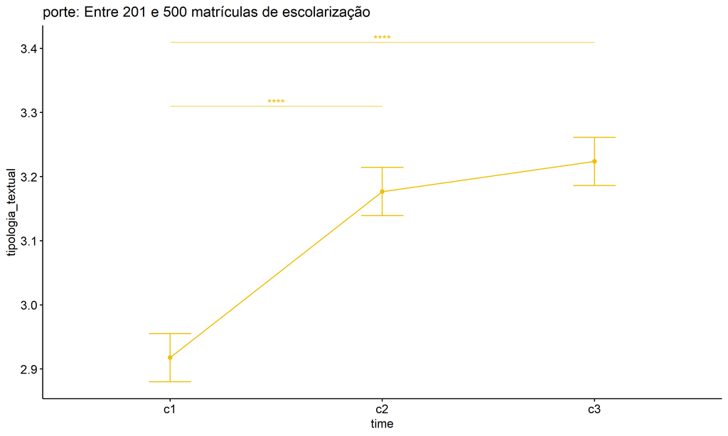

```r
if (length(non.ids) > 0) {
  emms.gg <- emms2[which(emms2$porte == "Entre 201 e 500 matrículas de escolarização"),]
  if (nrow(emms.gg) > 0)
    ggline(emms.gg, x = "time", y = "emmean", color = "#EFC000FF", ylab = "tipologia_textual") +
    geom_errorbar(aes(ymin = conf.low, ymax = conf.high),
                  width = 0.2, color = "#EFC000FF") +
    stat_pvalue_manual(
      add_xy_position(pwc[which(pwc$porte == "Entre 201 e 500 matrículas de escolarização"),],
                      x = "time", fun = "mean_se"),
      hide.ns = T, color = "#EFC000FF", tip.length = F) +
    labs(title = "porte: Entre 201 e 500 matrículas de escolarização") +
    theme(legend.text = element_blank())
}
```

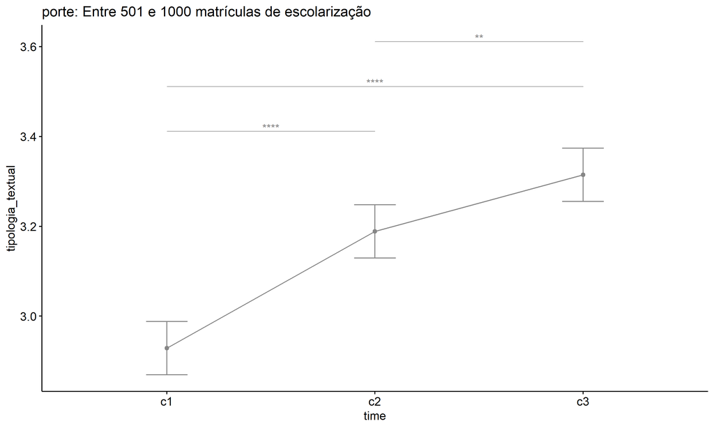

```r
if (length(non.ids) > 0) {
  emms.gg <- emms2[which(emms2$porte == "Entre 501 e 1000 matrículas de escolarização"),]
  if (nrow(emms.gg) > 0)
    ggline(emms.gg, x = "time", y = "emmean", color = "#868686FF", ylab = "tipologia_textual") +
    geom_errorbar(aes(ymin = conf.low, ymax = conf.high),
                  width = 0.2, color = "#868686FF") +
    stat_pvalue_manual(
      add_xy_position(pwc[which(pwc$porte == "Entre 501 e 1000 matrículas de escolarização"),],
                      x = "time", fun = "mean_se"),
      hide.ns = T, color = "#868686FF", tip.length = F) +
    labs(title = "porte: Entre 501 e 1000 matrículas de escolarização") +
    theme(legend.text = element_blank())
}
```

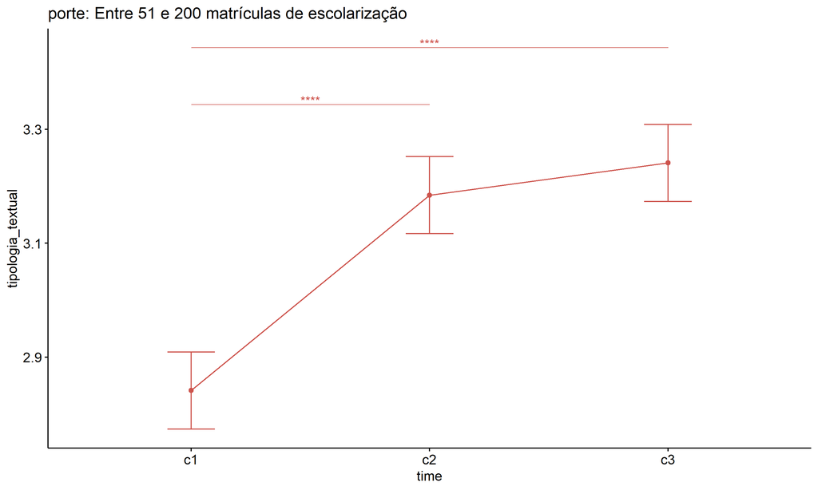

```r
if (length(non.ids) > 0) {
  emms.gg <- emms2[which(emms2$porte == "Entre 51 e 200 matrículas de escolarização"),]
  if (nrow(emms.gg) > 0)
    ggline(emms.gg, x = "time", y = "emmean", color = "#CD534CFF", ylab = "tipologia_textual") +
    geom_errorbar(aes(ymin = conf.low, ymax = conf.high),
                  width = 0.2, color = "#CD534CFF") +
    stat_pvalue_manual(
      add_xy_position(pwc[which(pwc$porte == "Entre 51 e 200 matrículas de escolarização"),],
                      x = "time", fun = "mean_se"),
      hide.ns = T, color = "#CD534CFF", tip.length = F) +
    labs(title = "porte: Entre 51 e 200 matrículas de escolarização") +
    theme(legend.text = element_blank())
}
```

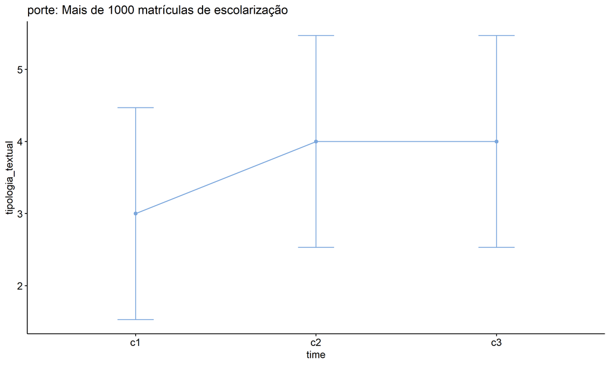

```r
if (length(non.ids) > 0) {
  emms.gg <- emms2[which(emms2$porte == "Mais de 1000 matrículas de escolarização"),]
  if (nrow(emms.gg) > 0)
    ggline(emms.gg, x = "time", y = "emmean", color = "#7AA6DCFF", ylab = "tipologia_textual") +
    geom_errorbar(aes(ymin = conf.low, ymax = conf.high),
                  width = 0.2, color = "#7AA6DCFF") +
    stat_pvalue_manual(
      add_xy_position(pwc[which(pwc$porte == "Mais de 1000 matrículas de escolarização"),],
                      x = "time", fun = "mean_se"),
      hide.ns = T, color = "#7AA6DCFF", tip.length = F) +
    labs(title = "porte: Mais de 1000 matrículas de escolarização") +
    theme(legend.text = element_blank())
}
```